# 阿斯伯格综合征完全指南

Tony Attwood

[figure not shown]

[figure not shown]

# 版权信息

书名：阿斯伯格综合征完全指南

作者：托尼·阿特伍德

译者：燕原,冯斌

出版社：华夏出版社

出版时间：2012-08-01

ISBN：9787508070414

品牌方：华夏出版社有限公司

本书由华夏出版社有限公司授权微信读书进行制作与发行

版权所有 · 侵权必究

# 作者简介

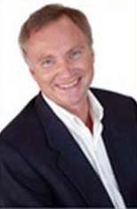

托尼·阿特伍德博士（Dr.Tony Attwood），1952年出生，英国心理学家，世界知名的阿斯伯格综合征研究专家，有三十多年的阿斯伯格综合征研究、临床诊断和咨询的经验，已诊断和治疗了几千名各种年龄的阿斯伯格综合征人士。托尼著有多部与阿斯伯格综合征相关的图书，其中〈阿斯伯格综合征完全指南〉已翻译成多种语言，在世界各地畅销。

托尼博士现居住在澳大利亚，从事临床心理学研究。他与大量阿斯伯格综合征成人保持着长期联系，在世界各地为阿斯伯格综合征人士、家长以及专业人士举办各种讲座和学习班。

托尼博士的个人网站是www.tonyattwood.com.au，他与同事在澳大利亚布里斯班的诊所的网址是www.mindsandhearts.net。

# 纪念词

纪念我的祖母埃尔茜·梅·多维（1903–1987）

和我的祖父威廉姆·霍华德·多维（1905–2000）

# 致谢

感谢所有给予我鼓励、建议和支持的人。没有你们，我无法获得足够的知识来完成这本书。感谢我的妻子萨拉（Sarah），她仔细审订了每一章草稿，确保句子通顺，没有语法错误。这不是一项容易的任务。感谢大量阿斯伯格综合征人士和他们的父母，他们为我描述了充满挑战的每一天和他们成功使用过的策略。他们永远是我的导师。感谢我的朋友们和同事们，给本书提供了相当有价值的建议和鼓励。

在此，我还要特别感谢以下人士（以姓氏字母排列）：卡丽·邓恩（Kari Dunn）、米歇尔·加尼特（Michelle Garnett）、卡萝·格雷（Carol Gray）、伊萨贝拉·埃诺（Isabelle Hénault）、凯西·胡普曼（Kathy Hoopmann）、雅尼娜·曼吉维娜（Janine Manjiviona）、斯蒂芬·肖尔（Stephen Shore）和利亚纳·维利（Liane Willey）.

最后，我要感谢我周围的阿斯伯格综合征客户、朋友和家人，是你们照亮了我的生活。

Extracts from Asperger，H.（1991）[1944]‘Autistic psychopathy in childhood.’In U.Frith（ed）Autism and Asperger Syndrome.Cambridge：Cambridge University Press.Reproduced by permission of Springer-Verlag.

Extracts from Asperger，H.（1938）‘Das psychisch abnorme Kind.’Wiener klinische Wochenschrifit 49，1-12.

（‘The mentally abnormal child.’Viennese Clinical Weekly 49.）Reproduced by permission of Springer-Verlag.

Extracts translated by Brit Wilczek.

Extracts from Jackson，N.（2002）Standing Down Falling Up：Asperger’s Syndrome from the Inside Out.Bristol：Lucky Duck Publishing.Reproduced by permission of Sage Publications Ltd，Thousand Oaks，London and New Delhi.Copyright © Nita Jackson 2002.

Extracts from Williams，D.（1998）Nobody Nowhere：The Remarkable Autobiography of an Autistic Girl.London：Jessica Kingsley Publishers.Reproduced by permission of Jessica Kingsley Publishers.Copyright © Donna Williams 1998.

Extracts from Wiley，L.H.（1999）Pretending to be Normal：Living with Asperger's Syndrome.London：Jessica Kingsley Publishers.Reproduced by permission of Jessica Kingsley Publishers.Copyright © Liane Holliday Willey 1999.

Gillberg diagnostic criteria in Table 2.1 from Gillberg，I.C.and Gilberg，C.（1989）‘Asperger syndrome-some epidemiological considerations：a research note’.Journal of Child Psychology and Psychiatry 30，631-8.

Reproduced by permission of Blackwell Publishing.

DSM-IV（TR）diagnostic criteria in Table 2.2 from American Psychiatric Association（2000）Diagnostic and Statistical Manual of Mental Disorders，4th edition.Washington，DC：American Psychiatric Association.

Reproduced by permission.

AAA diagnostic criteria in Chapter 2 from Baron-Cohen，S.，Wheelwright，S.，Robinson，J.and Woodberry Smith，M.（2005）‘The Adult Asperger Assessment（AAA）：Adiagnostic method.’Journal of Autism and Developmental Disorders 35，807-819.Reproduced by permission.

# 推荐语

托尼·阿特伍德深入揭示了临床上被归类为阿斯伯格综合征（孤独症谱系障碍的一个分支）这一神秘群体的复杂内涵。他描述了这一群体中所有令人迷惑和奇妙的特征，并通过大量生活中的真实案例，栩栩如生地呈现出来。他重点强调了这一群体在拥有缺陷的同时，也拥有特殊能力，更重要的是，他给予谱系中的个体、他们的家庭和其他参与辅助者大量富有创意且切实可行的操作建议。面对这些因为生理原因，天生缺乏同理心的儿童和成人，作者已经达到了真正的“同理”！我极力推荐这本书给所有的阿斯伯格综合征人士、他们的家人、他们的照顾者和这个领域的专家们。

——洛娜·温（Lorna Wing）

英国精神病学家，孤独症人士家长，阿斯伯格综合征领域研究先驱

托尼·阿特伍德的这本《阿斯伯格综合征完全指南》，对那些每天都需要面对这一神奇状况的人群非常有价值。本书的内容来源于作者多年临床实践，充满理性和智慧地提出了富有同情心的建议，以及大量生动的实例资料。这是一本非常全面的研究类著作，用优美的手法描写了当前对阿斯伯格综合征的全部认识。我向所有想要了解阿斯伯格综合征的人，想扩展他们对孤独症谱系障碍现有知识的人，以及那些希望获得更全面和更丰富知识的专业人士推荐这部经典，这是所有其他资源目前无法做到的。

——尤塔·弗里斯（Uta Frith）

英国著名心理学教授，孤独症研究领域权威

这是一本关于阿斯伯格综合征的百科全书，文字通俗易懂，可以极大帮助阿斯伯格综合征人士、他们的父母和辅导他们的专业人员，来充分理解这种天生的社会性困难。本书的内容包括研究资料、第一手的个体案例报告和临床资料，其中关于感觉过敏的一章非常精彩。感觉问题导致大量孤独症谱系人士无法参与社会活动，因为那些对普通人群无害的感觉刺激，却往往会给他们带来无法忍受的痛苦。

——天宝·格兰丁博士（Temple Grandin）

《用图像思考》和《我心看世界》的作者，电影《自闭历程》原型

十年前，当拿到托尼的前一本书《阿斯伯格综合征：给父母和专业人士的指南》时，我没有意识到这会给我、我的家庭以及我们的生活带来多么大的影响。在我的生活中还没有过什么事件和什么人仅通过这些直白的语言和清晰的内容给我这样的帮助，因为这本书告诉了我自己到底是一个什么样的人，为什么会这样，从而让我能够彻底解析自己，重新建构自己，使自己成为现在的样子：快乐、自信、事业有成、三个孩子的母亲。也许这本书对其他人没有那么神奇，但是对于像我这样，在三十多岁才知道自己是阿斯伯格综合征，这本书的效果是惊人的。在我读到托尼·阿特伍德博士的书之前，我的生活就好像是在重重迷雾中不知深浅地穿越各种危险困境，我的婚姻、我的自信心、自我认同、人际关系的建立甚至工作的维持，那些所有在其他人看来是轻而易举的事情，我其实全都无法掌控。阿特伍德博士，或者亲爱的托尼（我喜欢这样称呼他），给了我走出来面对世界的力量，让我明白我一直在故作“正常”，这一力量挽救了我的生活，让我得以面对真实的自己。现在，亲爱的托尼推出了这本非同寻常的新书，一本阿斯伯格综合征完全指南手册，这本书包括大量有用的信息和最新的研究成果；更重要的是，他给我们这些阿斯伯格综合征和周围全力支持我们的人提供了丰富而宝贵的建议和鼓励。

——利亚纳·霍利迪·维利（Liane Holliday Willey）

教育学博士，《故作正常》的作者，知名阿斯伯格综合征人士

阿特伍德博士积累近三十年的亲身临床经验，用通俗易懂的方式把关于阿斯伯格综合征的认识带上了一个新的高度。书中不仅仅有个人的故事和清晰的解释，托尼更给予读者具体的实际解决方案，帮助阿斯伯格综合征人士面对生活中的无数挑战，并且鼓励他们把自己的特长发挥到极致，过上丰富和有意义的生活。这本书是每个人（包括阿斯伯格综合征人士）必读的好书。

——斯蒂芬·肖尔博士（Stephen Shore）

《破墙而出》的作者，知名阿斯伯格综合征人士

# 前言

本书是我在多年行医和学术研究的基础上，对儿童、青少年和成人阿斯伯格综合征的综合论述。作为一个执业医生，我希望这本书能够对父母、专业人士和阿斯伯格综合征人士有实际的指导意义。在本书中尽量不使用太多的专业术语——如果你没念过心理学研究生学位的话，会对那些生僻的词语感到困惑；对那些医学界和学术界的读者们，本书提供了参考资料以查阅更多的信息。书中也引用了很多阿斯伯格综合征人士的传记，在每一章都用汉斯·阿斯伯格（Hans Asperger）医生的话来开头，以一段阿斯伯格综合征人士的话作为结尾，我想那些阿斯伯格综合征人士会喜欢这些压卷之语的。

本书是为了给父母和专业人士提供最新资讯，让他们可以帮助某一个阿斯伯格综合征个体，同时也是为了让阿斯伯格综合征人群受益——我希望他们读了这本书以后，可以理解为什么自己与众不同，而不是自暴自弃。对其他人来说，重要的是要知道如何对他们表面看起来古怪出格的行为，作出背后符合逻辑的解释，这本书可以向我们解释他们的逻辑和看法。

本书首次出版于2006年，那一年正好也是汉斯·阿斯伯格医生诞辰百年。当我越来越深入地探索阿斯伯格综合征的世界时，我也越来越惊叹于六十多年前，汉斯·阿斯伯格医生对四个孩子——弗里茨（Fritz）、哈罗（Harro）、恩斯特（Ernst）和赫尔穆特（Hellmuth）的描述是多么地精确。我从来没有见过阿斯伯格医生本人，但是我非常敬佩他能那么理解和欣赏这些独特的孩子们，这些孩子也是我心目中的英雄。几年前我遇见了阿斯伯格医生的女儿玛丽亚（Maria Asperger-Felder），一位瑞士儿童精神科医生，对她讲起她爸爸的故事，他的才华和个性，尤其是发生在上世纪三十年代维也纳那些令人着迷的历史事件。

玛丽亚给我一篇她爸爸在1938年写的论文，那时他第一次描述了几年后被命名为“自闭个性障碍”、在1981年被正式命名为“阿斯伯格综合征”的那些症状。在纳粹占领的奥地利，作为一个儿科医生，他勇敢地反对由纳粹推出的《防止遗传性疾病儿童法》；他大声疾呼“教育能够让这些孩子的遗传性缺陷变得无害于人”；他力图保护那些来他诊所就诊的孩子们不会在出去之后被纳粹谋杀；他激烈地争辩说，与众不同的孩子并不意味着低人一等。他实在是一位反纳粹的勇士。

当我们对阿斯伯格综合征儿童和成人理解越来越深的时候，我们不禁要问，未来的希望在哪里？在接下来的十年，我们需要做的是在诊断标准上达成共识；研究低幼儿童是否有阿斯伯格综合征的迹象，以便他们能及时地接受早期干预；政府需要大力追加预算以帮助在学校里的阿斯伯格综合征孩子适应学校，还要帮助阿斯伯格综合征成年人找到适合他们能力和资格的工作。在现代社会里，我们不仅需要他们的才能，我们还切实地受惠于他们的才能。

我对目前政府部门几乎没有针对阿斯伯格综合征人士制订政策并提供资源非常关注，此外，我注意到阿斯伯格综合征的诊断有时还成了政府部门推托服务的借口，我希望大众对阿斯伯格综合征人群的能力和处境的日益关注会影响那些政治家和政府官员的决策。未来将有大量的成年人寻求阿斯伯格综合征诊断，这是曾经没有机会被确认和被理解的整整一代人。

在下一个十年里，将有更多的专家精于阿斯伯格综合征，我们也会看到有更多的专用于阿斯伯格综合征儿童和成人的诊断和治疗方法。如果阿斯伯格综合征的发生率在1/250的话，那就足以需要一个全国范围的阿斯伯格综合征专家和医护人员系统。

我们很清楚地认识到需要更多关于阿斯伯格综合征的研究，尤其是在感官感觉方面的研究。很多阿斯伯格综合征人士近乎绝望地想改善在声音和其他感觉方面的过度敏感，而至今医护人员和治疗师们对听觉、触觉和视觉方面的脱敏工作几乎无能为力。我们也需要发展和评估一些能帮助促进友谊和爱情的技巧，还有关于情绪控制以及如何化刻板兴趣为有益能力的办法。

我也希望将来人们会以更积极和鼓励的态度去对待阿斯伯格综合征人士，帮助他们提高自信心。这本书既是为了传播关于阿斯伯格综合征的最新知识，也是为了改变大家的态度。知识能够改变态度，而反过来态度改变了我们的能力和社会的处境。

# 第一章 什么是阿斯伯格综合征

并不是说所有出格的就是“异常的”，就一定是低能的。

——汉斯·阿斯伯格（1938年）

这不，他来了，孤零零地一个人，拿着一张贺卡和礼物，一见面就急着递给了艾丽西亚的妈妈。她注意到信封上写了艾丽西亚的名字，但是难以辨认，一点都不像一个八岁孩子写的字。“你肯定是杰克吧？”妈妈问道，但是他只是面无表情地应了一声。妈妈对他笑着，想马上带他到花园里去，艾丽西亚正在那儿和朋友们玩呢。不过这时候杰克开口了，“给艾丽西亚的生日礼物是那些特别的布娃娃，我妈说每个女孩子都想要布娃娃，这也是为她挑的，但是我其实最想给艾丽西亚的是些电池。你喜欢电池吗？我可喜欢了，我有197个电池。电池可是非常有用的。你家遥控器用的是什么电池呢？”没等艾丽西亚妈妈答话，杰克又接着说了下去，“我有一个很特别的俄罗斯电池，我爸爸是个工程师，在那里做输油管线。有一次他给我带回来了六节AAA电池，上面印着俄文，这是我最喜欢的。我每天上床前总会看看我的电池盒，把电池按字母顺序排列好，然后我一定要握着一节俄罗斯电池才能睡觉。我妈妈说我应该搂着玩具熊睡而不是搂着电池睡，但是我选择的是电池。你家有多少电池呢？”

艾丽西亚妈妈回答：“这个我就不大清楚了，应该会有一些吧……”，然后不知道下面该说些什么了。她知道自己的女儿是个温柔善良关心别人的女孩子，所以能理解为什么女儿会“接纳”这个古怪的小男孩做她的朋友。杰克继续一个人滔滔不绝地讲着他的宝贝电池，讲它们是怎么制造出来的，等电用完后又应该怎么去处理。艾丽西亚妈妈听着这十分钟滔滔不绝的话，感到有点筋疲力尽，她尽量克制地做了些想要转移话题或处境的暗示，但最后还是不得不明白地讲了出来：“我得走了，去准备晚会吃的。”但是杰克继续说着，跟着她来到了厨房。妈妈注意到当他讲话的时候，他很少看着她，他用到的词汇也和一个平常的八岁孩子不大般配。听他讲话，更像是听成年人而不是个孩子在讲话。他讲得口若悬河，但是他好像并不关心别人有没有在听。

最后艾丽西亚妈妈不得不说：“杰克，你现在一定得去花园里和艾丽西亚打招呼了，你现在就得去。”她的语气不容置疑。杰克盯住她的脸几秒钟，好像在研究她的表情到底是什么意思，然后他就走了。她从厨房的窗口里看着男孩穿过花园走向艾丽西亚，当他经过四个小女生时，她看见有一个人故意下了个脚绊子，杰克没看见摔了跟头，众女生哈哈大笑，艾丽西亚赶紧过去扶他起来。

这是一个虚构的故事，描述了一个有阿斯伯格综合征孩子的典型遭遇。对社交关系缺乏理解，缺乏交流沟通能力，对某个方面的事物有异乎寻常的兴趣，这些都是典型的阿斯伯格综合征的症状，或许更简单地说，他们对我们这个世界的认识和想法和其他人都不太一样。

尽管直到最近几十年，阿斯伯格综合征才从临床上得到了确切的描述和定义，但是阿斯伯格综合征人群所具有的与众不同的特性和能力，早已是人类社会进化发展中的一个重要的部分了。但直到二十世纪下半叶才出现能确切描述这一特别群体的专业名称——“阿斯伯格综合征”。这一称呼来源于1944年维也纳医生汉斯·阿斯伯格，他注意到在他的病人中，有些孩子具有一些非常相似的个性特征和行为表现。在二十世纪四十年代，儿童心理学在欧洲和北美有飞速的发展，各种现象描述、理论模型和评估办法应运而生，但是汉斯·阿斯伯格医生还是找不到一个现成的诊断归类能够解释他所看到的这些特别的孩子们。他建议用“Autistische Psychopathen in Kindesalter”这个名称，如果把它的德文意思翻译出来，就是“童年自闭性的精神异常”，不过目前我们更多用“人格异常”来表示，以区别于精神类的疾病如精神分裂症。

汉斯·阿斯伯格医生对那些有自闭表现的孩子着了迷，他在一系列文献中对他们的困难和能力做了出色的描述（Asperger 1944）。他注意到这些孩子们的社交成熟程度和社交推理分析能力都发育得晚，他们的社交能力在每一个发育阶段都会有一些特别的表现。这些孩子很难交到朋友，经常被别的孩子调戏；他们在语言交流和非语言交流上都有困难，尤其在语言交流上，语言的使用有点老学究气，语气、语调和节奏的掌握生硬死板；他们的语法和词汇能力要强一些，但是人们在和他们谈话后会觉得这些孩子讲的话和他们的年龄不大相称。汉斯·阿斯伯格医生还注意到他们在交流和感情控制上的缺陷，他们好像总希望把“感情理性化”；相对他们的智力水平来说，他们的同理心却不如同龄人，他们好像非常以自我为中心；特别感兴趣的话题或爱好，常会牢牢地控制着他们的思想和时间；有些孩子在课堂上不能专心，常会有学习方面的困难和障碍，常需要母亲辅助他们自理和组织技巧；他们在步态和协调方面也常常显得笨拙；他还注意到有些孩子对某些声音、气味、材料和触摸特别地敏感。

阿斯伯格医生认为这些特征在孩子们两三岁的时候就会显现，但是有些孩子会出现得晚一点。他还注意到有些孩子的家长，尤其是父亲们会有相似的特征，所以他认为这很可能是遗传或脑神经方面的原因，比心理或者环境方面的原因要更合理一些。阿斯伯格医生对这些孩子长达三十年的观察和分析，以及最近其他人对他收集的案例所作的重新分析表明，这些他认为的“自闭性的人格异常”只是我们各种各样正常性格的延伸而已（Asperger 1944，1952，1979；Hippler and Klicpera 2004）。他认为这些缺陷是终生的、稳定的，不同于精神分裂症状中的混乱不连续性。阿斯伯格医生也注意到有些孩子的特殊兴趣最终能带给他们事业上的成功，有些孩子还可能发展出终生的感情关系。

## 一、通向诊断的路

那些被推荐去做阿斯伯格综合征诊断的孩子们，之前都有过多种多样的漫长求诊过程，经历过五花八门的诊断，虽然他们很小的时候就表现出一个特别的发育过程和特殊的能力状态。现在一个孩子得到阿斯伯格综合征诊断的平均年龄是8～11岁（Eisenmajer et al.1996；Howlin and Asgharian 1999）。我在这里列举了几种诊断途径，有些可能从婴儿时期就能开始，有些从早期发育阶段开始，有些还可能到了成年才得到自己的诊断。

### （一）婴儿期和幼儿期的孤独症诊断

作为第一个使用“阿斯伯格综合征”这个名称的学者，洛娜·温（Lorna Wing）认为需要有一个新的诊断类别来区分这些孩子。她观察到有些婴儿和幼儿在早期具有明显的典型孤独症的特征，但是通过早期诊断和密集有效的干预后可以获得很大的进步（Wing 1981），过去孤单沉默的孩子，现在可以和别的孩子一起玩，还能有复杂的语言。孩子过去只想离人远远的，但长大后主动希望参加社交活动。经过了无数次鼓励交流的强化训练后，周围的人面临的问题不再是鼓励孩子开口说话了，而是让他少说一点、多听一点，多关注一下社交环境。此类低幼儿童可能会过于沉溺某些感觉刺激——那些玩具汽车和自行车旋转的轮子常常能让他们着魔，但现在他们可能会对某个主题更容易着迷，像是行星的运行轨道等。过去对孩子游戏的观察和评估可能会得出明显智力受损的结论，但是现在孩子的智力显然在正常范围内了。

彼得·绍特马里（Peter Szatmari）提出，那些在早期就发展出功能性语言的孤独症孩子最终会步入正常的发育轨迹，并且出现典型阿斯伯格综合征的特点（Szatmari 2000）。在这些孩子幼年期发育过程中的某个阶段，孤独症应当是正确的诊断，但是其中有些孩子在4～6岁之间会在语言、游戏、与同龄孩子的社交意图上有长足的进步，其发育轨迹开始改变，在小学阶段的行为表现会更符合阿斯伯格综合征的特点（Attwood 1998；Dissanayake 2004；Gillberg 1998；Wing 1981）。这些孩子后来会被诊断为高功能孤独症或是阿斯伯格综合征，会更适于接受那些针对阿斯伯格综合征而制定的策略和服务，而不是针对孤独症的服务。

### （二）在小学低年级辨别阿斯伯格综合征

在对成年人进行诊断时，我通常会问他们是在什么时候开始意识到自己与众不同。很多在成年以后才被诊断为阿斯伯格综合征的成年人说，他们在刚开始上学的时候就意识到了自己和别的孩子不一样。他们说自己在家里可以和家人沟通，和兄弟姐妹们一起玩也没有问题，但是到了学校需要和同学以及老师们打交道时，就开始知道自己原来是和同龄的孩子们很不一样的。当我问他们详细的差别时，他们常常会列举，如对其他孩子们的社交活动不感兴趣，不想让别人参与到自己的活动中来，不能理解在操场上或教室里的社交规则等等。

寻求诊断的过程往往是从一个有经验的老师开始的。当老师注意到一个没有被诊断为孤独症的孩子在理解社交处境和常规方面非常特别时，这个孩子控制情绪和表达同理心的能力相对于年龄来说也常常表现得很不成熟。他们可能会有独特的学习风格，对于自己感兴趣领域的知识有独树一帜的了解和掌握，但是在其他学习领域却有注意力或是理解力方面的困难。老师还可能会注意到这个孩子在动作协调方面，比如书写、跑步、接球能力上的问题，以及很反感那些其他孩子不见得讨厌的声音，甚至于不得不捂着自己的耳朵。

在操场上，这孩子会有意地回避和其他孩子的交往，或者在社交上显得幼稚无知，或粗暴干涉，或强悍控制。在教室里，老师可能会注意到他不会去注意或理解那些非语言信息，比如说表达“现在不行”或“我有点生气了”的身体语言。他还有着爱插话打断别人交谈，或是充耳不闻的“恶名”，这些和他的年龄显然不大相称。老师还可能会观察到，当生活常规改变或遇到他解决不了的问题的时候，这个孩子会变得极度焦虑。

这些孩子显然不是在智力方面有问题，而是缺乏对同龄人的社交理解。老师知道，这个学生会从那些帮助他理解教室里或操场上社交常规的训练科目中受益，老师自己也需要能找到相应的训练、资源、支持和专业指导。为了帮助孩子成功融入社会环境和学业进步，不仅学生需要帮助，老师也需要帮助。

根据我自己的行医经验，大部分阿斯伯格综合征孩子是通过这条途径得到诊断的，通常这些孩子在家里不大看得出来与众不同，但是在教室里和操场上就能显现出与其他孩子的明显差别。在接下来的家长和学校代表举行的会议中，我们就要鼓励家长们给孩子做一个正规的评估，从而能帮助他们理解这些孩子异乎寻常的行为和能力，并帮助学校和老师获得合适的资源对孩子进行训练。

### （三）曾有过其他发育障碍类型的诊断

还有一种诊断途径，是孩子已经有过了其他方面发展障碍的诊断，而这些障碍又和阿斯伯格综合征相关，其中包括注意力、语言、运动、情绪、饮食以及学习障碍等，这些诊断也可能会进一步引发正式的阿斯伯格综合征的诊断。

#### 1．注意力缺陷多动障碍

一般大众对注意力缺陷多动障碍还是有所了解的，所以父母和老师可能会注意到一个不能维持足够注意力、做事鲁莽冲动、兴奋好动的孩子。虽然多动症的诊断可能会在某些方面说明孩子的问题，但是还不足以解释孩子在社交、语言和认知方面的异常特性，那些倒是更符合阿斯伯格综合征诊断的范畴。在这种情况下，注意力缺陷多动障碍是第一个被正确诊断的症状，但是诊断的路还没完。

临床上也认为某些阿斯伯格综合征孩子在有些时间里会合并有注意力缺陷多动障碍，这已被几个研究成果证实（Ehlers and Gillberg 1993；Fein et al.2005；Ghaziuddin，Weider-Mikhail and Ghaziuddin 1998；Klin and Volkmar 1997；Pery 1998；Tani et al.2006）。这两种诊断并不互相排斥，孩子能从与这两种诊断相关的医疗治疗和教育方案中同时受益。

我也观察到阿斯伯格综合征的孩子有好动的情况，但也不一定就是注意力缺陷多动障碍，这种多动可能是对高度紧张和焦虑状态的反应，比如，在一个新的社交环境中孩子就没办法安静地坐下来放松自己。所以，在确诊是不是注意力缺陷多动障碍之前，要分析清楚那些导致注意力不集中和多动的因素，这一点很重要。

#### 2．语言障碍

一个年幼的阿斯伯格综合征儿童，一开始很可能是因为语言发育的迟缓而被推荐到一个语言治疗师那里去评估和治疗，经过一系列交流能力的测试后，发觉他不仅符合典型语言发育迟缓的特征，还符合一些其他特别的特征。评估结果会显示出其语言迟缓，而且不同于通常的语义语用障碍。患有语义语用障碍的儿童可以正确地掌握语法、词汇和发音等语言技能，但是他们很难正确地在社交中运用语言，不能掌握交流的技巧以及语言的社会意义（Rapin 1982）。此类儿童总会望文生义地理解别人说的话。语义语用障碍或许可以解释一个孩子语言上的某些特征，但是通过对其他能力和行为的全面评估，会显示出这个孩子更符合阿斯伯格综合征的诊断。

阿斯伯格综合征和语义语用障碍之间的诊断界限很难严格区分（Bishop 2000）。接受性语言迟缓会造成低幼儿童的社交问题（Paul，Spangler-Lonney and Dahm 1991）。一个孩子如果不能理解别人的话，别人也不能理解他自己讲的话，这会造成孩子的焦虑和社交上的退缩。这种情况下，他的社交退缩主要来自语言能力方面的问题，而不是像阿斯伯格综合征那样是由于社交思维和推理能力上的问题。所以，我们在诊断中需要区分语言障碍和阿斯伯格综合征的结果。但不管怎么说，一个同时具有语义语用障碍的阿斯伯格综合征孩子，也会受益于那些针对语义语用障碍孩子的训练内容。

#### 3．运动障碍

由于缺乏应有的协调性和灵巧度，父母或老师可能会说一个孩子是笨手笨脚的。他可能系不上鞋带，骑不了自行车，抓不住球，写不好字，跑步和走路总显得怪模怪样的。他常常会被带到精细动作治疗师或理疗师那里去做评估和治疗。评估结果可能会确认他在运动功能方面的迟缓或者存在一些特别的运动障碍，但是治疗师可能还会注意到他在发育过程中一些奇怪特征和能力方面的局限，从而成为第一个怀疑他有阿斯伯格综合征的专业人士。尽管运动协调功能方面的迟缓导致他最终被诊断为阿斯伯格综合征，但他可以从那些治疗运动障碍的训练内容中提高精细动作能力。

有些阿斯伯格综合征儿童还可能发展出无法控制的剧烈的突然的身体抽搐（motor tics）和无法控制的声音抽搐（vocal tics），显示出了抽动秽语综合征（Tourette’s Syndrome）的特征（Ehlers and Gillberg 1993；Gillberg and Billstedt 2000；Kadesjo and Gillberg 2000；Ringman and Jankovic 2000）。本来是因为身体抽搐或声音抽搐而去做有关抽动秽语综合征的检查，但可能最终变成阿斯伯格综合征的诊断。

#### 4．情绪障碍

我们也知道阿斯伯格综合征儿童常常会有情绪障碍（Attwood 2003a）。有些儿童看起来一直被焦虑所困扰，可能会患有广泛性焦虑障碍（Generalised Anxiety Disorder，GAD）。例如，有些阿斯伯格综合征儿童在社交场合里努力运用自己的智力能力而不是先天直觉来应付社交压力，所以他们自始至终处于精神上的警觉和焦虑状态，这可能会导致体力上、精神上的筋疲力尽。

这些儿童会发展出一些自我补偿的办法来逃避那些带给他们焦虑压力的处境，比如逃学或者在学校里装聋作哑（Kopp and Gilberg 1997）。他们可能会对某些事情显现出强烈的焦虑情绪或是极度恐慌的反应，比如怕狗叫或日常生活规律的改变等等。那些被送去精神病医生、心理医生或是其他精神障碍治疗机构的儿童，在做过详尽的发育病史调查后，可能会被诊断为阿斯伯格综合征儿童（Towbin et al.2005）。

有些儿童会因为意识到自己与社会融合的重重困难而陷入精神压抑，这种压抑感可以内化为自我怀疑和自暴自弃，甚至导致自杀念头；或者外化为指责别人，动辄大怒或大惑，尤其是在他不能理解所面临的社交问题时，他或许会指责自己“我真是个笨蛋！”或者是指责别人“这全是你的错！”心情非常压抑或是经常需要控制自己的愤怒情绪，也可能是导致阿斯伯格综合征诊断的第一个信号。

#### 5．饮食障碍

饮食障碍可以表现为由于感觉过于敏感而拒绝吃某些特定质地、气味或味道的食物（Ahearn et al.2001），也可能表现为很不寻常的食物选择，或是食物摆放的样式（Nieminen-von Wendt 2004）。那些因为进食量、挑食或体重问题被带去看小儿科医生的儿童，最后也常常会出现阿斯伯格综合征的诊断。还有些研究提出了阿斯伯格综合征儿童普遍的体重过轻现象，可能是源自他们的焦虑心态以及对食物的感觉过敏（Bolte，Ozkara and Poustka 2002；Hebebrand et al.1997；Sobanski et al.1999）。

严重的饮食障碍，如神经性厌食症，也可能和阿斯伯格综合征相关，大概18%～23%的患有神经性厌食症的青春期少女，同时也呈现出阿斯伯格综合征的症状（Gillberg and Billstedt 2000；Gillberg and rastam 1992；Gillberg et al.1996；Rastam，Gillberg and Wentz 2003；Wentz et al.2005；Wentz Nilsson et al.1999）。

所以，如果孩子有饮食问题，应考虑进一步评估是否需要阿斯伯格综合征的诊断。

#### 6．非语言性学习障碍

如果一个小孩子被发觉智力和学习能力与众不同，经过正式的脑神经科评估后，可能会被查出在语言推理能力（即语言智商，Verbal IQ）和视觉-空间推理能力（即操作智商，Performance IQ）之间发展非常不平衡。如果他的语言智商要大大超出操作智商的话，可能被诊断为非语言性学习障碍。

非语言性学习障碍（Non-verbal Learing Disability，NLD）的主要缺陷表现在以下方面：视觉知觉组织能力，复杂的心理运动能力（psychomotor skills）和触觉知觉能力，对新事物的适应能力，时间感，机械计算能力，社交认知能力和社交互动能力。而他们听觉知觉、识字、语言记忆以及拼写方面的能力则比较优秀。这些现象揭示出大脑右半球的功能性失调以及脑白质的损伤（Rouke and Tsatsanis 2000）。在非语言性学习障碍和阿斯伯格综合征之间有多少是重叠的现象，一直是医学界继续探讨和研究的方向（Volmar and Klin 2000）。如果一个孩子被诊断为非语言性学习障碍，后来又被诊断为阿斯伯格综合征的话，我们对这个孩子独特的认知能力的了解，会极大地帮助学校的老师因势利导地制订出适合他学习特点的教学内容和计划。

### （四）在青少年阶段的初次诊断

当孩子进入青少年阶段，学习和社会活动也变得更加复杂了，他也要更独立、更自力。在小学社会性的游戏玩耍中，动作会多于语言，友情通常短暂，游戏规则简单而清晰；但到了青少年时期，友谊则建立在更复杂的人际关系上，而不只是基于实际需要，他们找朋友是为了找个知心的伙伴，而不仅仅是找个球友。

在小学阶段，这个孩子整年里只有一个老师带他的课，师生双方都已了解对方，可以理解彼此之间的暗示，合作良好。老师对学业进行更多的辅导、调整，对孩子更为宽容，可以容许孩子社交和情感上的不成熟。生活那时候比较简单，这个孩子还不是那么明显地感受到自己和其他人之间的差距，在教室里和操场上还不会显得那么格格不入。

但到了青少年阶段，一个阿斯伯格综合征少年可能会越来越表现出计划和管理能力上的困难，越来越不能按时完成作业。这可能会导致学习成绩下降，从而引起老师和家长的注意。这少年的智力并没有倒退，但是老师的判断方式改变了。比如说，对历史知识不会只要求记住时间和事实，还要求组织材料写一篇严谨的文章；对英语学习要求突出个性，能从字里行间找出隐藏不露的意思出来。而当一个小组的学生们一起完成一个科学报告时，这个阿斯伯格综合征孩子就比较难参与到集体活动中去。这些学习成绩的连续下降及其带来的焦虑，常常会把他带到学校心理老师那里去做评估，从而使老师发现其阿斯伯格综合征症状。

我也注意到在压力和变化的状态下，阿斯伯格综合征少年的症状会变得更明显。在一个人的青少年时代，他所处的环境和社会对他的期望有了很大的变化。很可能他在青春期之前适应得很好，但到了青春期，友谊、生理变化、学校常规以及自己的支持系统的急剧变化，导致一系列的危机的出现，专家们才知道这个过去一直没事的孩子原来是阿斯伯格综合征孩子。

青春期也是孩子重新审视“我是谁”、“我是一个怎样的人”、“我想成为一个怎样的人”的时候，父母对他们的影响力下降了，被同龄人认同的重要性则大大增强。这个少年需要和不同的老师打交道，而每个老师有着不同的个性和教学方式，对学习的要求不仅仅是掌握事实，还需要运用抽象思维能力，这些由社交融合、同伴接纳、学习成绩低下带来的种种压力，可能会加剧少年的心理压抑感，导致真迁怒于别人或者迁怒于这个“社会制度”。

这个少年可能被带到青少年精神科评估抑郁症或焦虑症，他在这个年纪还可能表现的强迫症（Bejreot，Nylander and Lindstorm 2001），饮食困难，如神经性厌食症，或者是愤怒情绪控制问题，或者是行为规范障碍。我还见过有些孩子在不同程度上同时具有四种症状：注意力缺陷多动障碍、阿斯伯格综合征、抽动秽语综合征以及强迫症。每个诊断都是合理的，这个孩子需要四种不同的治疗。

### （五）行为规范障碍和人格异常迹象

当初阿斯伯格医生注意到有些孩子因行为问题而被学校停学，这也是在维也纳诊所里他最后诊断的一批孤独症孩子。有时候阿斯伯格综合征儿童把自己看做大人而不是孩子，他们常常在学校里不自觉地充当“助教”的角色，去纠正或是规范其他的孩子；在冲突面前，他们也常常不去找大人来调停裁决，而是自己充当“执法者”；他们也学会咄咄逼人吓退其他孩子，以使自己不受打扰独自活动；当他们和大人们冲突和对抗时还会更糟，因为他们自己的不妥协、负面思维以及难于理解社会地位和阶层的意义，使他们对社会组织或成熟的大人们缺乏应有的尊重。

阿斯伯格综合征儿童常常在协商和妥协中表现得非常不成熟，不知道什么时候该让步或是该道歉。如果他发觉学校中某条校规不合理，他不但不会接受，或许还会像捍卫理想一样去反抗。这当然会引起与老师和校方的很多冲突。

我们也知道阿斯伯格综合征儿童比较难融入同龄人，如果他们的智力比较高的话，那就更复杂了——那些具有很高智商的阿斯伯格综合征儿童可能变得傲慢自负，以自己为中心，要让他们承认犯错是非常困难的。这样的孩子可能对任何的批评建议都很敏感，却常常去批评别人，包括老师、家长和政府机构的人。学校或父母会因此把这样的孩子送去评估行为和态度问题，而行为治疗方面的测试常常会最终得出阿斯伯格综合征的诊断。

### （六）亲友中有人被诊断为孤独症或阿斯伯格综合征

当一个孩子或成人被诊断出孤独症或阿斯伯格综合征后，家长和亲戚很快就会明白孤独症的不同表现，并且开始琢磨自己家族的历史，对比不同亲戚，看看有没有人具有孤独症尤其是阿斯伯格症综合征的迹象。最近的研究表明，在被诊断出阿斯伯格综合征的孩子中，有46%的直系亲属（父母、兄弟姐妹或子女）也会有相似的行为或能力表现（Volkmar，Klin and Pauls 1998），尽管那些人的表现还不足以让人进行明确诊断，即他们的特征往往表现为个性或倾向，而不是症状或是缺陷。

当一个孩子被诊断为阿斯伯格综合征后，诊所通常还会收到给他们的兄弟姐妹或是亲属做评估的申请，其中一些申请会被确诊，反映出阿斯伯格综合征可能在一代或几代亲属中共存，这也在某些阿斯伯格综合征成人的自传中得到佐证（Willey 1999）。但是接下来做的评估也会说明那些特征可能太“轻微”或是太“零散”了，还不足以就此做出另一个阿斯伯格综合征的诊断，当然针对阿斯伯格综合征的治疗方法仍适用于这些不够诊断但或多或少反映了某特征的人。

### （七）从媒体上了解到阿斯伯格综合征症状

对于有些人来说，他们是从电视、杂志、某些阿斯伯格综合征人士的自传上读到或看到相关的报道和描述后，开始怀疑起自己、亲属、同事或朋友也有相关的表现。我最近在澳大利亚一个全国性的现场采访中解释了阿斯伯格综合征症状以后，电视台总机马上被家长们打爆了，他们怀疑自己的成年儿女也有同样的表现。在他们那个时代里，这些家长从来没有听说过阿斯伯格综合征，不像现在他们的儿女一代有这么多关于孤独症和阿斯伯格综合征的知识。可以预见，今后几年会出现成年人评估阿斯伯格综合征的高潮。

有些夫妇从媒体得到了关于阿斯伯格综合征的信息后，联想到自己丈夫或妻子也有不同寻常的习惯，或者是缺乏应有的同情心，或是有社交问题等等，当然很多女性普遍觉得她们的伴侣不理解她们的想法和感受，不少男性的自然特性也被看成了阿斯伯格综合征特征。但我也注意到，越来越多的婚姻咨询顾问们在那些寻求婚姻咨询的夫妻中找到真正的阿斯伯格综合征症状了（Aston 2003）。

### （八）就业问题

尽管阿斯伯格综合征人士可能在学习上会成功些，但是社交能力上的不足可能会影响他找工作时的面试，或是在工作中的团队协作，或是一些社交中的习惯——比如说不要靠别人太近，不要长时间地盯住人家看等等。他们找到工作或是保住工作都不容易。就业指导机构或政府的职业介绍所或公司的人事部门所做的评估，都可能是通向阿斯伯格综合征诊断的第一步。在那些长期经常性失业的群体里，可能会有较高比例的阿斯伯格综合征人士。

对工作要求的变化也可能导致阿斯伯格综合征诊断。比如说，如果被提拔到管理岗位，就需要人际关系沟通能力，需要计划和组织能力，而这些对阿斯伯格综合征成人来说都比较困难。也有一些问题是由时间管理或不愿意接受不同常规的步骤，或掌握不好组织内部上下级关系而引起的。

## 二、为什么需要做诊断

那些年幼的阿斯伯格综合征孩子可能不会觉得自己和别的孩子有所不同，但是周围的成年人和其他孩子会越来越发觉他们在行为和想法以及游戏的方法和别人不太一样。一开始，家人或是学校教师大概会觉得这孩子粗鲁和自私，同学会觉得这人怪怪的。如果没有阿斯伯格综合征诊断就不能对此作出合理的解释，别人就会继续从品德上来评价这个孩子，从而使他渐渐丧失自尊心，还会引发更加不当的行为和态度。

慢慢地，这个孩子也会认识到自己看世界的观点和体验与其他人不同，开始关心起自己和其他人的差异。这些差异不光表现在不同的兴趣、不同的次序和不同的社会经验上，还表现在经常面临同伴和大人的批评。这些孩子通常会在6～8岁时意识到自己和别人的不同。

克莱尔·塞恩斯伯里（Claire Sainsbury）这样回忆自己8岁时的情况：

这是我记忆中最生动的一个在小学的场景：我像平常一样独自一人站在操场边的一个角落，远远地离开其他孩子们，我不想他们撞到我身上来，或是朝我喊叫。我呆望着天空，沉浸于自己的思绪之中。我那时候大概是八九岁的样子，已经意识到自己和别人有所不同，也说不清楚怎么不同，但是肯定有很多的不同。

我理解不了周围的孩子们，他们让我害怕也让我迷惑，他们对我感兴趣的东西他们却没有兴趣。我过去常常觉得他们傻，但是现在我知道了傻的是我，是我常常做错事。（Sainsbury 2008，p.8）

所以，这些孩子会感觉更被异化，跟社会更加隔绝，好像永远不会被人理解，并可能会因此发展出一些补偿心理。

## 三、用心理补偿和调整策略来面对与众不同

当那些年幼的阿斯伯格综合征孩子意识到了自己如何与众不同时，他们会本能地发展出一些心理补偿和调整策略来回应。我总结出四种策略，当然这些策略因孩子的个性、经历和环境而异。那些内向型的孩子可能会把想法藏在自己心里，进而自怨自艾，甚至精神忧郁；有些会运用想象力给自己创造一个神话世界，在那个虚拟的世界里，他会得到更多的成就感。那些外向型的孩子就可能变得强悍，把自己的困难怪罪到其他人头上去，这会慢慢演变成欺负威吓其他孩子。所以有些心理补偿反应会有积极作用，而有些却会造成严重的心理问题。

### （一）反应性抑郁症

社交能力和交友能力普遍被同伴和大人看重，所以在这方面不擅长的阿斯伯格综合征孩子就会把自己的想法和感受内化为自怨自艾、自我批评，越来越与社会隔绝。因为这些孩子认识到自己和别人的不同而觉得自己是社会上的废品，他们可能会过早陷入精神压抑，有时7岁的孩子就会患上临床意义上的抑郁症。

从智力上说，他能意识到自己的社交隔阂，但是他缺乏和同龄人亲近的社交能力，也不知道在社交场合如何运用直觉能力。有时候他硬想去和其他孩子融合，却显得笨手笨脚，只能让其他孩子更加回避他。家长和老师也缺乏必要的指导，尤其是缺乏应有的鼓励。这孩子本来是很想融入其他孩子中去的，也想要交朋友，但他不知道怎么做。这当然就会越来越导致他的信心危机。下面是我的妻妹所写但没有发表过的自传，她是一位成年阿斯伯格综合征人士。

事实上，当然没有人愿意别人知道自己的弱点，但对我来说，我绝对无法避免在那个时候表现得像个傻子一样，或者表现得愤怒和不庄重。我根本不知道下一次我会在什么时候再出洋相，所以我只好避免骑上我的“信心之马”去战斗。

缺乏社交动力只会减少发展社交能力和成熟心智的机会，从而导致越来越多的社会隔绝。这样的精神忧郁使得本来学校或者家里有的乐趣也变得索然无味，这可以引发阿斯伯格综合征孩子的睡眠或饮食问题，在生活中处处以消极思维对待，严重的孩子会声称自杀，或是有自杀的冲动，甚至有自杀的计划和准备。

### （二）沉迷于想象

对那些把自己社交的不足内化为思想和感情的阿斯伯格综合征孩子而言，有一种比较积极的办法是寄于想象之中。这些孩子可以构想出一个活灵活现的复杂多变的虚拟世界，在那里他有很多想象中的朋友。

下文中的汤姆是一位智力正常的阿斯伯格综合征男孩，他妈妈写的传记解释了为什么他会陷入想象世界。

在一次语言课上，老师问汤姆，“那你在课间休息时玩什么呢？”

“我自己的想象，你觉得怎么样？”汤姆这么回答老师。

“那你觉得你在课间休息时应该和谁玩呢？”老师继续问。

“任何人，只要他能理解我。可是除了大人们，又没其他人能理解我，而大人们又太忙了，没时间来理我。”汤姆直言不讳地回答。（Barber 2006，p.103）

在他们的想象世界和虚拟朋友中，阿斯伯格综合征孩子们当然无论在学业还是在社交全部大获成功，还有一个好处就是那些虚拟朋友们的反应全部在自己的掌握之中，随叫随到。这些想象中的朋友慰籍了孩子们孤寂的心灵。利亚纳·霍利迪·维利（Liane Holiday Willey）曾如此解释此种想象。

在我回忆童年的时候，我想起自己是如何强烈地、压倒一切地希望远离我的同龄人，我宁愿待在想象世界里，和那些想象中的朋友们一起玩。我的好朋友叫佩妮，以及她的弟弟约翰纳，当时没有人能看见他们俩，除了我。我妈妈告诉我，那时候我坚决地要求我们家在饭桌上、在车里给他们兄妹俩留好座，把他们当成是真人一样。（Willey 1999，p.16）

在利亚纳给我的一封私人信件里，她解释说，一个想象中的朋友而不是所谓的“假想游戏”，是她唯一行得通的游戏。

即使在普通孩子中，和想象中的朋友一起玩也是常见的，这在临床上意义不大，但是对于阿斯伯格综合征孩子们，这些想象中的朋友们可能是他们唯一的朋友，而且他们在想象中的接触无论从数量上还是强度上看都是不同寻常的。

在现实世界之外寻找另一个世界，也会帮助孩子对其他国家、文化、历史或是动物世界产生兴趣，就像是我妻妹的自传里写的那样。

当我7岁时，我大概是从哪本书上看到的吧，从那时到现在一直让我着迷。因为我过去对此一无所知，而且和我们的现实世界毫无关系。那就是关于斯堪的纳维亚半岛和民族的故事。那遥远的异国他乡能让我彻底远离眼前的世界，成为我的世外桃源。那个美梦一样的世界可以让我彻底地忘掉眼前的这个世界和一切强加于我的东西，那个世界的人也完全不像这个世界的人。在那里，没有人会羞辱我、恐吓我、批评我。所以这其实就是我自己逃离了这个现实世界，不让它伤害到我。（选自未发表的个人自传）

这种对其他文化和世界的兴趣也能解释他们对地理、天文和科幻小说等的特殊兴趣，因为在那里他们的知识和能力得到了应有的认识和尊重。

有时候这种对想象世界的兴趣还会引发对文学的兴趣，可能是阅读方面的，也可能是写作方面的。有些阿斯伯格综合征孩子，尤其是女孩子，可能会把这样的对想象世界和朋友的创造力转化为令人赞叹的文学作品，从而成为一个儿童文学作家或是大众文学作家。

这种逃避于想象世界的做法当然有对心理有益的一面，但是也会给别人造成错觉，使不知情的人误会了这孩子的意图。汉斯·阿斯伯格医生在他的孤独症论文中这样描述其中一个典型案例。

他常常被说成是一个经常说谎的人，他不会为逃避责任去说谎，这不是他的问题。他经常是口无遮拦地承认了，但他会讲出很长很长的童话一样的故事，他的信口开河会变得非常奇怪且毫无逻辑。他喜欢讲那些神话一样的故事，在故事中他常常是英雄。在家里他会编些故事说自己怎么在全班人面前得到老师的表扬，或者类似的故事来讨好妈妈。（Asperger［1944］1991，p.51）

在极度的孤独或是压力之下，这样地逃避和幻想可能会导致有些阿斯伯格综合征人士把幻想当成现实，因此，他们可能被认定有妄想症和想脱离现实，继而转入有关精神分裂症的诊断评估（Adamo 2004），就像在本（Ben）的母亲芭芭拉·拉萨尔（Barbara LaSalle）在传记里写的那样，本当时差点被诊断成精神分裂症。

### （三）抗拒和傲慢

与内化心里的感情和想法相反的当然是外化，这个孩子可能会反过来通过否定任何问题来掩盖自己在社交中身不如人的负疚感。他会显出一种傲慢，把任何错误都指向别人，而自己则高高凌驾于法则之上，令人无法理解。这个孩子或成年人进入了我称之为“神化”的状态，就是说他像一个威力无穷的人，从来不会犯错，从来不曾犯错，他的超常智力能让人人膜拜。这些孩子可能不会觉得自己有什么社交问题，没有什么理解不了的社会现象，没有什么其他人的想法和意图是他理解不了的。他们不觉得自己需要训练教育课程，也不觉得自己应该和别人区别对待，并坚决抗拒去看心理医生或是精神科医生，坚信自己不疯也不傻。

但是，这个孩子心里明白，只是他不会公开承认他确实存在社交问题，并迫切想掩盖这些困难以避免难堪。与同龄人缺乏交往，和大人们缺乏交流，导致缺乏行为发展和掌控局面的能力，他们反而可能会表现得傲慢和僵硬，甚至使用威胁的手段来达到目的。其他家长和孩子为了避免冲突而息事宁人，结果使这孩子变本加厉，最后变成了行为规范问题。

当这个孩子因为面对社交问题而不知所措，或是犯了一个不经意的错误时，由此引起的负面情绪会让他以为别人的行为或态度是恶意的，所以他要以牙还牙，有时候还会付诸于武力：“他伤我的感情，我就伤他的身体。”这些孩子或成人可能会对自己所受的不公和痛苦长期耿耿于怀，总想实施报复（Tantam 2000a）。

这种以傲慢掩盖不足的心理补偿也会影响到社交活动的其他方面，他们会因为不愿意承认自己错了而进行一场无休止的争辩。汉斯·阿斯伯格医生对此提出如下建议。

为了要证明孩子做错了事，或是为了让他们明白道理而和这样的孩子无休止的争辩是很危险的。特别是对父母亲来说，他们常常发现自己陷进了无休无止的讨论。（Asperger［1944］1991，p.48）

他们会非常精确地回忆他们做了什么、说了什么来证明自己，或是拒绝一切让步，或是不接受一切折中，或是不认同其他的观点。有些家长甚至认为孩子这样的本事以后可以当一名出色的辩护律师，当然他们确实得到了很多的练习机会。

可惜的是，这种傲慢的态度让他更加没有机会发展自然而然的友谊，拒绝和抵制那些可以帮他提高社交能力的课程和治疗，只会让差距越拉越大。我们可以理解他们为何发展这些平衡和补偿心理的策略，但是从长远看，这会对他们成年后的友谊、婚姻和职业带来很大的影响。

### （四）模仿

有些孩子采用一种比较聪明且有建设性的补偿办法，就是去观察和学习那些社交成功人士的做法。有些孩子一开始只是看着别人玩，观察别人都是怎么玩的，然后他们会把看到的玩法独自一人用玩具或是和自己想象中的朋友们玩，他们用这样的办法来练习游戏的角色和内容，从而获得熟练的技能和一些自信心，这样他们以后就可能融入现实的社交活动中去。有些孩子具有非凡的模仿能力，能把别人的一举一动音容笑貌模仿得惟妙惟肖，比如利亚纳在自传中这样描述自己的模仿技能。

我可以完全以一个观察员的身份活在这个世界上，我是一个杰出的观察家，我常常对其他人的细碎小事兴趣十足。我常常想扮成另一个人，不是说我有意想这么做，而是我自然而然地就这么去做，好像除此之外我就没有更好的选择了。我妈妈常常说我非常善于抓住别人的性格特征。（Willey 1999，p.22）

我就是有这样不可思议的能力，可以惟妙惟肖地模仿别人的口音、语调、面部表情、手势、身姿和其他身体语言动作，就像我自己化身为那个模仿对象一样。（Willey 1999，p.23）

成为一个模仿高手当然也有其他好处，能活灵活现地模仿老师或是电视里的某个主角常常让这个孩子大受欢迎。那些阿斯伯格综合征青少年还可以把自己从戏剧课学到的本事用到日常生活里去，他们观察谁在社交上得心应手并模仿这个人的言行。这个孩子或成人可能会记得某个模仿对象或是电视主角在某些场合的言词和身姿体态，并借用到他的现实生活里来，但这只是表面的社交成功，只要仔细地观察一下，会发现那只是个表演，并不是自然而然的反应，而是刻意模仿，老调常谈。不过这样的模仿能力经过不断地训练，今后还可能以此为业。

一个现在已退休的阿斯伯格综合征老演员给我写信解释说：“作为一个演员，我发现那些台词离真实生活太远了，但这对我来说真是再自然不过了。”唐娜（Donna Williams）也解释过如何在现实生活里“演戏”。

我发觉自己没法用平常的语调和她说话，就装出一口很浓的美国腔，编了一个历史故事，把自己当成了一个历史人物，跟往常一样，我说服自己就是那一个新主角，并且一直保持这种心态达六个月之久。（Williams 1998，p.73）

从反面来说，这种模仿当然会有一些不利之处。第一个可能是他去找了那些名气比较响的团体来做自己的摹仿对象，但是那些人可能是些不良少年，比如说学校里的“坏孩子”。他们可能也会认可这个阿斯伯格综合征少年穿着他们的“装备”，说着他们的切口，打着他们的手势。这样做自然让他疏远了那些其实更适合于他的群体，而这些“坏孩子们”也明白他是个假货，只是饥不择食地想被同龄人接纳，并因此可能会设小圈套作弄他。而另一方面，那些心理医生和精神科医生却可能被这个假象所迷惑，觉得这个孩子会不会有多重人格障碍，而其实这只是他努力想适应社会的一个不恰当的尝试罢了。

有些阿斯伯格综合征孩子因为对自己不满意而想成为那些社交活跃有很多朋友的人。有一个阿斯伯格综合征男孩注意到他的姐妹们总是很受朋友的欢迎，他还注意到女孩和妇女都是天生的社交高手，所以为了自己也能得到社交本领，开始刻意模仿起女孩。我读过类似的案例报告，在我自己的行医生涯里也碰到过这样的实例，有些阿斯伯格综合征人士有性别错位，男的女的都有（Gallucci，Hackrman and Schmidt 2005：Kraemer et al.2005）。这也包括有些阿斯伯格综合征女孩自怨自艾，幻想成为另一种人，有时候她们想变成男的，尤其是当她们找不到和其他女生同样的兴趣爱好时。对她们来说，男生做的事情好像要有趣得多，但变性并不一定能帮助他们或她们树立起自信心，并被社会所接纳。

当一个阿斯伯格综合征成人运用模仿能力在表面上获得一定的社交能力后，他们却很难再让别人相信其实他们在社会理解力和同情心方面真的存在困难障碍，有点弄假成真了。

## 四、得到诊断的利与弊

给孩子做阿斯伯格综合征的诊断，不仅能帮助他防止产生或是减轻那些自我心理补偿策略，同时也能避免其他可能的怀疑和担心，比如说不用再去做精神病诊断。现在我们会了解即使是那些对其他人很自然和轻松的事情，对这些孩子来说却天生困难。比如，一个具有非语言交流障碍的阿斯伯格综合征成年人当然会有很多困难，尤其是在眼神交流上，而对普通大众来说，眼神躲躲闪闪的人要么是精神有问题，要么就是心怀鬼胎。当大家知道这个人是有阿斯伯格综合征以后，那样的怀疑自然就消除了。

一个阿斯伯格综合征孩子没有任何生理上的特征让别人知道他和其他孩子不同，他的智商也正常，那么，其他人会对他在社交方面抱以较高的期待。一旦被确诊，就会在别人对他的态度、期望、接纳和支持上产生很大的正面影响，进而这个孩子能被人理解，也得到应有的尊重。人们对他社交能力的不足不再批评，而是给以鼓励，因为大家体会到这个孩子在学业和社交双重压力下的困惑和挣扎。

诊断给父母带来的好处就是他们终于知道了自己孩子不同寻常的行为和能力的根源，并因为与他们教养的问题无关而如释重负。现在全家可以从各种资源里，从书上、从互联网上、政府机构以及各种支持团体里得到有关社会融合和情绪管理的知识和培训，这对全家都有很大的帮助。这个孩子将会从家庭和朋友中得到更多的接纳，父母现在终于可以对其他人合情合理地解释孩子不同寻常的举动。但父母也应该向孩子说明，阿斯伯格综合征不等于不需要承担义务和责任。

而他的兄弟姐妹们，过去会因为他的古怪举动要么同情、容忍和关心，要么尴尬、不耐和愤怒，现在他们会因为这个阿斯伯格综合征诊断而做出各自的调整。父母会向他们解释为什么他们的兄弟或姐妹会有这样那样不同寻常的表现，全家人应该怎么去帮助这个孩子，和他一起努力克服困难。家长和专家给那些兄弟姐妹提供和他们年龄相称的解释后，他们就可以拿去说给自己的朋友听，从而不会影响到他们自己的社交生活。这些兄弟姐妹也要知道当他们的朋友来家玩的时候，怎么去帮助自己的阿斯伯格综合征兄弟或姐妹和小客人相处，这些兄弟姐妹还需要知道自己在家里和社区里的责任。

对于学校尤其是对老师来说，现在可以接受孩子异常的行为以及在认知、语言、精细动作上的异常能力了，这是一类法律可以给予保障的发展障碍。学校也必须给这个老师提供必要的资源。因为大家知道了原因，他的同学、学校的其他职员也会好好地对他。老师可以采用那些适合阿斯伯格综合征孩子的课程和教科书，向其他同学和教职员们解释这个孩子是怎样用与众不同的方法思考和行动的。

如果一个阿斯伯格综合征青少年或是成年人在大学里或是工作中被确诊，不仅能获得更多支持，还能帮助他了解自我，进取奋发，在工作、友谊和爱情中做出更好的选择（Shore 2004）。公司的老板多了解阿斯伯格综合征人士独特的能力和需求，就会多照顾一下，比如，一个职员有视觉过敏，而他的工作间用的日光灯会让他极度不舒服。

得到诊断的成年人还可能从各种支持团体中获益，如地方性的小组聚会，互联网上的聊天室和网站等等，这可以给他们带来一种宝贵的归属感，从自己人那里得到有用的指导。我们也知道接受阿斯伯格综合征的诊断也是走向成功的婚姻关系的重要一步，对于那些正在寻求婚姻指导或是婚姻关系治疗的人来说，这一步尤其重要（Aston 2003）。

我也注意到，当一个成年人被诊断为阿斯伯格综合征时，他会有很多情绪上的反应，大多数人肯定这是一个非常正面的经历（Gresley 2000），可以令人如释重负：“原来我不是疯子啊！”经过从一个又一个医生到一个又一个专家没完没了的漫长折磨，终于他有了一个结论来说明为什么自己的感受和别人不一样。他想到未来肯定会更好，并充满了期盼。有一个刚被诊断为阿斯伯格综合征的小伙子给我发了封电子邮件，开头写道：“我就知道我有阿斯伯格综合征，因为除了这再没有其他理由能如此准确地来描绘我的怪异。”

有些人会因为自己得到确诊而短时间地陷入愤怒，会因为这个社会没能早点发现他的症状而愤怒，或者遗憾如果很多年前就被确诊的话，会让生活有很大的改变，他们也对多年来自己一直备受社交困惑，被误解、被不适当对待、被拒绝而感到难过。

妮塔·杰克逊（Nita Jackson）给那些刚确诊为阿斯伯格综合征的同伴提出了一些切实的忠告。

因为阿斯伯格综合征人士可能是异常地顽固，所以抗拒和否定会成为一个很大的问题。但是他们越不承认自己有阿斯伯格综合征，就越难提高自己的社交技能，结果导致他们更有可能身无朋友，甚至成为社会的受害者。不要认为只要承认自己有阿斯伯格综合征就万事大吉了（事实上也不会的），虽然至少可以带来了一些有助于进一步发展的自我意识。一旦这个人思想上准备好去接受诊断，接下来的事情，比如说学习社交规范、社交游戏规则等等，就变得容易多了，当然最好是在那些能理解阿斯伯格综合征的人指导下进行。（N.Jackson 2002，p.28）

随着诊断而来的还会有一种个人得到了认可的乐观感觉，至少自己不会再觉得自己愚蠢，觉得自己是个废物，甚至觉得自己是个疯子了。就像是利亚纳得知自己的阿斯伯格综合征诊断后欣喜地说：“这就是为什么我总是与众不同的原因了，我原来不是一个怪物，也不是个疯子”（Attwood and Wiley 2000）。很多人也能从那些由阿斯伯格综合征人士组成的各种互联网上的支持团体中得到信心和道义上的帮助，那些小组会议常常由某些家长或高校里专门帮助阿斯伯格综合征人士的组织来发起（Harpur，Lawlor and Fitzgerald 2004），有些自发性的民间组织在一些大城市里组成了支持团体，比如说在洛杉矶的阿斯伯格综合征人士杰里·纽波特（Jerry Newport）组织了AGUA（Adult Gathering，United and Autistic）。同类人之间惺惺相惜，因为他们的相同经历和思维特点促使他们形成了相互支持的紧密关系。

当我和成年求诊者讲到阿斯伯格综合征的诊断时，我常常会引用利亚纳所写的“阿斯伯格综合征信心宣言”。

我不是一个人类的次品，我只是与众不同而已。

我不会为了被同龄人所接受而牺牲自己的尊严。

我是一个有趣的好人。

我会为自己而骄傲。

我可以和这个社会和平相处。

如果需要，我也会开口求助。

我是一个值得其他人尊敬和接受的人。

我会找到一个适合自己兴趣和能力的职业。

对那些需要一定时间来理解我的人，我会有足够的耐心。

我永远不会自暴自弃。

我会接受本来的我，我就是我。（Wiley 2001，p.164）

我把这最后一句誓言：“我会接受本来的我，我就是我”作为对那些成年阿斯伯格综合征人士进行心理治疗的一个主要目标。

有一个反应很少见，就是有些人坚决否认自己有阿斯伯格综合征，坚称自己和别人没有什么不同，尽管他们也承认自己的发育史符合阿斯伯格综合征特征，不过就是怀疑阿斯伯格综合征的合理性，拒绝任何治疗服务和方案，但是过了一段时间后，等他们自己冷静下来了，最终也会接受诊断，接受自己独特的个性，这往往是影响他们就业和生活的重要一步。

得到诊断的不利方面在于自己和别人如何来看待这些特征，如果诊断的消息传播得很广，肯定会有人不怀好意地嘲讽或歧视他们。尤其是对孩子必须小心，有的孩子会认为阿斯伯格综合征会“传染”，有的会恶作剧地曲解，称阿斯伯格综合征为“芦笋症”、“麻雀症”、“汉堡包症”等等。小孩子们在恶作剧方面极富创造力，当然那些富有同情心的大人和孩子们会帮助受害者重塑自尊。

成年人得到诊断后关心的一个问题是他们能不能或是应不应该在求职申请中提到这个诊断。如果工作很抢手，而且面试的雇主又不了解阿斯伯格综合征的话，那么这个工作很可能会泡汤。解决的办法之一是写一个简洁的大概一页纸大小的阿斯伯格综合征介绍，并把和工作相关的阿斯伯格综合征的优劣之处列举出来。如果做得大一些，可以做成一本小册子分送给相关的领导和同事；做得小一点的话，可以做成名片大小分送给相关人士。

得到阿斯伯格综合征诊断自然会让别人对自己的期望划了个界限，其他人或许会觉得这个人永远不会在学业、社交和个人发展上达到同伴的水平了。虽然诊断会让我们对这个人有了现实的期望，但并不意味着给他的能力设定下限。我自己见过不少阿斯伯格综合征成人，可以做从数学教授到社会工作者等优秀的工作，还能有一个丰富多彩的人生，有一个恩爱终身的伴侣，成为慈爱的父母。

我们应该好好考虑在这个多元化的社会里，那些具有阿斯伯格综合征的人能给我们带来的独特价值，或许也应该想一想一位阿斯伯格综合征成人跟我说的一句话：或许阿斯伯格综合征正是人类进化的下一个阶段呢。

## 本章重点及策略

阿斯伯格综合征儿童会有以下几个特征。

1.社会推理能力发育迟缓，社交能力不够成熟。

2.同理心发展不成熟。

3.难以交友，常常被其他孩子欺负。

4.交流沟通困难，难以控制自己的情绪。

5.在语言的某些方面，如词汇和句型方面有特别突出的能力，但是缺乏会话技能，讲话的语气和腔调可能活像个迂腐的老学究。

6.对某个题材的东西异乎寻常地强烈专注。

7.在课堂上难以保持注意力。

8.学习能力上与众不同。

9.在自我管理方面需要得到帮助。

10.在身体协调性方面常常显得笨拙。

11.对某些声音、气味、质感或触觉会过度敏感。

得到诊断的几个途径。

2.由小学老师发现孩子的阿斯伯格综合征症状。

3.先被诊断为其他障碍，如多动症、语言或运动发育迟缓、情绪障碍、饮食障碍，或是非语言学习障碍。

4.只有在青春期对社会性和学业的要求越来越高时，孩子的阿斯伯格综合征症状才明显显现。

5.孩子的行为问题不断扩大，与家长、老师以及学校的冲突愈演愈烈。

6.亲属中有人被诊断为阿斯伯格综合征。

7.媒体或文学作品里关于阿斯伯格综合征的描述，促使有人想到给自己或是亲戚朋友做个评估。

8.就业问题，尤其是如何找到并能保持住一个适合自己资历和能力的工作。

当孩子知道自己和别的孩子有所不同时，会有以下四种自然的心理补偿或适应反应。

1.自我责备，陷入抑郁。

2.以幻想世界来逃避。

3.坚决否认，态度傲慢。

4.亦步亦趋地模仿其他孩子或是影视人物。

得到诊断的好处。

1.可以防止或减弱有些心理补偿或适应性的反应带来的不良效果。

2.可以让自己安心，不用担心自己是不是有精神病了。

3.孩子能够意识到他为什么不能像其他孩子一样做那些又轻松又好玩的事情，这是因为他天生的能力有局限。

4.对其他人的态度、期望和支持上产生正面的影响。

5.孩子会得到更多的鼓励而不是批评。

6.在社交场合，他能理解自己迷惑或是心力交瘁的状态。

7.学校可以给孩子和老师争取更多的资源。

8.成年人在就业和继续教育方面可以得到特殊支持服务。

9.在职业上、友情上和婚姻伴侣关系上，能对自己有更多的理解，更好地争取权益，做出更明智的决定。

10.能够让自己归属到某种有意义的文化价值观上。

11.不会再觉得自己是愚蠢的，是天生的次品，是精神上的疯子。

得到诊断可能的弊端。

1.有些孩子或者成人可能会捉弄或鄙视已得到心理医生或精神科医生诊断的人。

2.诊断也可能让别人误会他以后可能永远也达不到同龄人能够达到的成就了。

# 第二章 诊断

这些孩子一眼就能看出来，你能从那些细小的地方发现他们就是这一类孩子，从他们第一次来就诊时走进房间的样子，从他们刚开始时的行为和他们嘴里说出的第一个词。

——汉斯·阿斯伯格（［1944］1991）

在上世纪四十年代，汉斯·阿斯伯格开始描述那些孤独症孩子的特征时，另一个生活在美国巴尔的摩的奥地利籍医生，莱奥·肯纳（Leo Kanner）也同时讲述了现在被称为“孤独症谱系”的症状。肯纳医生好像并不知道那边有个阿斯伯格医生也做了相似的工作，他描述的“孤独症”是指那些表现为语言、社交和认知上的极度缺陷，沉默，与世隔绝，还有智力障碍的孩子们（Kanner 1943）。这样一个形象，一开始被认为是儿童期的精神病，从此以后这个观念在往后四十年多年里统治了英语系国家有关孤独症的所有研究工作和文学作品。据我所知，阿斯伯格医生和肯纳医生从来没有交换过彼此的研究，但他们都不约而同地用到了”孤独症”这个词。

直到阿斯伯格医生在1980年去世后，我们才采用了“阿斯伯格综合征”这个词。对孤独症谱系障碍有专长的英国著名精神科医生洛娜·温发现，越来越多的孤独症孩子和成人并不完全符合肯纳医生关于孤独症的描述。在1981年的论文里，她描述了从5～35岁的34个案例，发现这些患者表现出来的症状更像阿斯伯格医生描述的那样，而不吻合当时普遍采用的孤独症诊断标准。洛娜·温第一次提出了用“阿斯伯格综合征”作为孤独症谱系里的一个新标准（Wing 1981）。

她提交的案例和结论非常有说服力，一些英国和瑞典的心理学家和精神科医生开始认真地研究阿斯伯格医生的著作和阿斯伯格综合征的特征。尽管阿斯伯格医生自己的描述非常详尽，但是他没有提出一个清晰的诊断标准。1988年，在一个关于阿斯伯格综合征的国际会议上，经过大家讨论，第一个阿斯伯格综合征的诊断纲领在1989年出版，并在1991年修订（Gillberg 1991；Gilberg and Gilberg 1989）。尽管之后加拿大儿童精神科医生彼得·绍特马里（Peter Szatmari）和他的同事们也出版了两本阿斯伯格综合征的诊断手册，但是由克里斯托弗·吉尔伯格（Christopher Gillberg）医生当初组织编写的诊断手册，最接近当初阿斯伯格医生自己的描述，这也是我和很多其他资深的精神科医生诊断的标准。克里斯托弗·吉尔伯格的诊断手册见表2.1。在临床上，如果符合社交缺陷这一条标准，再加上在其他五项标准里满足至少四项标准的话，就可以得出“阿斯伯格综合征”的诊断了（Gillberg 2002）。

表2.1 吉尔伯格阿斯伯格综合征诊断标准（Gillberg 1991）

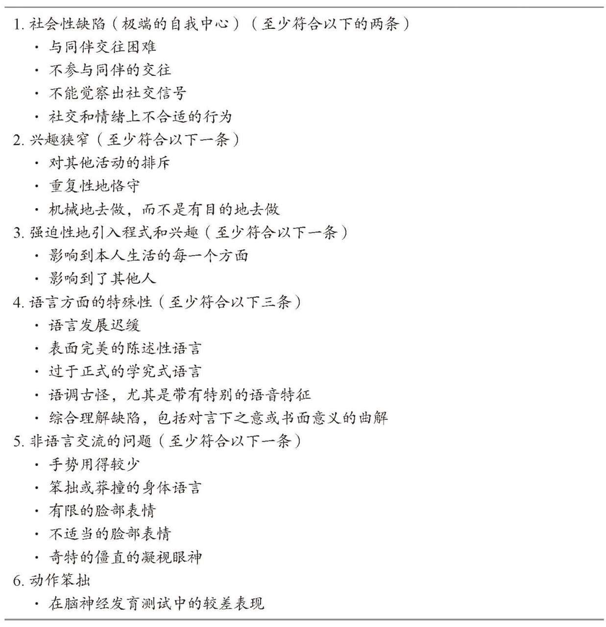

1993年，世界卫生组织出版了第十版《国际疾病分类指南》（International Classification of Diseases，10th Edition，ICD-10）；1994年，美国精神病学会出版了第四版的《精神疾病诊断和统计手册》（Diagnostic and Statistical Manual of Mental Disorders，4th Edition，DSM-IV）。这是历史上首次有两套指南同时包括了阿斯伯格综合征，更准确地说，是把阿斯伯格综合征归入了“广泛性发育障碍”之内。两套指南分类的标准极其相似，而且都认同了孤独症，或者说广泛性发育障碍，本来就是各种各样的，还会有几种亚型，阿斯伯格综合征便是其中之一。

当确定一个新的症候群后，人们常常会在各国医疗文献中寻找其他类似症状的描述。我们现在知道只有一个俄国的神经科学研究助理埃娃·苏哈日娃博士（Dr.Ewa Ssucharewa）在1926年首先发表过和现在的阿斯伯格综合征相似的儿童病例报告（Ssucharewa 1926；Sscuharewa and Wolff 1996）。苏哈日娃博士的描述符合近代被人们认为的“类精神分裂型人格异常”（Schizoid Personality Disorder，SPD）。沃尔夫医生（Sula Wolff 1995，1998）重新研究了有关“类精神分裂型人格异常”的资料后，认为这和如今公认的“阿斯伯格综合征”非常相似。我自己倒是对国际上最终采用了“阿斯伯格综合征”这个名词松了一口气，因为对说英语的人来说，毕竟“阿斯伯格”要比“苏哈日娃”容易说也容易拼写。

汉斯·阿斯伯格医生于1980年去世，并没有机会评价那些英语国家的心理学家和精神科医生对他工作的诠释，其实也是直到1991年他的早期论文才由尤塔·弗里斯（Uta Frith）从德语翻译成了英语。但是现在我们已经有两千多份关于阿斯伯格综合征的研究成果，一百多部关于阿斯伯格综合征的书籍。从上世纪九十年代中期以来，世界各国阿斯伯格综合征的诊断率越来越高。

## 一、阿斯伯格综合征的问卷和评分

ASAS：澳大利亚阿斯伯格综合征量表（Australian Scale for Asperger’s Syndrome，Garnett and Attwood 1998）

ASDI：阿斯伯格综合征诊断访谈表（Asperger Syndrome Diagnostic Interview，Gillberg et al.2001）

ASDS：阿斯伯格综合征诊断量表（Asperger Syndrome Diagnostic Scale，Myles，Bock and Simpson 2001）

ASSQ：孤独症谱系筛检问卷（Autism Spectrum Screening Questionnaire，Ehlers，Gillberg and Wing 1999）

CAST：儿童阿斯伯格综合征测验（Childhood Asperger Syndrome Test，Scott et al.2002，Williams et al.2005）

GADS：奇兰姆阿斯伯格综合征量表（Gilliam Asperger Disorder Scale，Gilliam 2002）

KADI：克拉奇阿斯伯格综合征指数（Krug Asperger Disorder Index，Krug and Arick 2002）

最近针对ASDS、ASSQ、CAST、GADS和KADI所做的评估表明，这五大测量工具在心理统计上都有明显不足，其中KADI显示出了最强的心理统计学特征而ASDS最弱（Campbell 2005）。

下面的这些问卷是为成年阿斯伯格综合征设计的，大部分是由西蒙·巴伦·科恩（Simon Baron-Cohen）和萨莉·惠尔赖特（Sally Wheelwright）设计的，并且附在由西蒙·巴伦·科恩撰写的《必要的差异：男人、女人和极端男性思维》（The Essential Difference：Man，Woman and the Extreme Male Brain，2003）一书后面。

ASQ：孤独症谱系商数（Autism Spectrum Quotient，Baron-Cohen et al.2001b；Woodbury Smith et al.2005）

EQ：同理商（Empathy Quotient，Baron-Cohen and Wheelwright 2004）

想法解读–眼部测试（The Reading the Mind in the Eyes Test，Baron-Cohen et al.2001a）

想法解读–声音测试（The Reading the Mind in the Voices Test，Rutherford，Baron-Cohen and Wheelwright 2002）

FQ：友谊问卷（Friendship Questionnaire，Baron-Cohen and Wheelwright 2003）

ASDASQ：成人孤独症谱系障碍筛检问卷（Autism Spectrum Disorders in Adults Screening Questionaire，Nylander and Gillberg 2001）

米歇尔·加尼特（Michelle Garnett）和我现在正在重新修订针对5～18岁儿童和青少年的澳大利亚阿斯伯格综合征量表，这个量表修订版（ASAS-R）的结果于2007年出版。

## 二、诊断评估

筛检工具通常包括了任何有可能成为阿斯伯格综合征的症状和表现，以便找出所有可能的阿斯伯格综合征个案，但这些不能取代正式完整的诊断评估，诊断评估可以客观地证实在筛检中发现的行为和能力表现是否确切。一个有经验的医生会从这几方面来评估：社会推理能力、情感沟通能力、语言和认知能力、兴趣爱好、运动和协调功能还有感官知觉和自理能力。从先前的筛检资料中可以得出很多关于本人有价值的信息，但需要在评估过程中得到进一步的检查和确认。这个评估过程还需要对其本人的医疗和发育史，还有家庭主要成员的医疗和发育史进行审核（Klin et al.2000），家族史应该包括那些相似能力的审核，即使不是阿斯伯格综合征的诊断也应该包括进来。

现在有两种针对儿童孤独症的诊断工具，《孤独症诊断访谈表（修订版）》（the Autism Diagnostic Interview-Revised，ADI-R，Lord，Rutter and Le Couteur，1994）和《孤独症诊断观察方案》（the Autism Diagnostic Observation Schedule-Generic，ADOS-G，Lord et al.2000）。ADI-R采用的是半松散的结构，主要是根据家庭及看护者所描述的孩子孤独症迹象的严重程度来分析。ADOS-G是通过观察孩子的社交和沟通能力，从而给其行为和能力打分。但这些工具主要都是针对孤独症孩子的，而不是专门针对阿斯伯格综合征的，所以可能对阿斯伯格综合征中那些最细微的症状不会很灵敏（Gillberg 2002；Klin et al.2000）。

对阿斯伯格综合征的诊断评估需要一个“流程协议”（常常由医生自己设计），用一些“脚本”或是一系列的行为和测试来确定有些能力是不是属于这个年龄段孩子的正常能力，还是存在迟缓或变异的情况。医生可能会采用一个对照表对比那些在诊断评估中包括的阿斯伯格综合征症状，还有从文献以及自己的行医经验中所了解的同年龄正常发育孩子的特点。

有些孩子或成人相对容易诊断，有些医生可能在几分钟里就能得到一个大致的诊断意见，但还需要做完整的诊断评估来确认最初的印象。而对有些女孩或妇女，还有那些具有相当智力的成年人，因为他们可能会伪装自己而让评估变得更为困难。评估的过程可能会长达一小时或几小时，视评估的广度和深度而定。医生越有经验，评估的过程可能就越短。下面的几章都会讲到这个评估过程。

诊断评估不能光是评估那些缺陷，还需要考虑那些虽然看起来没问题但也有可能归结为阿斯伯格综合征的其他特征，比如说，一个孩子可能因为某个特殊的兴趣而得过很多的奖和证书，或是在数学或艺术比赛中显示了出色的才华。另一个孩子可能会画出非常写实的作品或发明出电脑游戏。评估也需要向家长询问他们的孩子有哪些可爱的品质，比如说，很善良、有非常强的社会正义感，非常关爱动物等。

《社交和沟通障碍诊断调查表》（The Diagnostic Interview for Social and Communication Disorder，DISCO）让医护人员能够系统详尽地收集有关的发育历史和现状信息，从而用于帮助诊断各个年龄段的孤独症及其他发展障碍（Wing et al.2002），这套工具只能经过训练才能使用。

## 三、当前诊断的标准

一般医护人员都会采用美国精神疾病学会的《精神疾病诊断和统计手册（第四版）》（DSM-IV）来给包括阿斯伯格综合征在内的发展性障碍做评估。DSM-IV里关于阿斯伯格综合征或称为阿斯伯格障碍的诊断标准在2000年修订出版，内容可参见表2.2。

表2.2 DSM-IV的阿斯伯格综合征诊断标准（美国精神疾病学会，2000）

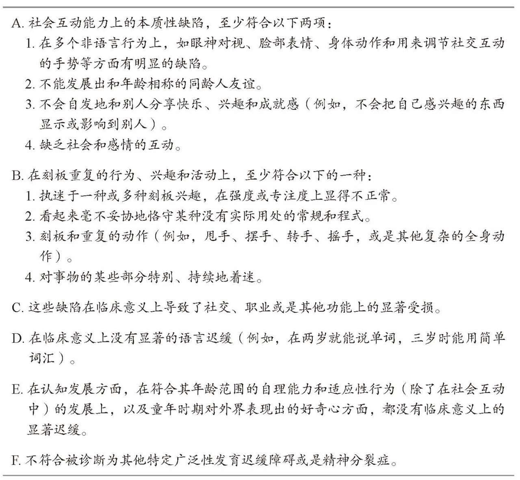

DSM-IV里的内容是为了补充说明诊断标准，只是粗略地提供了诊断的过程和对症状浅显的描述，如果仅仅只靠这个纲领性文件就做出一个阿斯伯格综合征诊断的话，那么这个医护人员对阿斯伯格综合征的理解是远远不够的，得到的结论也是不可靠的。只有经过了长期训练、指导和积累了很多的行医经验之后，医护人员和患者才能得到一个让人信服的诊断结果。

### 目前和DSM-IV相关的一些问题

DSM-IV把阿斯伯格综合征划了进去，受到广大医护人员的普遍欢迎。这是一个明智之举，就像把广泛性发育障碍——包括孤独症和阿斯伯格综合征——从所谓的“二类轴心疾病”（也就是那些长期稳定的不大有康复前景的病症）转移到了“一类轴心疾病”（也就是那些经过早期干预和治疗后症状可以改善的病症）一样。但DSM-IV还是存在一些问题，尤其是在诊断中如何区分孤独症和阿斯伯格综合征。

#### 1．语言发育迟缓

那么到了青春期，对于一个智商在正常范围内的孤独症青少年（即高功能孤独症）或阿斯伯格综合征青少年而言，早期语言发育程度究竟对他们有多大的影响呢？现在有研究在考察孤独症儿童早期语言发育的迟缓是否会精确预示今后的临床症状。已经有四项研究显示，很难把早期语言发育程度作为区分高功能孤独症和阿斯伯格综合征之间的标准（Eisenmajer et al.1998；Howlin 2003；Manjiviona and Prior 1999；Mayers and Calhoun 2001）。智商正常的高功能孤独症青少年和阿斯伯格综合征青少年早期语言发育上的差异，到了青春期前期基本上就消失了。

语言发育迟缓却是吉尔伯格用来判定阿斯伯格综合征的标准之一（Gillberg 1991；Gillberg and Gillberg 1989），一个早期孤独症症状典型但后来语言发育很顺利的孩子和一个没有语言迟缓现象的阿斯伯格综合征孩子，后期语言能力基本一致。按我自己以及其他很多医护人员的意见，早期语言发育迟缓不能作为排除阿斯伯格综合征的标准，但是可以像吉尔伯格标准那样，作为一条“兼容性”的标准。在诊断评估过程中，焦点应该放在当前语言使用的状况，而不是过去的语言发展史。

#### 2．自理能力和适应性行为

DSM-IV把儿童阿斯伯格综合征称为“在认知发展方面，在符合其年龄范围内的自理能力和适应性行为（除了在社会互动中）的发展上，以及童年时期对外界表现出的好奇心方面，都没有临床意义上的显著迟缓”。然而，无论是临床经验还是调查研究都会发现，那些阿斯伯格综合征儿童和青少年的家长们，尤其是母亲们，经常不得不对他们的自理和日常生活耳提面命，小到帮他们切菜，如何保持自己的个人卫生，如何穿着合时得体，或是如何安排自己的时间等等，当父母们填写完关于孩子的自理能力和适应性行为的调查问卷表之后，很容易看出来，孩子这方面的能力相对他们的智力和年龄来讲是比较落后的（Smyrnois 2002）。医护人员也认识到了这些阿斯伯格综合征孩子在适应性行为方面的明显问题，尤其是在对愤怒、焦虑和精神沮丧的控制能力上（Attwood 2003a）。

#### 3．其他重要的或是过渡性的特点

DSM-IV的诊断标准并没有包括最初阿斯伯格医生和其他临床文献中描述过的一个语言方面的现象，也就是老学究式的语言和古怪的语调。DSM-IV也没充分地考虑到在感知觉和统合方面的问题，特别是听觉敏感和在光线、触觉和气味上的过度敏感。阿斯伯格综合征人士在这些方面的问题也会对个人生活造成很大的影响。这个标准也没有把“运动笨拙”列进去，而这也是阿斯伯格医生和其他文献中提到的（Green et al.2002）。

同时，有人也批评DSM-IV强调那些不常见或是过渡性的行为。它引用了“刻板和重复的动作（比如，拍手或玩手，或复杂的全身动作）”，但是从临床经验上看，很多阿斯伯格综合征孩子从来就没有过这样的行为。有研究指出，这些行为即使出现在一些孩子身上，在他们9岁左右也会消失（Church，Alisanski and Amanullah 2000）。

#### 4．阶层式的观点

如果一个孩子满足了诊断为孤独症的标准，那么尽管他在认知、社交、运动和感觉以及兴趣方面也符合阿斯伯格综合征的诊断标准，根据DSM-IV，他也要优先被诊断为孤独症。

已经有好几个研究项目评估过这样优先选择的问题（Dickerson，Mayers and Crites 2001；Eisenmajer et al.1996；Ghaziuddin，Tsai and Ghaziuddin 1992；Manjiviona and Prior 1995；Miller and Ozonoff 1997；Szatmari et al.1995）。这些研究的共同结论是如果严格按照目前的DSM-IV标准，那就几乎不可能得到阿斯伯格综合征的诊断。

很多医护人员，也包括我自己，已经否认了这种“阶层式的观点”。医护人员中的一般共识是，如果孩子的特征符合阿斯伯格综合征的标准，就应该优先诊断为阿斯伯格综合征，而不是孤独症。还有和DSM-IV不同的是，如果这个孩子同时符合孤独症和阿斯伯格综合征的诊断标准，医生往往给予这个孩子阿斯伯格综合征的诊断（Mahoney et al.1998）。值得注意的是，这个诊断标准还在不断发展和演变，而不是铁板钉钉的定论。

## 四、是阿斯伯格综合征还是高功能孤独症

德米尔（DeMyer）、欣特根（Hingtgen）和杰克逊（Jackson）在1981年首次使用了高功能孤独症这个词，就在同一年，洛娜·温也首次提出了“阿斯伯格综合征”这个术语。过去我们用高功能孤独症这个词来描述那些在早期显露出典型孤独症的特征，但在成长中比一般孤独症孩子在智力、认知、交流、社交和适应性上发展更快的孩子（DeMyer et al.1981）。这些孩子的发展远远超出了临床预期，但现在我们还没有一个针对高功能孤独症的诊断标准。

有研究将高功能孤独症孩子和阿斯伯格综合征孩子的认知能力比较，后者是从小没有认知或语言发展迟缓的，研究结果表明，无法将两者明确分开。埃勒斯（Ehlers）和同事们1997年的研究发现，两类孩子中只有少数人才会有特别的认知特点。另一个由美国耶鲁大学做的研究表明了这两者在神经心理上的不同（Klin et al.1995），但是其他也同样使用神经心理学方法的研究小组却并没有发觉两者的不同（Manjiviona and Prior 1999；Miller and Ozonoff 2000；Ozonoff，South and Miller 2000）。最近发表的一个研究发现，用《孤独症行为检核表》（Autism Behavior Checklist，ABC）来系统地评估高功能孤独症和阿斯伯格综合征孩子过去和当前的行为表现，无法区分两者在当前行为上的表现（Dissanyake 2004）。

一般地说，如果就诊者的智商在正常范围内，一般会得到阿斯伯格综合征的诊断。那些阿斯伯格综合征成人和孩子在标准测试中的表现往往非常不平均，有些方面的分数可能会比较正常，甚至会比较优秀，而有些则落到了低能的分数段上。阿斯伯格医生最初是把有一定智力损伤的孩子也包括在孤独症里，但是按照现在DSM-IV的标准，只要是智力迟钝，就要排除掉阿斯伯格综合征的诊断。从总体上来说，我自己会小心谨慎地看待智商，这样就会有智力迟钝但认知正常的案例。

最近一个关于高功能孤独症和阿斯伯格综合征能力研究的论文综述发现，那些宣称能发现两者差别的论文数目和那些宣称没发现有何差异的论文数目是一样的（Howlin 2000）。欧洲和澳大利亚的医护人员把孤独症和阿斯伯格综合征看作同一个谱系而非不同类别的症状（Leekham et al.2000）。目前，这两个名词（高功能孤独症和阿斯伯格综合征）在临床实践中是可以互换的。至今还没有令人信服的论点和数据来认定高功能孤独症和阿斯伯格综合征是两种独立、不同的病症。作为一个医生，我也不认为学术界应该将这两个症状相近且治疗方法也一致的病症截然分开。

不幸的是，孤独症和阿斯伯格综合征在诊断上的模糊性却让有些人得不到政府的相关服务和福利。在有些国家、州或省，如果孩子得到孤独症的诊断，就可以在学校里得到帮助，或是家里得到一定的补助或医疗保险，但是如果得到的诊断是阿斯伯格综合征，这一切可能都没了。所以有些医生明知道孩子是阿斯伯格综合征，但还是会下高功能孤独症的结论，这样孩子就能得到相应的服务，家长也能免去官司之累。

## 五、阿斯伯格综合征的患病率

阿斯伯格综合征的患病率到底是多少，取决于采用哪家的诊断标准。美国精神病学会的DSM-IV和世界卫生组织的ICD-10非常接近，都是最严格的标准，同时也受到学术界的大量批评，被医护人员抱怨很难在临床上执行。按照DSM-IV或ICD-10的标准，早期研究发现阿斯伯格综合征的患病率在每万名儿童中0.3～8.4个（Baird et al.2000；Chakrabarti and Fombonne 2001；Sponheim and Skjeldal 1998；Taylor et al.1999）。照此计算，阿斯伯格症的患病率在1/33000～1/1200之间。

而欧洲和澳大利亚的很多医护人员的首选诊断标准最接近阿斯伯格医生自己描述的吉尔伯格标准（Gillberg，1989）。按照吉尔伯格标准，阿斯伯格综合征的患病率应该在每万名儿童中36～48个，或是在1/280～1/210之间（Ehlers and Gillberg 1993；Kadesjo，Gillberg and Hadberg 1999）。

“患病率”（prevalence）和“发生率”（incidence）这两个科学术语有定义上的区别，患病率是指在某个时期符合条件的案例有多少，而发生率是指在某个时间段里新发生的案例有多少。我自己也使用吉尔伯格标准。以我的临床经验，我们大概只发现和诊断了50%左右的阿斯伯格综合征儿童。那些没被发现的儿童要么就是伪装得很好让人不易察觉，要么就是因为医护人员没能发觉阿斯伯格综合征的苗头而把焦点集中在了另一个诊断上。

## 六、对女孩的诊断评估

前来求诊的大部分儿童都是男孩。从1992年起，我在澳大利亚的布里斯班开了一个服务于阿斯伯格综合征儿童和成年人的诊所。最近12年，我对一千多个诊断报告综合评估发现男孩和女孩的比率为4：1。以我的行医经验，我也发觉女孩比男孩更难被发觉和诊断，因为很多女孩更善于适应和伪装，当然有些男孩也会这样做。利亚纳·霍利迪·维利在她的自传《故作正常》（Pretending to be Normal，Willey 1999）里描述过她是怎样学会在社交场合中应对的。医护人员可能会观察到一个问诊者看起来好像有足够的互动交流能力，态度和手势很得体，但是在学校里观察时，会发觉这个孩子仿照某个社交活跃的人学会了一套社交对策，但当他遇到社交问题时往往得用理性分析而不是直觉来判断和行动。另外一个伪装的案例，为了掩饰自己的困惑，在别人来邀请一起玩的时候先礼貌地拒绝，一直到他搞清楚怎么做以后才会接受。这种策略就是先等一下，仔细观察，只有他觉得能够摹仿前面那些孩子怎么做以后才会加入，但是如果游戏规则或内容突然变化，那孩子马上就会不知所措。

阿斯伯格综合征女孩会有一种在人群中“消失”的本领，和别人若即若离。一个阿斯伯格综合征妇女回忆她的幼年时，说她好像是一个“站在圈外观望”的孩子。还有其他的办法可以避免参加课堂活动，比如很乖很礼貌，这样不会引起老师和同学们的注意；或者是存心消极对待，在学校和家里都不合作，这样的情况被描述成“病态躲避要求症”（Newsom 1983）。

一个阿斯伯格综合征女孩在人际关系中一般不大会“多变”或“蛮横”，而且比男孩更容易发展出亲密无间的关系，别人也愿意和这个天真而“安全”的女孩交往。正是这些因素让她们一开始很难被发觉，因为阿斯伯格综合征诊断标准的重要一条就是“不能发展出同龄人的友谊”。对女孩子来说，这更像是特别的个性，而不是能力上的缺陷。这种女孩的社交问题只有在她的女伴或是导师离开她去了另一个学校以后才会暴露出来。

阿斯伯格综合征女孩的认知和语言能力和有同样诊断的男孩差不多，但是她们的某些特殊兴趣可能不像男孩那样离奇和出格。如果一个女孩对马很感兴趣，大人们不会诧异，但是如果这个兴趣强烈到控制了她的日常生活，那就另当别论了。比如，她把床铺挪到马棚里挨着马睡觉；如果她的兴趣是芭比娃娃，那她可能会把五十多只芭比娃娃按字母顺序排列整齐，却从不和其他女孩一起玩。

和一个阿斯伯格综合征男孩谈话，很快就能看出这是个“小教授”，因为他会用些和年龄不相符的词汇，还不断提供很多让人感兴趣（或是让人厌烦）的事实和数据。而阿斯伯格综合征女孩会更像个“小哲学家”，她们往往会深入思考些社会问题。从很小的年纪起她们就能把认知能力用于分析自己的社交问题，所以比起男孩子，她们更容易发现自己社交方面的不当之处，也更容易和她们讨论些新闻时事。

阿斯伯格综合征女孩在游戏场中身体协调性的表现也不会像类似的男孩那么突出，所以她们就更不容易被发现并被建议去做阿斯伯格综合征评估。无论在学校里还是在游戏场上，甚至在诊所里，如果这样的女孩有能力掩饰一些阿斯伯格综合征症状，那么家长、老师和医生们最后都没看出来也是正常的了。

我在自己诊所看过的阿斯伯格综合征分布于各个年龄段，不过儿童案例还是要多于成人案例。在成人案例中，男女比例在2：1左右。很多来就诊的妇女，要么过去没有足够的自信，要么就是下不了决心。随着自己的成熟，尤其是长期遭遇感情、工作、配偶关系的问题，她们决定要寻求帮助了。另一条路子是她们自己的孩子被诊断为阿斯伯格综合征，她发觉自己也有相似的症状。我们需要多多探讨阿斯伯格综合征妇女露丝·贝克（Ruth Baker）所说的“谱系中不容易看见的那一端”的现象。

## 七、成人阿斯伯格综合征的诊断

对成人的阿斯伯格综合征诊断给医护人员带来许多问题。因为时间太久了，在评估中有关童年时代的回忆会受到准确度的影响。小时候的照片常常可以帮助回忆。家庭照片常常是在某个社交场合里拍的，这可以观察他当时怎么和社会互动。评估中可以请家庭成员讲讲这些照片的背景，当事人当时的能力和表现。学校报告也能反映出孩子有没有人际关系、学习和行为障碍方面的问题。

我们现在也有针对成年人的问卷调查，用来判断阿斯伯格综合征成年人的能力和特征，从中得到的分数和分析极其有用。我也认识到，让家庭成员如配偶或妈妈来验证当事人的答案会非常有益。当事人的问答当然是基于他自己的能力和理解，而另一个不是阿斯伯格综合征的家庭成员的答案可以提供不同的参照。比如，有个当事人被问到小时候朋友是不是经常到他家玩，他回答说他们去他家玩，听起来这个当事人小时候还比较受欢迎也交到了朋友。他妈妈则证实是有小朋友来家玩，但他们不是和他玩而是来玩他的玩具，而那时他只是躲进自己的卧室玩乐高玩具。

有时候也可能是因为自尊心或是担心诊断后被当成精神病，当事人可能故意地误解医护人员。本是这么解释的：

我常常感到自卑，所以我永远不会对人说出那些会羞辱我的真相。如果你问我是不是理解不了别人，我会回答不会的，而其实我确实理解不了人家。如果你问我是不是躲避和人接触，我也会说不会的，因为我不想让你觉得我古怪。如果你问我有没有同情心，我还会觉得被你羞辱了，因为所有人都知道好人有同情心而坏人缺乏同情心。我也会否认我怕很大的噪音，还有狭窄的兴趣，还有会因为程序改变而沮丧。唯一我会正面回答的问题是有没有一个非凡的长期记忆力，对历史事件和事实记得清清楚楚像本活着的大百科全书。因为我喜欢这样的事情，它们让我看起来很聪明。如果我认为这对我有好处，我就回答是，如果对我没好处，我就回答不。（LaSalle 2003，pp242-3）

在评估过程中，这个成年当事人可能会给出具有同理心和社会推理能力的答案来，但仔细观察就能发现那样的答案总是晚了几秒钟才出来，这是因为他在理智分析而不是仅凭直觉就给出答案。这个分析过程看起来就像一个深思熟虑而不是自然而然的反应。

有些具有很明显的阿斯伯格综合征症状的成年人，会觉得他们自己的表现很正常，因为他们摹仿自己的父母来学习交流技能。如果他的父母一方真有明显的阿斯柏格综合征特征的话，那他对于什么是“正常”的看法当然也会大打折扣。

### 成人阿斯伯格综合征评估工具

现在有专门针对成年阿斯伯格综合征的评估办法和诊断标准（Baron-Cohen et al.2005）。《成人阿斯伯格综合征评估》（The Adult Asperger Assessment，AAA）用了两种检查方法，一个是“孤独症谱系量表”（Autism Spectrum Quotient，ASQ），一个是“同理商”（Empathy Quotient，EQ）。还有一些针对成年人的诊断标准，包括DSM-IV和几项附加的标准。这项工作最初由西蒙·巴伦·科恩和他在英国的剑桥阿斯伯格综合征终身服务部（Cambridge Lifespan Asperger Syndrome Services，CLASS）的同事们发起。诊断过程中，医护人员要求求诊者填写ASQ和EQ表，然后对答案进行验证，最后得出结论。

### 成年人的诊断标准

AAA的诊断标准和DSM-IV的一样，但是增加了在成年人身上表现更突出的十项阿斯伯格综合征的症状。在DSM-IV附带的A表（社会互动方面的显著缺陷）里，附加的标准是难以理解社会状况和别人的想法及感受。

在DSM-IV的B表（刻板重复的行为，兴趣和活动）中，增加的一条是在分析事物时总有非黑即白的倾向（如在政治或道德问题上），而不是灵活、多角度地看问题。

在AAA中，有两部分标准来自DSM-IV中关于孤独症的标准，而非关于阿斯伯格综合征的标准。因为对交流能力和想象力的研究和临床经验表明，这两部分标准更适合于成年的阿斯伯格综合征，他们是在语言和非语言交流上存在本质缺陷。

1.倾向于把任何谈话都引向自己或者自己的兴趣。

2.在与别人发起或维持谈话时具有明显的缺陷。除非这些谈话有一个明确的主题或是辩论目标，否则不明白为什么要有应酬性的聊天，或是谈些家常琐事，或是为了打发时光的闲聊。

3.学究似地说话，或者包含了太多的细节。

4.不能分辩出听者是真的感兴趣还是感到厌倦了，即使他已经被告知别就某个话题谈个没完。当其他话题也被提起时，这个特点尤其明显。

5.经常会失言或说些失礼的话而不顾及听者的感受。

AAA的诊断标准包含了至少三条以上在语言或非语言交流方面的缺陷，还包括了至少一条在想象力方面的缺陷。

1.缺乏和年龄相符的多样化的自发性的假想游戏能力。

2.不能讲述、描写或创造出自发性的、原创性的、自主性的小说故事。

3.要么对符合年龄段的小说作品（文字的或戏剧的）不感兴趣，要么只对某种小说感兴趣（比如，科幻小说、电影中的历史背景或技术背景）。

成年应诊者在ASQ和EQ上的答卷提供AAA中五个部分所描述的案例。尽管这种评估的敏感度和专业性还有待今后的研究更深入地检验，但是至少目前我们拥有一个专门针对成年人的评估工具。

## 八、结束诊断评估

在评估的最后，医护人员会根据求诊者个人的发育史、能力范围以及行为表现总结出哪些特征符合阿斯伯格综合征标准，最后确认这些症状是否足以做出阿斯伯格综合征的诊断。我会用一个100块的拼图向求诊者和家属形象化地解释，有些拼板（或者说阿斯伯格综合征特征）是很重要的，比如说边线块和角块。当超过80块拼板被拼接起来后，我们就可以大致知道要拼什么图了，这个诊断也可以下结论了。没有一块单独的拼板能代表阿斯伯格综合征，即使是一个发育正常的孩子或成年人也可能会符合其中10～20块拼板的特征，有时候一位求诊者可能会有比正常人多一些拼板，但是却还不够诊断标准，或者是缺了关键的边角块，总之还是没法完成拼图或者说确定成为一个阿斯伯格综合征的诊断结果。

用这个拼图可以形象化地解释诊断中的术语，即“未特定的广泛性发育障碍”（Pervasive Development Disorder Not Otherwise Specified，PDD-NOS）。这个术语描述了某个人符合很多块拼板，但是有些不是那么典型，或是尚未到达标的程度，但是已经有了足够的拼板确保他“就差那么一点儿”符合阿斯伯格综合征，所以他就需要得到与已有症状相对应的服务。

在完成对阿斯伯格综合征的诊断之后，诊断书最后的结论里还应该写上很多阿斯伯格综合征具有的正面特征，比如，他可以成为某个方面的专家；还应该写明每一项标准中他的表现、总体的表现，还有哪些个人行为和能力的特征不能归咎于阿斯伯格综合征。医护人员还需要对求诊者有没有第二种障碍或双重障碍做出评价，如焦虑、抑郁或行为问题，指出是哪一种障碍最大程度地影响了他的生活，建议他应该优先治疗哪种障碍。

我会把这个结论部分录音送给求诊者和家属们，这样他们可以反复地听，深刻地领会其精神，其他没办法当面听取诊断结论的亲属和老师们也可以通过录音来加强对诊断结果的理解。我也注意到录音带还可以帮助减少误解和误传。后续的工作包括探讨阿斯伯格综合征的可能起因，推荐干预项目、政府的服务项目、团体支持组织、相关的出版物，还有预后和监控的过程等等，当然，这些需要在诊断结束后有更多的约诊来细谈。

## 九、对诊断的信心

我个人对5岁以后孩子的诊断具有相当大的自信心，但是对学龄前儿童就没有那么自信了，因为这么小的孩子能力发展参差不齐。有的孩子会在社交、语言和认知能力上有发育迟缓的现象，但随着时间的推移，有些症状也会“消失”。尽管对年纪小的孩子的诊断最后可能是个假象，但他们还是能从针对阿斯伯格综合征孩子制订的训练项目中提高在社会推理和会话交流等方面的能力。随着年龄的增大，诊断的结论也会越来越准确。现在也有了适用于学龄前儿童的诊断评估工具（Perry 2004），医护人员也可以利用以下几章中关于低幼儿童阿斯伯格综合征的描述来进行评估。

对成年人诊断评估的可靠性取决于求诊者回答问题时的精确度和诚实。他或许可以“装酷”来掩饰自己在社交上的困难，或是在诊所里用自己的分析表现出普通成年人的举止，但事实上他在日常生活社会交流中还是有很明显的困难。这就是智力反应和生活现实的差异了。

有些来就诊的成年人所表现的症状还没有严重到符合DSM-IV的标准，他们在社会理解力方面的问题往往可以通过一个伴侣或同伴的大力帮助来解决，给他指点社交中的行为规则，给他解释社会中的关系，帮他修正那些对别人来说不很恰当的行为和言论。

在工作中，一个富有同情心的同事或上司会有很大的帮助。在这种情况下，对于一个可能从事比较高级的职业、有自己的亲密伴侣、各方面看起来还过得不错的人，医护人员得考虑他是不是也需要做个诊断，他能不能从这个阿斯伯格综合征诊断中得到益处（Szatmari 2004）。在诊断过程中，他可能不需要政府提供的服务，但是可能会从婚姻咨询和职业咨询中得到很大的帮助。但是如果这个人正好失业或离婚了，而且那些阿斯伯格综合征的症状也越来越明显，那么做一个诊断是有好处的。此时重要的不是知道他的阿斯伯格综合征有多少严重，而是替他改善环境，改变别人对他的期望，帮他适应环境，给他必要的支持。

最后，作出阿斯伯格综合征的诊断，就是要实事求是地根据对其能力和社会交往情况的考察结果，结合家长和老师等人的描述和报告，对求诊者作出合理的诊断。其中诊断的核心是在社会交往和社会互动方面是否存在本质缺陷，其他方面的特征则没有轻重缓急的顺序。一个均衡全面评估还是非常重要的，因此，一个阿斯伯格综合征的诊断结论要基于医护人员的临床经验、现有的诊断标准，以及对当事人日常工作和生活的影响。按照阿斯伯格综合征人士杰里·纽波特的话说，“当人性的特征变得不切实际且极端的时候”，也就需要做诊断了。

## 本章重点及策略

妇女和女孩，还有具有相当智力的成年人和儿童，往往更难得到阿斯伯格综合征的诊断，因为他们更善于伪装和掩饰自己的困难。

诊断评估不仅需要检查那些困难的地方，还需要检查那些有可能和阿斯伯格综合征正面特征相关的部分。

在现有的DSM-IV标准中，存在如下几个严重问题。

1.尽管诊断标准中说在语言方面没有临床意义上显著的迟缓，但实际上却包括了那些有语言发育迟缓的孩子。

2.那些智力正常的阿斯伯格综合征孩子和孤独症孩子之间的学龄前语言能力差异，到了青春期早期基本上就消失了。

3.诊断标准中说明在自理能力方面没有临床意义显著的迟缓，但是临床经验和研究结果显示父母常常需要在日常生活技巧和自理能力方面给以语言提示和指导。

4.诊断标准没有提及最初由汉斯·阿斯伯格医生提到的那些语言上的特征，或是感觉知觉方面的问题，却包括了不常见或是暂时性的特征。

5.这个标准说如果症状也符合孤独症的话，那么要优先诊断为孤独症，但是很多医生不赞同这样的判断标准。

6.该诊断标准还处在不断改进的过程中。

克里斯托弗·吉尔伯格的诊断标准其实最接近阿斯伯格医生的描述，也是很多医生的首选。

目前还没有令人信服的结论或数据一致证实阿斯伯格综合征和高功能孤独症是两种不同的障碍。

根据吉尔伯格诊断标准，阿斯伯格综合征患病率约在1/250左右。

我们目前只发现和诊断了约50%的阿斯伯格综合征儿童。

我们对5岁以上孩子的诊断更有信心，但是对那些学龄前儿童的诊断信心不足。

现在已有针对成人的评估工具和诊断标准。

成人诊断结果的可靠性有赖于问卷答案的诚实度和精确度。

被推荐来就诊的成人可能有些阿斯伯格综合征的迹象，但在功能上还没有达到临床可以诊断的程度。

诊断结果的表征严重程度不是最重要的，重要的是如何让本人明白个人状况，他将会遇到什么，他怎么去适应和从哪里得到支持。

# 第三章 社会理解力与友谊

这些孩子的本质特征，在他们面对他人的行为表现中看得最清楚。确切地说，他们在社会团体中的行为表现，就是这一发育障碍最清晰的标志。

——汉斯·阿斯伯格（［1944］1991）

读者或许有兴趣想了解我发明的一种方法，几乎可以去除一个人的所有阿斯伯格综合征特征。这是一个非常简单的处理方法，不需要昂贵和漫长的治疗过程，不需要任何手术或药物，而且实际上大多数阿斯伯格综合征个体私下里都已经发现了这个办法。这个方法真的很简单：如果你是阿斯伯格综合征孩子的父母，只要把他带到自己的卧室，让他一个人留在房间里，然后走出来带上房门，这时候，他的阿斯伯格综合征症状马上就消失了。

## 一、独处

独处的时候，孩子自然不会表现出任何“社会互动能力上的本质性缺陷”，因为社会互动过程至少需要两个人来参与，如果孩子处在独处的状态下，我们找不出任何证据来说明他在社交能力方面有缺陷。独自一人时，因为没有人可以交谈，也就不会有“语音和语言上的怪异特征”，这个孩子可以尽情投入到他的特殊兴趣当中，不会有任何人来评判他的活动是否“异常”（无论在执行强度或者关注焦点方面）。

我将在第六章中说明为什么独处是平复阿斯伯格综合征个体情绪最有效的方法。独处，对他们而言是置身于一个非常有效稳定情绪的环境中，也是一种愉悦的体验，尤其是当他们专注于自己特殊兴趣的时候，那是阿斯伯格综合征个体生命中最大的生活乐趣之一。

独处还能够促进学习。在教室里学习知识，需要有相当不错的社会性能力和语言技能，而阿斯伯格综合征儿童往往普遍缺乏这些能力，无法顺利将精力集中在学业上。我观察到，有些阿斯伯格综合征儿童在入学前就已经掌握了一些学业技能，如基本的读写能力和算术能力，通常他们是通过自己阅读书籍、看电视或者玩教育软件学会的。他们是在独处时通过自学成功地掌握了这些基本技能。

独处时，特别是在卧室安静的环境中（尤其是相对学校操场和教室的嘈杂环境而言），对某些感觉过于敏感的孩子，安静的环境会降低感觉敏感度。阿斯伯格综合征儿童也常常对环境的变化敏感，比如环境中的物品摆放次序突然发生了某些变化，并且表现出焦虑症状。家人应当了解，孩子卧室里的家具和物品需要按照孩子熟悉的方式排列布置，不要随意挪动位置，这样的房间能成为他们的安全避风港。

当阿斯伯格综合征儿童独自一人，心情放松并愉快地专注于某一特殊兴趣的时候，他们的阿斯伯格综合征特征就不会“造成在社会、职业或其他重要功能方面出现临床意义的缺陷”。对于他们来说，独处具有很多好处。只有在其他人进入房间或他必须离开房间跟其他人互动的时候，他们才会出现问题。

我注意到，阿斯伯格综合征人士在一对一的互动交流中表现得相对得体。他们能够运用自己的智力处理一定量的社会性信息以及进行非语言的沟通，并且依照过去的类似经历来确定自己该说什么，以及该做什么。“两人成伴，三人不欢”这句俗语，非常适用于阿斯伯格综合征人士。当他们处于团体环境之中，智能不足以应付多个参与者的社会互动时，他们必须花费更多的时间来处理社会信息；而通常在团体中，人们的沟通会比一对一的交流速度快很多——如果一对一的交流像是一场网球比赛，那么多人团体互动就是一场足球比赛了。

处理社会信息速度迟缓意味着这个人往往无法跟上大家谈话的节奏，容易出现明显的社交错误，通常只好采取退缩的方式。我经常有机会和阿斯伯格综合征成年人交谈，我注意到如果还有其他人在场，或者同时有好几个人加入谈话，这个成人就会突然变得沉默，不像是只有我们两个人在一起的时候那么积极而且流畅地参与对话。

有一次，我对一位阿斯伯格综合征青少年解释说：“你内心感受到的压力，应当与现场互动的人数成正比增加。”他听了之后，马上开始运用数学公式和几何图形计算，当有不止两人在互动谈话时，这些人之间的连接数量是如何增加的：“两个人之间只有一个连接；三个人有三个连接；四个人有六个连接；五个人有十个连接……。”这个例子也形象地说明了为什么阿斯伯格综合征个体不喜欢和一大群人聚在一起。

## 二、评估社会互动技能

阿斯伯格综合征的一个核心特征是社会互动能力存在本质性的缺陷，几乎所有的诊断标准都会提到这一点。另外，一些诊断标准也会提到缺乏社会性和情感交流的能力，以及无法建立与发育年龄相当的同伴关系。不过到目前为止，我们仍然缺少一套以普通孩子发育程度为标准的标准工具，用以测量社会互动能力以及社会推理能力，评估阿斯伯格综合征儿童的“社交商”。目前我们对于社会技能以及社会理解力（比如交流能力、与同伴的关系等）的解释，都只是依据主观的临床判断。所以，医护人员需要具备有关普通儿童社会发展能力的丰富经验，才可能对前来接受阿斯伯格综合征诊断评估的儿童给予准确判断。

为了评估社会互动能力以及社会推理能力，医护人员需要与这些儿童、青少年或成人相处互动。可以利用诊室内的玩具或游戏设备和年幼的孩子一起玩，从而达到评估的目的。有临床意义的指标包括：彼此交流的程度，孩子是否能认识并解读医护人员发出的各种社会信号，是否知道如何回应。医护人员还要评估在孩子玩耍期间，是否具有与实际年龄相当的社会性行为，眼神接触是否恰当，调整互动的方法是否合适，以及是否有足够的自发性和灵活性。在这部分的评估过程中，需要安排结构化和非结构化的游戏。在评估青少年和成人的社会互动技能时，则可以通过谈话询问各种题目，以收集他们在友谊、社交经验以及社交能力方面的信息。有些谈话主题或问题可以选自阿斯伯格综合征诊断筛检手册，从而全面地收集他们在社会成熟度和社会能力方面的信息。

要了解被评估者的同伴关系和交友情况，可以搜集有关被评估者朋友的资料，包括这些友谊关系的本质、稳定度和成熟度，以及被评估者对友谊的看法。

评估者可以采用的常见问题如下。

谁是你的朋友？

为什么他是你的朋友？

你认为做什么事情能够表示友好的态度？

平常你是怎样交朋友的？

为什么我们需要朋友？

你需要怎样做才能成为他人的好朋友？

我注意到，阿斯伯格综合征儿童往往有不成熟的友谊概念，通常落后于同龄孩子至少两年（Attwood 2003a；Botroff et al.1995）。和普通孩子相比，他们的朋友一般都不多，且较少和其他孩子一起玩，每次玩的时间也比较短（Bauminger and Kasari 2000；Bauminger and Shulman 2003；Bauminger，Shulman and Agam 2003）。这些现象也会发生在青少年阶段。利亚纳·霍利迪·维利曾在自传中提到她的大学生活：“我习惯用很简单的方式来定义朋友。对我而言，朋友就是能让我愉快地和他们共处几分钟或者几个小时的人。”（Willey 1999，p43）

如果孩子喜欢与比自己小的孩子一起玩，或者更喜欢大人的陪伴，这就是比较特殊的交友情形。某个阿斯伯格综合征孩子告诉我，他在学校午餐休息时间都会与某位固定的朋友见面。他妈妈解释道，他这位所谓的“朋友”其实是学校的勤杂工，每天中午孩子要去帮助勤杂工做些事情。我妻子的妹妹也是一位阿斯伯格综合征人士，她曾写信给我说：“我从儿童、青少年一直到成人阶段，很少能和同龄孩子和睦相处，我喜欢和老年人在一起，或许是因为他们通常比较温和安静。”斯蒂芬·肖尔（Stephen Shore）也是一位阿斯伯格综合征人士，他曾描述说，“成年人通常比较有耐心聆听孩子们讲一些特殊兴趣的话题，而且可以耐心主动地延续对话。”

有些阿斯伯格综合征儿童或成人会将态度友好的陌生人当作朋友，或者认为朋友就应该像一台可靠的机器。杰米是个阿斯伯格综合征幼童，他这样评价经常和他一起玩的某个孩子，“某一天他没法陪我玩，另一天又没法陪其他的朋友，所以他不是一个真正的朋友。”阿斯伯格综合征孩子可能会认为友谊就是一种“拥有”，因此，常常无法容忍其他人破坏自己所制定的友谊原则。对于青少年和成人来说，则可能无法了解异性的亲切态度未必就是“她对你有意思”。

医护人员同时也会评估求诊者的交友动机、交友能力、维持友谊的能力，以及朋友在其生命中的价值。阿斯伯格综合征青少年和成人会表现出寂寞和自怜的感觉，因为他们会察觉到自己的朋友数量少得可怜——如果不是一个都没有的话。特蕾泽·乔利夫（Therese Jolliffe）在记叙自己往事的文章中曾这样写道，“跟普通人的想法正好相反，孤独症患者也会感到孤独，他们喜爱和人相处。”（Jolliffe，Lansdown and Robinson 1992，p.16）

家长或教师常常会提到，因为阿斯伯格综合征幼儿在人际相处方面表现得笨拙，其他孩子会感觉和他们玩得没劲，并且认为他们不懂交朋友的常识，比如朋友之间需要分享、互惠和合作。杰里·纽波特曾对我说：“与他人分享，必须放弃自己的控制欲。”而霍利在诊断评估过程中告诉我：“我的朋友都不让我去做我非要做的那些事情。”

阿斯伯格综合征孩子通常会以一种不按常规的方式玩耍，他们的偏好和兴趣与其他孩子不太一样，其他孩子马上就会受不了他们的自言自语，或自顾自滔滔不绝地只谈论自己的特殊兴趣。琼·保罗（Jean-Paul）在回顾自己童年的文章中曾说道：“我不善于用惯常的方式和别的孩子一起玩，因为我并不觉得那有什么好玩的。”

阿斯伯格综合征孩子的想象游戏也与其他孩子有本质的区别。同样是在琼·保罗的童年回顾中，他这样描写自己独特的想象游戏：“每个人的想象世界都不一样。对我来说，我喜欢列一份名单，创造出一系列虚构的家族人物，然后让他们和棒球明星卡上的选手共同规划一场想象中的比赛，而且他们还要发明一套独特的语言。”阿斯伯格综合征儿童能够发展出想象游戏，不过他们通常独自进行这些貌似奇怪的活动。

我们经常能看到的景象是阿斯伯格综合征孩子站在学校操场的周围，有时候是他们自己选择独处；有时候他们虽然想在团体中表现得更积极主动，期待融入大家的游戏，却被同伴们认为行为鲁莽，态度急躁。而很多时候一些老师也认为这些行为是“可笑的、不成熟的、粗鲁的、不合作的。”（Church et al.2000）

阿斯伯格综合征青少年的能力如果发展到能够参与同伴的活动，并且加入大家的谈话当中，他们仍然会有不被接纳或是不受欢迎的感觉。以下两段话取自阿斯伯格综合征成人对自己青少年阶段的回忆：“虽然没有被拒绝，但还是感觉没有被完全接纳”和“我感到他们支持和容忍了我，但却没有感觉到他们喜欢我”。缺乏同伴的真诚接纳，对阿斯伯格综合征青少年自尊心的发展有着明显的负面影响。

诊断评估还会包括被评估者在各种社会情景中的表现，比如，与朋友、父母、兄弟姐妹或同龄孩子一起玩耍的时候，以及处在陌生的社会环境中，他们的表现如何。进行诊断评估时，要谨记，孩子与同伴一起玩耍绝对会比和父母或其他成年人（比如做评估的医护人员）一起活动时表现出更明显的阿斯伯格综合征特征。医护人员需要观察他们与同伴一起进行的自由活动，或者请老师汇报有关孩子在社会性游戏中的表现，来补充社会互动技能方面的评估。

此外，必须评估的项目还包括他们是否能察觉在不同的社会情景中有不同的社会行为规范，他们是否能够辨识个人空间，是否能够按照当时的气氛以及文化氛围，灵活修正问候的方式、接触的方式以及交谈的主题。其他必须收集和评估的重要信息还包括：他们面临同伴压力时的反应，独自游戏的持续时间和享受程度，他们能否遵守社会规范，他们的诚实程度，幽默感的表现，他们是否容易遭受捉弄和欺凌，以及遭受捉弄和欺凌后的反应。

在评估儿童社会推理能力的时候，我会让孩子们看一系列的图片，其中包括单独活动或参与团体活动的不同场景，以及相应的情绪反应。比如，有一个孩子因为骑自行车摔下来而哭着；有一个孩子正打算“偷”饼干，旁边有一个孩子在替他“望风”；有个女孩在购物中心走丢了，找不到家人。这些接受诊断评估的孩子们看完图片后，我会要求他们口头描述刚才的图片中到底发生了什么。一般来说，阿斯伯格综合征孩子更容易注意到图片中的物品和身体动作，较少（与同龄孩子相比）提到图片中人物的想法、感受和意图。如果是评估青少年或成人，我会请他们谈一谈个人生活中的一些经历，注意他们是否只会偏重描述行为本身，而较少提到或说明自己和他人的想法、感受和意图。

诊断评估应当由观察、实际互动和自我报告的方式组成，通过评估一个人的社会互动能力和社会推理能力来确定或排除阿斯伯格综合征。这个评估结果也可以作为被评估者的基准线，用来评估将来经过某些干预方案介入之后，他们原本迟钝或异常的各项社会理解能力（阿斯伯格综合征的标志）的发展情况。接下来，本章将主要讨论那些可以改善阿斯伯格综合征个体社会理解力和建立友谊的策略。

## 三、希望拥有朋友的动机

我花了几十年的时间观察阿斯伯格综合征儿童和成人的社会性能力发展，并根据他们希望拥有朋友的动机，把能力发展分成五个阶段。

### （一）对自然环境产生兴趣

在幼儿园或者学前班阶段，阿斯伯格综合征幼儿通常对同伴的活动不感兴趣，也不会想交朋友，他们对自然环境的兴趣会远远高于对社会环境的兴趣。当他们来到幼儿园的操场，常常只是专心观察学校的排水道或水管系统，寻找昆虫和爬行类动物，要么就是抬头盯着天上白云的变化。他们认为其他小朋友的团体活动没什么意思，也不了解其中的社会规则。这些孩子满足于独处，不过有时也许愿意和大人一起玩，因为大人可以回答小朋友们无法理解的一些问题；有时候他们也会躲到学校图书馆的某个安静角落，逃避那些嘈杂吵闹和混乱的游戏场合，去阅读有关火山、气象以及交通运输方面的书籍。

### （二）想和其他孩子一起玩

在小学阶段，阿斯伯格综合征儿童会开始注意其他孩子一起玩的快乐情景，也会想要加入团体活动，体验同伴们的愉快情感。不过，尽管他们的智力水平不差，社会成熟度却落后于同伴至少两年，显然很难以同伴期待的互惠及合作的方式完成互动游戏。

处在这个阶段的阿斯伯格综合征儿童常常渴望能够顺利进入团体，找到一起玩的朋友。但也是在这个阶段，他们开始敏感地意识到自己与同伴之间的差异，可能出现第一章里所提到的调整和补偿心理，表现出抑郁、逃入想象世界、抗拒、傲慢或模仿等行为和特征。

他们最初对于交友的乐观态度可能会慢慢转变为妄想症倾向，尤其是这些孩子很难分辨哪些是偶发事件，哪些是故意的不良举动。阿斯伯格综合征孩子在执行心理理论任务方面存在困难——不懂怎样理解别人的想法、感受、知识和意图（请参考第五章“心理理论”）。其他孩子会根据环境氛围，或者对于他人身份的识别，来辨认对方的某个意见或动作出于善意还是恶意。比如，其他孩子懂得分辨别人的捉弄行为是友好的还是不友好的，但是阿斯伯格综合征孩子就没有这样的分辨能力。

我注意到，阿斯伯格综合征孩子判断人物性格的能力明显不足。其他孩子很容易就看出谁不是好孩子，应当避免接触；而阿斯伯格综合征孩子的判断力则幼稚很多，他们会被那些交友企图不良的孩子诱惑，并且想要模仿他们的行为。

### （三）建立最初的友谊

到了初中阶段，阿斯伯格综合征孩子或许可以建立起真诚的友谊。不过他们对朋友这个概念的理解往往不是过于偏向主观控制，就是太固执，因此，这些孩子常常遭人反感。不过值得庆幸的是，学校里总有一些天性善良的孩子，天生善解人意而且具备喜欢照顾别人的“母性”，他们会发现阿斯伯格综合征孩子的可爱之处，愿意容忍他们的独特行为，今后可能成为他们多年的好朋友。

有时，阿斯伯格综合征孩子未必能与那些富有同情心的孩子建立友谊，反而会和类似孤立的而且具有相同兴趣的孩子（不一定有相同的阿斯伯格综合征诊断结果）成为朋友。这种友谊以功能性和现实考虑为目的，他们互相交换物品和知识，也可能从两人关系扩展到小团体，由一群志同道合而且具有同等社交技能和人气的同伴组成。

### （四）寻找合适的伴侣

到了青春后期，阿斯伯格综合征青少年不再满足于只跟志同道合的人建立柏拉图式的友谊，他们开始表达想结交异性朋友甚至发展终身伴侣的渴望。他们寻求的伴侣是那些能够了解他们，能够提供感情支持，以及能够在社会环境中指导他们的人——换句话说，是一个具有“母性形象”和导师功能的人。

普通的青少年此时往往具备比较成熟的能力和知识，可以顺利地找到合适的目标伴侣，并有大量机会练习和发展这些技能。我们可能会看到一位十几岁的阿斯伯格综合征男孩在孤零零地叹道：“我要怎样做才能交到女朋友呢？”他们内心想要建立超越柏拉图式的友谊，却可能遭到拒绝、嘲笑或误解，从而在面对社交活动时，变得更加困惑、不成熟以及孤立。

### （五）成为终身伴侣

最终，如果阿斯伯格综合征成人在情感和社交方面的能力发展得更加成熟，他们或许有机会找到终身伴侣。不过成为伴侣的那一方应当需要寻找特殊婚姻关系咨询师，学习如何进行必要的关系调整，从而建立起不拘泥于社会习俗的一种婚姻模式。目前，已经有很多关于伴侣是阿斯伯格综合征个体的婚姻关系咨询资源，本书后面所列举的资源栏目里就有相关书籍推荐，也有一部分网络资源和咨询机构的名单。

## 四、友谊的重要性

拥有朋友绝对有很多好处。大量研究显示，一个孩子如果没有朋友，日后更容易出现社会和情感发育迟缓以及自信心低落的现象，到了成人阶段则更容易出现焦虑和抑郁问题（Hay，Payne and Chadwick 2004）。因此，拥有朋友是预防产生情绪障碍的有效措施。

拥有朋友的另一个好处是有助于提高解决问题的能力（Rubin 2002）。如果一群孩子通过合作完成一项任务，他们有机会接触到不同的观点和方法，运用更多的执行能力，从而受益匪浅。团队里的其他孩子可能从不同角度看到某一事情的重要性，或根据已有相关经验及能力寻找初步解决方案。所以一群朋友在一起可以实现更多人力和智力上的优势，更有利于问题的解决。

池（Chee）是位阿斯伯格综合征年轻人，他写道：

对我来说，生命中最糟糕的一件事就是社交。我不懂得如何交朋友，但我非常需要朋友。如果有朋友，就可以得到更多支持，你可以向朋友要求很多事情，而且他们也会帮忙，因为他们是你的朋友。你也可以从朋友身上获得很多经验和知识。但很不幸，我从来没有朋友，所以就得不到任何帮助。如果遇到问题，我都必须一个人处理。我不懂得如何去社交，也就是说，我不知道如何用他人的力量为自己增加优势。这是阿斯伯格综合征带给我的最大困难。（Molloy and Vasil 2004，p.77）

被孤立以及缺乏朋友导致这些孩子容易遭受捉弄和欺凌。学校里的“小霸王”常会锁定那些孤单、脆弱以及得不到同伴保护的孩子作为欺凌对象。多一些朋友就意味着少一些敌人。

得到同伴的接纳和友情，也可以帮助这些孩子从另一个角度去思考其他孩子的动机和意图，从而避免出现妄想倾向。朋友也可以提供有效的情绪监控和修复机制，特别是针对焦虑、愤怒和抑郁等负面情绪。朋友可以指出哪些是合适的社会行为，帮助他们树立自我形象和自信心，而且充当他们的个人咨询师和心理师。德博拉（Deborah）是位阿斯伯格综合征成人，她在电子邮件中和我提道：“治疗自信心低下的最有效方法就是友谊。”这句话尤其适用于青少年阶段。

成为一个好朋友应当具有的所有特征，是成为一个好的团队成员应当具有的特征，也是成年以后职业成功所需要具备的重要特征。我认识一些阿斯伯格综合征成人，他们拥有非常傲人的教育背景，却因为缺乏团队工作能力，以至于无法找到或者维系一份工作，无法得到与自己学术能力相当的收入。拥有朋友和发展友谊的能力，决定了一个人能否获得有助于成功就业的人际交往能力。

拥有与朋友交往的技能，也可以为未来顺利建立伴侣关系奠定基础。儿童阶段与朋友相处时所需要的同理心、信任感、修复情绪以及分担责任等概念，都是未来成人关系中非常重要的组成部分。

## 五、鼓励建立友谊的策略

普通孩子的交友能力建立在先天基础上，在儿童阶段随着认知能力的发展而逐渐提高，并随着社会经验的积累慢慢修正而成熟。遗憾的是，阿斯伯格综合征儿童无法依赖先天能力，他们在面对社会情景和同伴时，主要依赖自己的认知能力和经验。如果没有经过训练或事前准备，阿斯伯格综合征儿童和成人在面对不同的社会情景时很容易出现困难。因此，这样的孩子必须接受指导，并在导师带领下练习如何结交和维系朋友；只有经过大量练习，他们的交友经验才可能进步并获得积极的结果（Attwood 2000）。如果缺乏实际交友经验，他们就无法真正理解“朋友”这个概念的含义（Lee and Hobson 1998）。设想一下，如果你从来没有朋友，又怎能知道如何成为别人的朋友呢？

父母可以安排家中的其他孩子，或者安排游戏日邀请其他孩子到家里来与阿斯伯格综合征孩子一起玩社会性游戏；不过如果父母没有经过指导，他们就无法给这些孩子提供最充分的体验和深度的引导。在这种情况下，和同龄孩子发展互动游戏的最理想环境是学校。学校的教学计划必须考虑到，对阿斯伯格综合征儿童来说，社会课程和学业课程是同等重要的。在社会课程中，要强调交友技能，需要对相关工作人员进行培训和建立资源库。以下建议主要参考了普通儿童在建立交友技能的发展阶段中父母可以协助执行的原则，同样适用于阿斯伯格综合征儿童。

### *普通孩子的友谊发展阶段

普通孩子在3岁以前主要是和家中成员一起游戏和互动；他们常常把同伴看作是在家中与他争夺物品以及争夺大人注意力的对手，而不是朋友。如果有个孩子来家里玩，他们通常会把自己心爱的玩具藏起来。不过在1岁之后，他们会慢慢培养起一些基本的分享、协助和安慰能力，也就是交友能力的基础。这时候，大多数情况下孩子之间出现的可能是平行游戏，他会好奇别的孩子对什么感兴趣，随后模仿其他孩子的动作，不过通常是因为自己觉得有趣和开心，或是能因此吸引父母的注意。我们了解到这个年龄段的普通孩子可能会有自己比较偏爱的同伴，并且总是挑选固定的孩子一起玩。由于阿斯伯格综合征孩子常在5岁以后才被确诊，而那时他们大部分已经错过了这个友谊发展阶段。

#### ·友谊发展的第一阶段——3～6岁

普通的3～6岁儿童具有一个以功能性为目的、自我中心的友谊概念。如果我们问：那个孩子为什么是你的朋友？普通孩子的回答常常是因为距离近（如，住在隔壁，坐在同桌）或因为某件物品（另一个孩子有的玩具是他很羡慕也想拿来玩的）。玩具和游戏活动是这个阶段友谊的焦点，孩子们从平行的游戏方式逐渐发展为意识到玩耍的要素是共享和轮流，否则一些游戏和活动就无法进行。不过在这个阶段，他们所拥有的合作能力仍然相当有限，对于朋友的界定，通常仍然单向地以自我为出发点（他能帮助我，或者他喜欢我）。这时候，孩子之间出现的冲突通常牵扯到物品、使用的工具和对别人空间的侵犯等等。不过到了这个阶段的最后一两年，冲突还可能发生在游戏规则和判定输赢这些方面。从孩子的观点来看，冲突的解决必须通过最后通牒或者武力手段才能达成；他们并不会去请大人来做裁判。孩子们可能会提出一些建议来帮助或安慰受挫的朋友，不过他们认为修补情感的工作应当是家长或老师的任务，而不是他们自己。

如果有人问一个三四岁的孩子今天做了什么事情，他通常会回答玩了什么东西；至于4岁以后的孩子，可能也会提到自己跟哪些人一起玩。社会性游戏逐渐不再局限于一起建造和完成一样东西。不过，友谊关系对他们来说只是暂时的，对于该做什么和如何来做，他们通常只靠自己来决定。

低龄的阿斯伯格综合征幼儿在玩耍时，心中通常有一个很清楚的最终结果设想，不过他们却无法有效地将这个想法传递给同伴，也无法接受和配合其他孩子的建议，因此，经常会导致自己预期的结果无法实现。举个例子来说，某个阿斯伯格综合征幼儿在搭积木房子，他心中已经想好一个成品的蓝图，如果其他孩子在他认为不该放积木的地方摆上一块积木，常常会令他非常生气；这个时候，另外那个孩子也不会理解，为什么自己表示合作的举动会遭到对方拒绝。

进行游戏活动时，阿斯伯格综合征幼儿依然主要在寻求可预测性和控制权，而同龄伙伴们大多已经开始追求自发和协作。维利曾在自传中提到自己的幼儿时期。

在我自己安排的下午茶游戏中，我觉得最好玩的部分是可以好好布置以及摆放各种器具。或许因为整理东西的愿望会超过玩这些东西的愿望，我对同伴一直都没有兴趣。她们总是想要使用那些我已经小心摆好的物品，还经常想重新布置；她们不让我控制整个环境，不按照我期待的方式行事。这些孩子需要更多的自由，而这远远超过我能给予的范畴。

其他孩子通常会认为，阿斯伯格综合征儿童更喜欢自己玩，不喜欢有人加入他们。如果试图加入，他们发现阿斯伯格综合征孩子显得特别霸道，不愿意遵守传统的游戏规则，并且常常视其他孩子为下属。在其他孩子眼里，这种行为举止相当过分，就像是一位老师而不是朋友。因此，这个阿斯伯格综合征孩子最终受到其他孩子的排斥，成为不受欢迎的对象，同时也丧失了发展交友能力的机会。

### （一）适合第一阶段的方案

#### 1．由成人来扮演朋友

阿斯伯格综合征幼儿虽然没有兴趣和同龄孩子一起玩，却可能有强烈的动机和成年人互动，成年人可以通过扮演孩子同伴的角色来教导他们有关社会性游戏的技能。这有点儿像剧场里的演员学习如何演戏，以及排练自己扮演的角色，阿斯伯格综合征孩子可以由此学习如何加入到同伴互动游戏之中。这位成年人“朋友”需要降低自己的互动和语言能力水平，模仿成孩子的同伴。这种做法的主要用意是鼓励两个同等的人一起玩互动游戏，没有任何一方居于控制地位。

学校老师的角色通常被固定，他们永远是“大人”而不是“朋友”。不过，帮助孩子顺利融入幼儿园或学前班的辅导员可以扮演这种“朋友”角色。这个成年人“朋友”其他时间也可以扮演导师或舞台导演，在孩子面对各种社会情景时给予指导和鼓励，也可以借用学校里其他同龄孩子最喜欢的游戏和器材，或购买适当的用品来辅助他们进行互动游戏，让游戏过程更接近于同龄孩子互动时的真实社会场景。

阿斯伯格综合征孩子周围的成年人（特别是父母）应当多观察孩子与同龄人一起游戏时的状况，注意游戏的名称、使用的道具、游戏规则和孩子们的常用语言。父母要采取的策略就是使用“孩子的语言”——该年龄段孩子惯用的说话方式——与他们一起玩，这样才能在能力、兴趣与合作方面求得平等的互动方式。成年人可以示范一些特别的社交信号，然后停下来，鼓励孩子观察或聆听这个信号，并且解释这一信号的意义，向他示范该如何回应。

成年人和孩子一起玩的时候，可以一边做动作，一边清晰地解释自己的想法，这样可以帮助他们注意听别人的想法。我们不能过高期望他们能通过观察周围的气氛或解读别人的面部表情和身体语言，就知道对方在想什么。

让成年人扮演友善的朋友，是一个非常重要的范例。在有些情况下，成年人还需要示范不友好的行为：霸道、捉弄、不认同等。成年人也需要示范适当和不适当的回应，让孩子有机会接触到各式各样的回应方式，并学会去分辨哪些反应是适当的，而且能说得出道理。

#### 2．学会轮流并寻求帮助

在友谊发展的第一阶段，孩子心目中所谓的好朋友是一个能够轮流玩耍并且对自己有帮助的人。如果一位成人扮演“朋友”的角色，就必须示范和鼓励轮流的行为。比如，成人和孩子一起玩积木拼图游戏，两个人要采取轮流的方式将一块块木板放入适当的位置中。如果两个人一起看一本书，那么先由成年人指出某张图片，说出自己的看法并提出问题，然后轮到孩子指某张图片，并问成人一个问题。如果孩子喜欢荡秋千，那么孩子被成人推着荡完秋千之后，成人也要坐在秋千上被孩子推来推去。这两个“朋友”轮流着进行每项活动，并且轮流担任领导者。

为了鼓励孩子帮助别人，成人可以故意犯错，或表示不太确定如何解决某个问题，然后向孩子求助，成人同时表示，在遇到问题时能够向别人求助是一个明智而且友善的举动。这时，成人必须先确定自己处理某项任务的能力表现与这个孩子的能力相当，因为这样的孩子可能会把自己看成一个小大人，当他发现自己的能力明显不如玩伴时就会感到失望或气愤。另外，成人也需要示范哪怕犯了错误也没什么大不了的。

#### 3．与其他孩子进行彩排

成人通常能够轻易调整自己游戏时的步调，给予阿斯伯格综合征孩子适当的指导并提供适当的回应。在他们与成人“朋友”进行过足够多的互动练习之后，就可以与其他孩子进行彩排，可能需要由家中年长的兄姐，或班上比较成熟的孩子来扮演“朋友”的角色，让他们无法在自由活动环境中灵活运用学习到的技能之前，就获得更多被指导的练习机会。

#### 4．把孩子们一起玩的场景录像

一些阿斯伯格综合征孩子喜欢反反复复地观看同一影片。虽然普通孩子也可能有这种爱好，但某些阿斯伯格综合征孩子观看同一影片或节目的次数却多到异常。他们在观看影片的时候不会感到困惑，也不必花费力气与别人交流和谈话。这并非如同某些讨论孤独症行为取向的书里所说，是一种自我刺激行为。我个人认为倒是可以利用这一爱好，让它成为一种有建设性的学习方式。父母可能认为将同一部影片看那么多次纯属浪费时间，不过，真正的问题并不在于他们做了什么，而在于他们所观看的内容是什么。

我建议将阿斯伯格综合征儿童的社交过程录像，比如，孩子和同伴在沙坑里玩的过程，教室里的“分享课程”，在家和堂兄弟一起玩的情景等等。他们可以重复观看这些影片，或许他们自己就希望播放很多次。这些“社交纪录片”能够帮助孩子了解一些社会信号、社交反应、活动的顺序、同伴的举动，以及孩子作为“朋友”的角色表现。成年人还可以使用定格或暂停功能，强调某一特别的社会信号，分辨友好的行为，并帮助他们找出正确的行为。

#### 5．装扮游戏

普通孩子在友谊发展的第一阶段，通常会根据故事书、电视节目或者电影中的热门人物和故事，玩想象和装扮游戏。阿斯伯格综合征孩子也会根据虚构故事中的人物和事件来做游戏，不过本质上和其他孩子的玩法不太一样，因为他们往往倾向于独自活动，少有其他人共同参与。他们的装扮游戏可能会完全依据原版，没有丝毫差异或创造性的改动，中间也可能需要有其他孩子加入，不过这种情况只有在能够完全遵照他们的指示，保证不变动剧本的前提下才有可能发生。游戏中出现的互动也不像普通孩子游戏的互动过程富有创意、合作性和互动性。不过，阿斯伯格综合征孩子对于流行人物和影片内容常拥有惊人的记忆力和知识，并且乐于一再反复表演这些内容，持续几个小时也不会厌倦。我们必须鼓励这些孩子在进行游戏时特别是在和其他孩子一起玩的时候想象力更丰富一些，游戏内容更灵活有弹性。我们辅助游戏的一个重要原则是帮助他们了解，如果事情的发展与自己最初想象的不一致，并不代表那是错的。

可以利用这种游戏鼓励孩子建立灵活思考以及参与其他装扮游戏的能力：给孩子一种物品，比如一块砖、一个回形针或小段玩具火车轨道，请孩子想一想，除了最明显的用途之外，还能有多少种其他使用方式。比如，一小段火车轨道还可以当作飞机的机翼、一把剑或是一个梯子。这个游戏可以鼓励孩子在遇到问题时，能够“打破框框”，进而帮助他在与其他孩子一起玩装扮游戏时，感觉更自在一些。

大人也可以在装扮游戏中演朋友，使用“让我们假装……”这样的开场白，鼓励孩子的灵活思考和创造力。阿斯伯格综合征孩子容易固守某些规则，他们必须明白和朋友一起玩的时候，有些规则是可以改变的，而且有创意地改变一些内容会让游戏更好玩，不必为此感到焦虑不安。通过一些解释友谊关系的社交故事（请参见下页内容），也可以帮助孩子认识到，面对一个有待解决的实际生活问题或智力问题时，尝试另一种方法也许可能引发重要的发现。就像在历史上，欧洲人为了找到一条更快到达印度的航道，却意外发现了美洲大陆。

等他比较习惯灵活思考之后，成年人和同伴就可以鼓励他加入普通孩子的互动想象类型的社会性游戏。我发现，一旦阿斯伯格综合征孩子发现想象力在智力和社会性方面的价值，他们展现的创造力往往令人惊讶。

#### 6．鼓励孩子表现得友好

我常有机会与一些阿斯伯格综合征成人讨论儿童时期的社会性体验，并听到许多对此感到困惑的描述。他们说因为小时候大人对他们的反应总是以指责为主，很少赞美，因此就常会假设，如果到了最后还没有出现任何批评、讽刺或嘲笑的声音，就可以算是一次成功的互动了。不过，对于自己哪些行为是合乎社会规范的，他们却依然毫无概念。一位阿斯伯格综合征年轻人曾这样描述自己的童年：

只有在我做错事的时候，才会得到别人的评论，却从来没有人告诉我，我这次做对了。（来源于私下交谈）

当孩子完成了数学作业，老师会以打勾或打叉来判定答案正确与否。玩拼图或用积木盖房子的时候，孩子明白若是所有的图片都能拼在一起，或者盖出来的房子完整而坚固，这项工作就算是成功了。至于社交场合中的成功标准就没有那么明显，而且非常缺乏正向反馈。我强烈建议不管是成年人、同伴还是朋友，在与这些孩子互动的时候，都别忘了随时随地告诉他们：这个行为是对的！

举个例子，如果我观察一个孩子午休时与同伴一起玩足球的表现，等到游戏结束时我需要明确告诉他，哪些动作是友好的，及其理由。正向的回馈信息包括：“我注意到球滚到一旁的草丛里，你帮忙找出来，很棒！帮忙找东西，就是一个友好的行为。”或“乔舒亚跌倒时，你跑过去问他有没有事儿，这就是一种关怀别人和友好的表现。”或“杰茜卡射入一球，你跑过去向她祝贺‘很棒的一球’，这是很好的赞美方式，也是一种友好的表现。”

阿斯伯格综合征孩子可以用一本关于友谊的日志记录一天或一个星期中他表现出的友好举动，记录的方式可以采取“荣誉簿”的形式，或采用给友好举动记分的方法。记录的内容可以包括自己做了什么或说了什么，以及为什么这是一个友好的行为。一起回忆友好举动，撰写友谊日记的过程，也可以让他们进一步获得大家的肯定以及合适的奖励。

#### 7．社交故事

撰写社交故事是学习社会信号、他人想法、感受以及行为的一种办法，这是卡萝尔·格蕾（Carol Gray）在1991年首先开发的一种教育方法。这不是一种从社会认知理论模型中推导出的学术型方法，而是她在直接同孤独症和阿斯伯格综合征孩子工作和互动过程中总结的可用于实践的方法（Gray 1998）。准备社交故事的过程也可以帮助成年人和同伴认识阿斯伯格综合征孩子的特点，以及了解他们的社会性行为为什么会表现出困惑、焦虑、具有攻击性和不服从。最近，卡萝尔·格蕾（Gray 2004b）进一步修正了撰写社交故事的标准和原则，下面我们就简要说明这些原则。

所谓社交故事，是采用一种既定的方法和格式，借由相关的社会信号、观点和常见的反应，来描述一种情况、技能或概念，主要目的是用一种阿斯伯格综合征儿童或成人容易理解的方式（让他舒服而且具有大量信息），分享社会性和情感方面的正确知识。第一个社交故事，以及随后至少50%以上的社交故事，其内容都应当是描述、确认和巩固孩子已有的表现不错的能力和知识，我们要避免只提出那些涉及孩子无知或失败的内容。社交故事也可以描述如何应用新知识和策略，记录成功事迹。我们需要牢记：社交故事是用来记录社会性知识和社会性成功事迹的一种方式。

在撰写社交故事的过程中，重要的是我们和孩子的合作。我们要关注孩子如何看待某一特定的情景，避免认为成年人一定知道孩子的所有事实、想法、情绪和意图。社交故事的结构应当包括：简介（清晰确认主题）、正文（列出详细的内容和知识），以及结论（总结和强调故事中的信息并提出新的建议）。

如果以年幼的孩子为对象，我们应该从第一人称的角度来撰写故事，采用“我”的口气或用孩子通常称呼自己的名称，同时提供给孩子的信息要确保能转化为自我的内在观念（Gray 2002a）。如果是以青少年和成人为对象，可以使用第三人称，并且采用适合其年龄的杂志撰写风格。这时，社交故事这个名词可以改为“社会报道”。比如，针对主题“年轻人在职场中给予和接受赞美的能力是其交友和团队合作的要求之一”，卡萝尔·格蕾曾写过一篇杂志风格的16页带有插图的文章，向阿斯伯格综合征成人说明为什么在结交朋友、与伴侣相处以及在工作中和同事及客户共事时，都非常需要赞美的行为（Gray 1999）。

特殊兴趣也可以融入到社交故事中。比如，某个孩子对泰坦尼克号沉没的那段历史特别感兴趣，那么社交故事中需要强调的重要信息就可以用取自泰坦尼克号电影或他自己收藏的相关历史书籍和资料中的某些片段来说明（Gagnon 2001）。

社交故事应当采用正面的语言以及建设性的倾向来撰写，即提出的建议应当是“该做什么”，而不是“不该做什么”。正文中应当包括这些内容：描述性句子（descriptive sentences）——提供针对事实的信息和陈述；观点式句子（perspective sentences）——用来解释个人对于自然环境和心理世界的观点。观点式句子用来描述个人的想法、情感、信念、意见、动机和知识，它是影响社交故事成功与否的重要因素，特别是其中包括了用以提高心理理论能力的内容（请参见第五章）。卡萝尔·格蕾建议正文中还可以包括：合作式句子（cooperative sentences）——用来确定在特定场合，什么人可以提供帮助；指导式句子（directive sentences）——在一个特定情况下，建议如何回应对方，给出可供参考的回应选择；肯定式句子（affirmative sentences）——用来解释一个共有的价值观、意见或规则，以及说明为什么需要建立特别的行为规范，为什么一致性是社会的普遍期望；控制式句子（control sentences）——由孩子本人撰写，落实一些个人可以应用的策略，以帮助记忆。在卡萝尔·格蕾开发的撰写社交故事的模式中，文字描述要超出指示命令。最后，社交故事也需要一个标题，以反映该故事的主要特征。

近年来，有不少研究人员大量研究了卡萝尔·格蕾在社交故事方面的工作，发现这种方法在改善孤独症及阿斯伯格综合征儿童的社会理解力和社会行为方面效果显著（Hagiwara and Myles 1999；Ivey，Heflin and Alberto 2004；Lorimer 2002；Norris and Dattilo 1999；Rogers and Myles 2001；Rowe 1999；Santosi，Powell Smith and Kincaid 2004；Scattone et al.2002；Smith 2001；Swaggart et al.1995；Thiemann and Goldstein 2001）。

不管在友谊发展的哪个阶段，社交故事都是学习相关社会线索的一个非常有效的方法，不过第一阶段的效果尤为突出。因为年幼的孩子需要更多指导，从而了解别人的想法和感受，以及处在某个特殊情景中被期待的角色和行动表现。比如，以下这段未发表过的以安抚动作为主题的社交故事的片段。

有时小朋友会过来拥抱我，这是表示友好的行为。昨天的拼写测试我错了三道题，当我的朋友埃米看到我的考卷，知道我错了三道题的时候，她认为我应当会感到难过，我当时也真感觉难过。埃米用手臂环抱我，告诉我：“没关系，朱厄妮塔。”埃米是我的朋友，她拥抱我，好让我的感觉好一些。对有些人来说，一个拥抱会让人感觉好很多，比如一个拥抱就会让埃米感觉好很多。埃米给了我一个拥抱，因为她知道我感觉难过，而且她希望我能够感觉好一些。她抱了我之后，我会对她说谢谢。

对于上述情境，我们需要向孩子详细说明埃米为什么会用手臂环抱朱厄妮塔。这些孩子往往无法理解别人的想法、感受和意图，因此，常觉得别人的行为看起来不合逻辑而且令人困惑。一个安抚的动作可以修复对方内心的感受，而不是那些拼写错误；只有当孩子能够理解这一行为（安抚的动作）的目的是为了修复内心沮丧的感觉，才有可能理解埃米的行为是合乎逻辑的，也才不会因为自己困惑而拒绝接受对方的好意。

撰写社交故事之后，孩子周围的人需要了解如何帮助他成功地使用新的知识和执行新的策略。他可以准备一个社交故事文件夹，将这些故事作为在家和学校的参考资料，也可以多印几份放在口袋和钱包里，一旦遇到和某个社交故事内容相关的情景，就可以随时拿出来读，以唤起自己的记忆。

与友谊发展第一阶段有关的其他社交故事主题还包括：加入和退出的技能（比如，加入和退出某项活动），什么时候及如何提供帮助，与他人共享的重要性，以及如何接受其他孩子建议的游戏。成功加入一个儿童团体参加活动，是这些孩子最难培养的技能之一。普通孩子大都会先观察，聆听，逐渐靠近，然后顺其自然地加入（Rubin 2002）。对于加入过程中的每个阶段，我们可能都需要为他们写一个社交故事。他们需要特定的指导来帮助了解怎样确认并明白一个适合加入的信号，然后才能自然地加入到团体当中。比如，一个欢迎的表情或动作、对话中一个自然的停顿或两个活动之间的转折，这些都可以视作“绿灯”信号。

#### 8．社会信号活动

我用驾驶汽车的比喻来解释不注意或者不认识社会信号的后果。我们在生活中建立了各种道路标志和驾驶规则，以防止人员受伤和交通事故。家长或老师可以让孩子想象，一位司机如果没有看到或看不懂交通标志，导致闯红灯、超速或追尾，都可能引发交通事故。

阿斯伯格综合征孩子往往无法辨认也不懂得如何回应社会信号，从而预防可能产生的社会性意外事件。在课堂上，当老师发出类似清喉咙的“咳咳”声音，普通孩子知道这可能是一种警告信号，就像道路标志告诉司机前方有红绿灯一样，接下来必然会去观察老师的脸部表情，就像司机会注意信号灯一样——如果老师是微笑的表情，这就是一个“绿灯”的信号，代表你可以继续做手头的事情；如果老师皱着眉，眼睛盯着某同学，这就是一个“黄灯”信号，代表你必须小心，最好先停下来观察；如果老师是用一种生气的表情盯着你，这就是“红灯”信号了，清楚明确地告诉你必须立刻停止手头的事情，否则后果严重。而阿斯伯格综合征孩子可能只会将老师的“咳咳”声解释为嗓子太干，需要喝口水或吃个润喉糖。

阿斯伯格综合征孩子无法了解“请勿追尾”类型的社会信号，常常侵犯其他人的个人空间；或是不了解“道路封闭”标志代表“后面没有出口”，或“施工中”代表“请不要打扰”。如果他们没有适当地回应社会信号，这不代表他们故意做出鲁莽行为或有意激怒他人，而是因为根本就不了解社会信号，以至于容易发生伤害他人感情的社会性意外事件。

我们可以利用社交故事来进行社会信号训练，解释某一特定的“道路规则”，提供一个清晰的信号示范，以及练习如何回应特定情况。脸部表情就像是红绿灯的概念，可以藉由一大张红绿灯图片，以及一些脸部表情的图片来说明。可将脸部表情图片分类，并确定红绿灯信号与每种表情的关系：这是绿灯的脸、黄灯的脸，还是红灯的脸？当孩子看到特定的黄灯或红灯表情时，需要做出什么样的适当回应或提出什么样的问题，比如“我很抱歉”，“你生我的气了吗”或“我应当做什么”等等。如果孩子对于某种社会信号的意义感到困惑时，他们也应当给出回应或提出问题，以防止发生进一步的社会性意外事故，比如“我做错了吗”或“我已经糊涂了”。

#### ·友谊发展的第二阶段——6～9岁

普通儿童到了这个阶段开始体会某些游戏需要和朋友一起玩，而且这些朋友也正好喜欢这些游戏。孩子们在游戏过程中能够逐渐接受并习惯朋友在游戏中的影响力、偏好和目标。大部分孩子能够开始敏锐地了解同伴的想法和感受，察觉到自己的某些行动和意见可能会给对方带来生理和情感上的伤害，而且已经可以控制自己的某些行动和想法，“先想想，不说出来”，或者说些“善意的谎言”，目的是避免可能伤害朋友的感情。这个阶段的友谊对互惠和互助有更多的期待。

两个有类似兴趣的孩子可能会建立起一段友谊。孩子们开始根据人的个性而不是拥有的物品来确认友谊，“跟他在一起很有趣，我们一起开心大笑”。互惠的概念（她来参加我的生日，我也要去参加她的），真诚分享资源的态度，以及游戏时力求公平的原则，变得越来越重要。当处理冲突时，孩子们的普遍观点是违规者必须撤回自己的行动，而受害者的理想解决办法是施加同样的不适感给对方，也就是“以牙还牙”。责任归属和裁决结果取决于谁先挑起冲突，而不是谁又做了什么和冲突如何结束。到了大约8岁左右，孩子开始有了“最好的朋友”这个概念，这个人不仅是他玩社会游戏时的首选玩伴，而且也是能够帮助自己解决实际问题（他知道怎么修理电脑），以及修复情绪压力（我难过时，她会逗我开心）的人。不过，这个阶段的孩子并非个个都拥有“最好的朋友”。

### （二）适合第二阶段的方案

#### 1．角色扮演活动

在友谊发展的第二阶段，普通孩子已经能在和同伴们一起玩的时候，建立良好的合作关系，在处理冲突时也有比较富于建设性的想法。但是，阿斯伯格综合征孩子必须运用社交故事和角色扮演活动来学习各种合作型游戏的相关道理，并进行大量练习。比如，给予以及接受赞美，接受建议，为共同的目标一起行动，了解个人的身体空间，身体的接近和接触方式，应对和给予批评，确认厌倦、尴尬和沮丧的信号，以及何时和如何打断对方。可以为角色扮演和示范社交互动（比如给予赞美）的活动录像，以便事后练习并获得建设性的反馈意见（Apple，Billingsley and Schwartz 2005）。

在面对冲突和意见分歧的时候，我们需要鼓励孩子找一位成年人来裁判，而不是由自己来判定对错以及处理后果。社交故事和角色扮演活动都需要强调协商和妥协的好处，公平以及向别人道歉的重要意义。阿斯伯格综合征孩子的自我控制能力可能比较薄弱，如果某个孩子倾向于专横或霸道，经常以威胁或攻击的手段来达到自己的目的，就应当建议并鼓励他采用不同的处理方式，因为对别人友好，才可以得到自己想要的东西。

#### 2．在教室和操场内安排助教

为了帮助孩子成功融入教室或操场的社交环境，学校需要安排助理老师。助理老师可以观察孩子的社会行为表现，尤其是那些符合其所在年龄段应有的能力表现，并及时给予正面反馈和指导。助教的角色具有许多功能。

协助孩子找出相关的社会信号并作出反应。

利用特定的活动或游戏，比如角色扮演和社会性排练，以及与孩子一起撰写社交故事，提供个体化特殊辅导。

鼓励其他孩子在游戏中能够让阿斯伯格综合征孩子参与并顺利融入。

在阿斯伯格综合征孩子和同伴之间出现潜在冲突时，能够提供指导并协助处理。

给阿斯伯格综合征孩子及时提供正面的反馈。

在学校里需要助理老师的时间取决于孩子的能力、环境气氛以及同伴团体的能力因素。

#### 3．玩人偶、娃娃和阅读小说

我注意到，在发展的第二阶段，阿斯伯格综合征女孩的应对机制不同于男孩。女孩更喜欢仔细观察其他女孩的社会性游戏，并回到家里模仿与玩具娃娃和想象的朋友一起游戏，或自己假装扮演某位社交能力不错的女孩。这些活动都能有效地分析并演练交友技能。

女孩的特殊兴趣有可能是读小说，这使得她们能够深度理解各种想法、情感和社会关系。我们可以鼓励男孩也去玩人偶，比如，那些魁梧的动作片英雄模型，不过要让他们表演日常生活的场景，而非相关的电影情节。此外，还可以鼓励他们从那些和个人特殊兴趣相关的主题开始阅读小说。比如，如果孩子对火车着迷，他可以开始阅读《铁路边的孩子们》。

#### 4．共同兴趣

这个阶段的普通孩子，在面对“怎样才能成为好朋友”这样的问题时，一个常见的回答是“我们喜欢同样的东西”。共同兴趣是建立友谊的一个基础。我认识的一个阿斯伯格综合征孩子对昆虫，特别是蚂蚁，非常感兴趣，而且具有丰富的知识。虽然同伴们可以忍受他对蚂蚁的热衷，以及滔滔不绝只谈论蚂蚁的行为，但始终不把他当作是一个可能的朋友，因为其他人对这个话题完全没有兴趣。这个孩子正在学习交友技能，比如，如何进行双向对话，需要等待别人说完而不要打岔，如何给予和接受赞美，以及如何表现同理心。当他使用这些技能与班上的同学相处时，因为这些技能都是依赖于智力和外界指导，其他孩子总是感觉他十分做作和不自然，因此，他还没有交到真正的朋友。

碰巧，附近住着另一位阿斯伯格综合征孩子，同样也对蚂蚁感兴趣。两个孩子的父母便安排这两个年轻的“昆虫专家”碰面。两人见面后所形成的社会关系融合程度令人感到惊讶。两个孩子开始固定结伴，进行蚂蚁考察活动，一起分享有关昆虫的信息和资源，一起开展对蚂蚁的研究工作。两个孩子保持着固定联系，花很长时间进行真正互惠的谈话，讨论他们关于蚂蚁的最新发现。通过观察他们两人之间的互动过程，可以发现谈话中有一个很明显的自然平衡关系，他们能够表现出与其他孩子在一起时不曾出现的高度和谐：非常有耐心地等待对方说完话，能够专注倾听，展现同理心，以及赞美对方。

父母和老师可以依据孩子的特殊兴趣为他们安排适当的朋友。为阿斯伯格综合征孩子的家长设立的地区性家长支持团体组织，可以提供当地其他孩子的姓名、联系地址及其特殊兴趣等资料，帮助建立一段可能成功的友谊。不过我注意到，如果有一方对这个共同兴趣不再那么热衷，这段友谊也可能就此结束。

特殊兴趣也可以促进阿斯伯格综合征孩子与普通孩子之间的友谊。我妻子的妹妹颇有艺术天分，曾经这么描述自己的学校生活：

我很渴望能结交朋友，当有人称赞我的绘画作品时，我通常会慷慨地将画作送给对方，直到有人批评我自我感觉太过良好——这真是一个让我永生难忘的教训，我只不过是想赢得友谊。（来源于私下交谈内容）

如果孩子具有特别的绘画天分，老师可以找另一个具有互补能力的孩子，让两人有机会建立起合作关系。比如，某个孩子擅长写故事，那位绘画小艺术家就可以加入进来负责画插图。这种活动可以帮助他们理解合作技能和团队工作的价值。

#### 5．幽默感

对于“怎样才能成为好朋友”这个问题，另一种普遍回答是“有幽默感”。阿斯伯格综合征孩子通常只能从字面意思上理解别人的谈话内容，所以有时可能无法明白别人在开玩笑。不过，这些孩子有时也可能表现得很出色，颇有一些个人独特风格的幽默感（Darlington 2001）。年幼的阿斯伯格综合征孩子可能会觉得某种口音非常可笑，因此，反复模仿这种音调，当做一个私有笑话，不过他并不与其他人分享，或是解释为什么觉得可笑。幽默能力发展到一定阶段，也可以创造出双关语、词语联想和文字游戏（Werth，Perkins and Boucher 2001）。幽默能力发展到下一个阶段，能够出现如同憨豆先生喜剧节目中的闹剧画面，以及比同龄孩子更早对蒙蒂·皮东（Monty Python）六人喜剧表演节目中超现实的幽默内容感兴趣。

6～9岁的普通孩子开始发展出一些和粗俗语言及行为相关的玩笑，不过这些孩子懂得识别玩笑的性质和适当的环境气氛，以及谁会欣赏这样的笑话。阿斯伯格综合征孩子可能会多次重复一个曾受欢迎的粗俗笑话，而不知道其他孩子早已失去兴趣。他们也不知道在操场引起哄堂大笑的笑话并不一定适合在星期日的午餐桌上讲给祖母听。这时，他们需要一个社交故事，以了解有些笑话只适合讲给某些人，而其他人并不会有同样快乐的感觉。

汉斯·阿斯伯格医生曾提到阿斯伯格综合征儿童缺乏幽默感。根据与好几千名阿斯伯格综合征儿童接触的经验，我却有不同的看法。很多孩子具有独特的、与众不同的对生活的看法，这些都是洞察力和幽默感的基础。我同意克莱尔·塞恩斯伯里（Claire Sainsbury）所写的：“我们并非缺乏幽默感，我们缺少的是一些社会技能即如何识别他人是否在说笑话，我们自己是否该说笑话，以及欣赏和理解与社会习俗相关的笑话。”

有些阿斯伯格综合征青少年具有良好的想象力，可以创造出有趣的笑话和幽默小品，不过其主题始终围绕着自己的特殊兴趣，因此，可能无法引出别人的笑声（Lyons and Fitzgerald 2004；Werth et al.2001）。我认识不少善于创作笑话的阿斯伯格综合征青少年，虽然有时我也不太确定自己是否应该笑，不过看到那些孩子在听到这些有特色的笑话时的笑声，我也会深深为其感动。

#### 6．社交同心圆

阿斯伯格综合征孩子需要指导来了解在社会习俗方面的幽默、与人谈话的主题、接触方式和私人空间、问候和表达情感的动作等方面，由于关系的亲疏远近不同而有所不同。我常利用一项活动来帮助他们：在一张很大的纸上，画出一连串的同心圆，在最里面的一个圆圈里，写上孩子和亲密家人的名字；接下来的圆圈，写上除家人以外清楚了解孩子的其他人，比如孩子的老师、关系比较近的亲戚、邻居以及孩子的朋友等；再往外的圈子，写上家人的朋友、熟人、远亲以及孩子认识但不算是朋友的其他孩子；再往外，包括一些认识但不常碰面的人，比如医生和邮差；最外面的圈子，则写下陌生人或者很少见面的亲戚。

在这些圆圈里的人名确定之后，活动中谈话的主题就侧重于讨论社会行为的多样性，比如，不同类型的问候在不同圆圈中的区别。大人在和孩子做这项活动时，可以跟孩子一起从杂志中找出各种问候举动的图片，把它们剪下来，然后讨论决定哪个图片适合放在哪个圆圈里。比如，握手的动作适合向医生问候，而不适用于欢迎祖母的来访。孩子虽然喜欢而且尊敬老师，但对于7岁大的孩子，每天早晨给老师一个拥抱和亲吻便不适合，应当建议他采用一种充满感情的口头问候。如果能够考虑来自其他文化的问候情况，这个社交同心圆活动就会更吸引年纪较大的孩子。北欧国家以微笑的方式向女性友人问候，而法国则采用吻面礼；至于新西兰的毛利人，对于一位尊贵的客人所采取的传统问候方式是伸出舌头！不过父母必须向孩子解释，除非在新西兰，伸出舌头的动作就绝不是一个能被大家接受的问候方式。

社交同心圆的活动也可以用在学习友谊的方案中，用来说明与友谊相关的各种规则以及不同层面。例如，可以清楚地解释和某人的关系从熟人转换成亲密的朋友。社交同心圆活动的最大好处是帮助孩子从视觉上直观看到我们周围复杂的人际关系层次，并学会在与圆圈中的某类人士交往时，该说些和做些什么。

#### 7．什么话不该说

阿斯伯格综合征孩子通常都不近人情地诚实，总是直率地说出心里的话。他们忠于事实的真相，而不是人们的感受，因此，他们需要学习不能总是说实话。虽然诚实是一种美德，不过这个阶段的同龄人已经懂得说些善意的谎言，以避免伤害朋友的感情，也知道不能向大人告密朋友的违规行为，来表达对友谊的重视和忠诚。不过，对他们来说，同龄人的某些行为肯定是不道德和不合逻辑的，因此，他会勇于向老师报告“是×××做的”，以及向朋友报告是谁犯了愚蠢的错误，但这绝对不是交朋友和维系友谊的好办法。他们可以通过社交故事学习和了解到，为什么有的时候不说实话才是适当的，以及什么时候应当保持沉默。

#### 8．教室里的人类学家

有时可以这么形容阿斯伯格综合征群体：他们是来自不同文化的人，看待和思考这个世界的方式往往与众不同。有些阿斯伯格综合征成人曾建议把“阿斯伯格综合征”改为“错误星球综合征”（Wrong Planet Syndrome）。克莱尔·塞恩斯伯里是位毕业于牛津大学的阿斯伯格综合征成人，她写了《操场上的火星人》（Martian in Playground，2000）以帮助家长和老师认识阿斯伯格综合征。将阿斯伯格综合征群体视为来自不同文化或星球的人，有助于改变成年人和同伴对待他们的态度，也有助于改进干预策略。

阿斯伯格综合征孩子努力想要了解我们的社会习俗，其实很像是人类学家发现了一个新的部落，想进一步认识部落的人群特征和生活习俗。这位人类学家需要找一位来自该部落的人介绍他们的文化、习俗和语言，而指派给孩子的老师或助教就充当了向导的角色，为他们解释这个新的文化或文明生活。这个过程是在不断发现和解释某一特殊习俗存在的道理。初次接触新文化的旅游者需要一本导游手册，撰写社交故事就是向导（老师）和人类学家（孩子）一起合作的一本手册。阿斯伯格综合征青少年和成人通过撰写和阅读这样的导游手册，能够理解其他人群，明白怎么与他们共处。对于其他人群，阿斯伯格综合征成人发明了一个名词来称呼他们，叫做“神经典型发育人群”（Neurotypicals，简称NTs）。

这个文化代言人（或私人向导）可以陪我们这位“人类学家”坐在教室的角落，或在操场的某个角落，一起观察、评论和记录其他孩子的社会互动过程，并随时给予解释说明。此外，两人也可以进行“标定友好举动”的比赛活动，轮流找出其他孩子的友好行为，向导有时需要告诉孩子哪些行为属于友好的或不友好的。与向导一起玩“观察别人”的游戏，可以使他们不必冒风险成为大家的注意焦点，或被视为最容易犯错的人，就可以获得与友谊相关的信息。

#### 9．课后的社交体验

阿斯伯格综合征孩子在学校里要比同伴多花一倍的心力，因为他们不仅要学习功课，还要学习社交课程。与其他孩子不同的是，他们主要利用认知能力而不是先天直觉来学习社交和交友。斯蒂芬曾说过：“为了学习怎么做朋友，几乎用尽了我全部的脑力。”在结束一天的学校生活后，阿斯伯格综合征孩子大都已经经历了足够的社交经验，此时他们迫切需要独处和好好放松自己。就这些孩子而言，友谊的学习体验止步于学校大门。因此，这些孩子往往会拒绝父母的建议，同学校里的朋友在校外保持联系，或放弃与邻居孩子一起玩的机会。如果我们认识到这些孩子在学校里已经有了足够的交往机会，就必须接受孩子此时已经没有精力或动机继续与人互动的现实。如果父母需要安排额外的社交活动，应当选择简短、结构化的、有人监督、容易成功而且是自愿参加的活动。

#### 10．社交能力训练团体

到目前为止，有不少研究报告指出，以阿斯伯格综合征儿童、青少年和成人为对象进行社交能力团体训练的成功范例（Andron and Weber 1998；Barnhill et al.2002；Barry et al.2003；Bauminger 2002；Broderick et al，2002；Howlin and Yates 1999；Marriage，Gorden and Brand 1995；Mesibov 1984；Ozonoff and Miller 1995；Soloman，Goodlin-Jones and Anders 2004；Williams 1989）。团体成员在集体中可以学习为什么某项技能是重要的，并且运用示范、角色扮演、评阅录像等方法，得到来自团队领导和其他参与者的建设性反馈。这一方案的重点训练项目有：对话的技巧和解读，解释身体语言，认识别人的观点，以及结交朋友的能力。这一方案的另一种形式是安德龙和韦伯（Andron，Weber 1998）建立的，以情商发展为重点，利用家人资源——尤其是兄弟姐妹，作为社交能力训练团体的主要成员。他们的训练内容强调，要发展阿斯伯格综合征孩子在不同社交情境中恰当的感受和情感能力。

目前我们还很难确定，社交能力训练团体是否真能够有效改善阿斯伯格综合征孩子的社会融合能力，因为现有的成效评估还都只是定性的研究（没有明确的量化研究）。我们也无法得知，这样的技术是否真能改善他们在自然情境中的特定技巧。不过无论如何，根据以往的经验，父母、老师以及参与者都认为这样的社交团体很有帮助，尤其是团体成员更为肯定这样的机会，与类似的人群一起分享自己的困惑以及社会体验，可以成为日后发展友谊和自助团体的基础。

#### 11．适合同伴的方案

同班同学中如果有阿斯伯格综合征孩子，那么也需要给予其他孩子一些说明和指导，帮助他们认识并学习如何鼓励阿斯伯格综合征孩子建立交友技能。这些同学必须了解，阿斯伯格综合征孩子的游戏及互动方式与普通孩子不同。如果没有老师的引导和支持，他们的举动可能会被排斥或遭到嘲笑，而无法顺利融入同伴的活动。所以在我们为阿斯伯格综合征孩子制定方案以帮助他们具备一定能力与同伴融合的同时，也要对其他孩子制定一些方案来促进双方的融合。普通孩子需要知道如何回应阿斯伯格综合征孩子的某些不友好行为，以及如何鼓励他们培养起交友能力。成功的互动需要双方都能以建设性的心态投入，而老师首先要做个好榜样，同时表扬愿意适应、欢迎阿斯伯格综合征孩子的其他孩子。这种同伴社交团体也需要属于他们自己的社交故事，以促进彼此之间的了解。此外，当老师不在场或忙于其他事情的时候，也需要同班同学伸出援手，帮助阿斯伯格综合征孩子。

#### ·友谊发展的第三阶段——9～13岁

在友谊发展的第三阶段，普通孩子挑选朋友和玩伴时，已经很在意性别的区别；而且在定义朋友的时候，他们已经不仅仅局限于对方能否帮助自己，同时也会根据人格特性。朋友是一个以互补的态度、想法和价值观来提供真心关怀的人。孩子们越来越需要伙伴，需要更多的交友机会，以及保持恒久的友谊；同时他们也强烈希望同伴能够喜欢自己，拥有更多相互分享经验和想法（而不是玩具）的愿望。

当自我意识逐渐显露出来之后，普通孩子开始认识到让人感觉值得信赖的重要性；他们向朋友寻求意见时，不再局限于实际生活的问题，也包括人际关系上的烦恼。朋友之间互相修补情绪和支持对方成为重要成分；如果某个孩子感到悲伤，他的亲密朋友会想办法让他开心；如果生气了，朋友们也会想办法安抚他，以免他陷入更大的麻烦。

对普通孩子来说，朋友和同伴小团体的影响力会越来越大，表现为对自信心的强化或破坏，以及决定什么是合适的社会行为。同伴小团体的接纳态度和价值观会超过父母的意见，同伴小团体的影响力也会大于成年人。

如果朋友之间发生冲突，这个阶段的孩子会开始使用比较有效的修复机制。比如，争论时的火气不再那么大，为了避免直接对立，会采用暂时隔离的方式；坦诚错误，而不再认为朋友之间只需要简单地分出输赢；朋友之间的冲突，如果能获得满意的解决，反而能增强彼此之间的关系；如果宽恕朋友，也可以客观地看待冲突。这些在友谊中呈现的人际关系综合技巧，都将成为他们成年以后形成的人际交往技巧的基础。

### （三）适合第三阶段的方案

#### 1．同性之间的友谊

这个阶段的孩子在选择朋友和同伴时，会有明确的性别偏好。男孩喜欢参加自己感兴趣的团体游戏或季节性体育活动，但阿斯伯格综合征男孩对这些可能毫无兴趣。相比其他孩子，他们不太明白团体游戏的规则，缺乏必须的球类技巧、身体灵巧性和协调性，而且他们的动作往往很笨拙。威尔·哈德克罗夫特（Will Hadcroft）曾在自传中写道：

我害怕别的男孩子，他们也都清楚这点。争球对我来说如同噩梦，我常常不怎么争抢就让球溜走，我的队友对此非常生气。（Hadcroft 2005，p.62）

这些男孩很清楚，自己永远会是团队的最后人选，因而也被其他男孩主动回避和疏远。

当阿斯伯格综合征男孩独自在操场徘徊的时候，可能会有两组人想要接近他，一组是具有侵略性的男孩，他们想要找落单、脆弱而轻信，容易被捉弄和欺负的对象（请参考第四章）；另一组是一些女孩子，同情他孤单一个人，想包容和支持他参与她们的活动和游戏。通常这个年龄段的普通男孩不太喜欢和女孩接近，喜欢用一些带有性别歧视的贬损之辞来评论女孩子，不过，女孩们的态度积极而热情，乐意邀请这个孤单的男孩加入她们。如果阿斯伯格综合征男孩不懂如何与一群女生交往，她们也能够对他宽容（而不是批评）——“他是个男孩，当然不了解，我们很乐意帮助他”。因此，双方可能会就此开启真诚的异性友谊。

对于阿斯伯格综合征男孩，在这个阶段就拥有异性朋友，通常会出现两个结果：一是其他男孩认为他“认敌为友”，因此对他更加疏远；或者这个男孩为了融入女性文化而模仿她们，塑造出女性的身体语言、模仿女性化的用语和兴趣。这个男孩可能喜欢与女孩建立起的友谊，而且确实获得一些好处，不过其他男孩会嘲笑他像个女生，并以“同性恋”的称呼来羞辱他。阿斯伯格综合征男孩如果因而认为世上唯一能接纳和理解他的都是女性——包括他的妈妈、姐妹和女性朋友，可能会造成性别认同方面的问题。

我注意到，在友谊的这个发展阶段，有些阿斯伯格综合征女孩可能会不喜欢和同性伙伴们在一起。她们往往批评女性同伴总是喜欢玩情感或注重感觉的游戏，或热衷谈论她们喜欢或反感的那些人（往往基于一些不合逻辑或不实际的理由）。女性的小派系形式变化非常快速，经常变更不同的成员，这点也常令她们感到困惑。此外也有一些同伴压力让人不舒服，因为女孩们的话题总是围绕着衣服和配件如何搭配才能够最符合时尚潮流。阿斯伯格综合征女孩很难理解这一友谊层面，通常她们倾向于选择符合逻辑的、真实的和舒适的生活方式，而忽视来自同伴的压力。这些女孩挑选衣服往往考虑的是舒适度而不是流行风格，所以通常衣着男性化，因为男式服装穿起来最舒服和实用。至于发型，她们不是留着一头足以把自己遮掩起来的长发，就是剪一头方便整理的短发，而无视够不够女性化。

其他女孩的活动也常令阿斯伯格综合征女孩感到困惑且没有逻辑可循，而男孩们那种偏向体能而非情感导向的活动对她们来说感觉更有趣。她们可能会开始对男孩子的活动感兴趣，甚至可能被男孩团体接纳和吸收，变成大家所说的“假小子”；而男孩们一向比较能容忍侵犯自己地盘的异性，如果她们不知道如何应对某个社交场合，也比较容易得到男孩的支持，而不是嘲笑：“因为她是个女孩，当然不可能了解，不过这没什么关系，我们不在意。”

阿斯伯格综合征孩子需要同时拥有不同性别的朋友，因此，我们必须做一些社交方面的策略规划，以确保他们能得到不同性别朋友的支持。老师们应该经常检查班里团体成员的接纳及排除条件，并且积极鼓励同性朋友给予阿斯伯格综合征孩子以支持和配合。

#### 2．一位导师或好友

这个阶段的孩子有寻求同伴的强烈愿望，而不只是为了能有人一起玩。阿斯伯格综合征孩子如果不能顺利获得友谊，常会感到孤单和悲伤（Bauminger and Kasari 2000；Carrington and Graham 2001）。他们迫切需要友谊方面的相关方案和指导。在这个阶段，除成年人以外，如果有同龄人能跟他们一起讨论方案，就会有更好的效果。普通孩子中，如果有人能和他们建立起一种自然的融洽关系，就可以鼓励这个普通孩子成为他们在教室、操场或社交场所里的导师或好友。好友的意见往往比家长或老师的意见更容易接受，尤其是这个朋友属于善于与人交往而且受人欢迎的类型。学校的导师、好友或家中的兄弟姐妹，可以从孩子同龄人的观点提供有关该穿什么或该谈什么的最新信息，这样他们在同伴中的表现就不会那么突兀了，而且不会因为不懂潮流而受到嘲笑。

在同伴看来，阿斯伯格综合征孩子在人际关系中很可怜，他们不懂穿衣时尚，不喜欢流行的电视节目或相关物品；反过来，他们也觉得，同伴了解的阿斯伯格综合征文化（特别是知识方面）没有价值。佩塔是个阿斯伯格综合征女孩，她在气候方面有着渊博的知识，她觉得其他同龄女孩们很无聊，只会谈论杂志或化妆品，而她热衷的气象学却在其他女孩眼里同样无聊。

#### 3．另类朋友团体

阿斯伯格综合征孩子在这个阶段，比较难以被新建立的同龄社会小团体认同。他们可能因为动作笨拙被崇尚运动能力的小团体所排斥；或因为不同的学习风格被专注学业的小团体拒之门外；或是因为有限的社交能力，而受阻于崇尚社交活动的小团体。不幸的是，总有那么一个声名狼藉的团体愿意接纳这些孩子。这一团体总是敞开大门，加入的门槛就是：有不适当的或反社会的行为表现——这是最不适合他们的一种模式。老师应当安排他们进入一个被社会认同的团体，并鼓励团体中人气较旺的某个成员担任阿斯伯格综合征孩子的导师或好友。

同样，老师也可以根据这些孩子的特征，组织起一个另类团体，这个团体的成员可以包括收藏家、科学家或电脑专家。每个学校都会有几位这样的孩子，具有和阿斯伯格综合征孩子相似的能力和兴趣，但又不具备可确诊为阿斯伯格综合征的其他特征。这个新团体可以利用课后或午餐时间聚在一起，相互比较并交换彼此都感兴趣的事物（通常是根据日本动漫人物制作的商品），或由自然科学老师提供一个项目让他们参与，或者到学校信息技术课老师那里学习程序设计的技能。这种友谊建立在共同兴趣之上，可以让这些孩子免受批评而有安全感。

家长支持团体可以考虑为阿斯伯格综合征儿童和青少年发行定期刊物，请孩子们踊跃投稿，内容可以包括：能与读者和编辑人员分享的特殊兴趣的相关信息，团队成员的近况和作品展示，有趣的影片和书籍（包括介绍阿斯伯格综合征的书籍）的评论，以及漫画、评论、来信和咨询等专栏。一位阿斯伯格综合征青少年提到，他参加过社会能力训练团队，使他有能力担任其他阿斯伯格综合征青少年的导师，在学校刊物的咨询专栏撰写与交友有关的建议。

#### 4．建立团队合作技能

阿斯伯格综合征孩子在进入青春期的初期，就会逐渐察觉到自己的特殊，并且讨厌人家提到他在交友方面有困难，或被建议应该参与相关的训练。他们不希望自己的社会性困难被大家特别关注，或被认为是社交能力迟缓。有一个方法可以让这些处于前青春期或青春期的孩子愿意接受那些以促进社交和交友能力为目标的方案——就是将方案的名称由“促进交友能力”改成“团队合作技能”。因为从本质上来说，作为一个好朋友应当具备的特征，完全等同于作为一个好的团队成员所应当具有的特征。同伴可以接受在学校中训练的团队合作技能。这个年龄的孩子会因为在运动方面的出色表现而获得极高的评价，尤其是在集体项目中，但是最成功的团队不是要有最好的队员，而是有配合最默契的队员。团队合作技能训练也关系着将来能否有成功的职业生涯，因为任何公司都要求求职者具有团队合作的能力，而阿斯伯格综合征青少年可能会乐于接受团队合作能力的指导，并视之为自己能顺利挑选职业的必要条件，因此，他们的合作意愿和动机都会更强。

#### 5．戏剧表演课程

针对不喜欢被大家议论朋友太少或处世幼稚的阿斯伯格综合征青少年，戏剧表演课也是一种可选择的方案。上世纪40年代，汉斯·阿斯伯格医生的护士维克托林·扎克（Viktorine Zak）在维也纳儿童医院曾为阿斯伯格综合征孩子创立了世界上首个训练方案。她运用戏剧活动来教导他们社交能力（Asperger［1944］1991）。我曾有机会见到汉斯·阿斯伯格医生的女儿玛丽亚（Maria），她还能够描述出扎克护士在儿童医院所实施方案的内容。不幸的是，维克托林·扎克不久就在一场盟军轰炸维也纳的事件中丧生，而她拼命想保护的那些孩子们也无法幸免于难。他们永远葬在一起。

利亚纳·霍利迪·维利在她的自传《故作正常》里面提到，自己如何通过观察、模仿和行动来提高社交能力（Willey 1999）。对于处在友谊发展第三阶段的孩子，戏剧表演课是一个特别合适而有效的策略。阿斯伯格综合征青少年可以由此学习并练习适合青少年之间的互动，比如，合适的谈话主题，聆听的艺术，如何对别人表达内心情感，以及什么时候和在多大程度上可以向他人暴露个人信息。通过戏剧活动，可以教导阿斯伯格综合征孩子正确的身体语言、脸部表情和音调，并且提供机会让他们排练如何回应某些特殊情况，比如遭到捉弄。

#### 6．电视节目

我们也可以利用当前流行的电视节目来说明并教导某些社会行为。憨豆先生的连续剧特别适合用来说明如果一个人无法充分了解他人的想法和感受，以及作出违反社会规范行为的后果。憨豆先生这个角色和他的各种经历对于阿斯伯格综合征孩子特别具有娱乐性和启发性。有关社会规范中不合逻辑的内容也可以藉由如《歪星撞地球》之类的电视剧或《星际迷航》（Star Trek）等科幻电视剧中的角色（如Mr.Spock 和Data）来讨论，这些角色的知觉、经验和智慧有助于启发和指导阿斯伯格综合征青少年。

#### 7．利用资源

本书后面列出了一些相关资源和书籍，介绍并讨论这个年龄阶段（以及其他年龄阶段）孩子的交友情况，都相当具有启发性和娱乐性，比如，贾奇·朱迪·沙因德林（Judge Judy Sheindlin）写的书《学校里的潜规则：你不能以貌取人》（You can’t Judge a Book by it’s Cover：Cool Rules for School，2001），书的内容包括一些需要孩子作出社会判断、与友谊有关的情节，比如，在一幅插图里，某位孩子打开午餐盒，以一种疑惑的表情盯着同伴，图画的旁边有一段描述以及选项。

妈妈为你准备的意大利腊肠三明治从午餐盒里消失了，你怀疑是你的一个朋友拿了，因为他身上有腊肠的味道。

这时候你应当：

1.问他是否看到了你的三明治。

2.拿走他的午餐盒，检查里面是否有你的三明治。

3.偷走他的午餐。

4.告诉他，虽然你的午餐闻起来像是意大利腊肠，但实际上是狗食。（Sheindlin 2001，p.51）

另一本卡拉林·比纳（Caralyn Buehner）写的书《我做的，我道歉》（I Did it，I’m Sorry，1998）也采取了类似的风格，着重解释在某些社会情景下正确的反应方式往往不只一个，社会问题绝对不同于科学问题（特别是数学问题），几乎没有唯一正确的答案。阿斯伯格综合征孩子常常想要寻求一个确定的、正确的而且简单的问题解决方案，不过在这个社会里所谓最合适的解决方案，往往都是基于所有参与者对某一解决方案的优点和后果进行评估分析的产物，这需要有相当复杂的推理能力，以及有能力判断各种可能性和公平性的平衡，而并非追求唯一的确定性。根据我的临床经验，阿斯伯格综合征孩子在面对社交问题时，能够选择的解决方法非常有限，而且其中一些方法显得不成熟、具有挑衅意味或过于冲动。不过，在他人的鼓励以及仔细思考之后，这些孩子也能提出或学到其他一些更合适有效的办法。

我也强烈推荐卢克·杰克逊（Luke Jackson）的建议，他是位出色而聪明的阿斯伯格综合征青少年，曾为其他阿斯伯格综合征孩子写过一本自助指南（L.Jackson 2002）。他分析了同伴互动的内容，提出一些相当有智慧的建议。

关于规则，我相信每一位阿斯伯格综合征青少年都听到过一些关于合适行为的规则，你是否听说过以下这些：

不要侵犯别人的空间——这意味着离别人太近了。

无论如何，绝对不要死盯着别人看（哪怕她们的身材超级棒！）。

不要随便评论别人的体型，无论是赞美还是批评。

不要骂人，不要谈论与“性”有关的，或涉及种族歧视的话题，或说一些与“性”有关的影射语。

除非是对自己的家人，或对方同意成为你的男朋友或女朋友，而且在你们双方都同意的情况下，否则绝对不能随便拥抱或触摸别人。

如果你从未听说过这些规则，那么，恭喜你现在终于听到了！不过，这里有一些“但是”……你可能刚好看到和听到有那么一群青少年，他们要么非常亲密地挤在一起，要么以一种危险的方式压在别人身上。接下来，他们会对别人的身材作出各种无理的评论，呃……让我说些什么好呢？！他们会抓住每一个机会说脏话，或与“性”有关的影射语，他们总是随意碰别人或拥抱别人，从不管对方是否是自己的家人，或男（女）朋友。

如果那些规则的确没错，那么，上面这些例外情况就像是青春期的男孩和女孩在执行他们的青少年仪式，将所有的规则抛出窗外，视而不见。我们生活在一个多么奇怪的世界啊！无论如何，我想说的是，你们要严格遵守规则，不管其他人是否想破坏它们。（L.Jackson 2002，pp.104-5）

无论是青春期前期或青春期的阿斯伯格综合征孩子，都需要获得有关青春期发育的信息，以及了解青春期发育如何影响他们的身体和思考，他们也同时需要足够的信息和建议，来熟悉友谊发展的自然变化和性关系的变化。伊莎贝拉·埃诺（Isabelle Hénault）曾设计出一些方案和书籍，专门针对阿斯伯格综合征青少年，来解说青春期发育和性特征（Hénault 2005）。

#### ·友谊发展的第四阶段——13岁～成人

前面三个阶段的友谊发展还只限于小范围的亲密朋友，到了第四个阶段，朋友的数目以及交友的广度和深度都会逐渐增加。基于不同的需求（比如得到安慰、具有幽默感或能提供实际建议），人们会去结交不同的朋友。朋友可以被定义为“无论我什么样，对方都能接受我这个人”，或“对事情的看法和我相同”的人，朋友提供了个人认同感，而且与自己的人格相容。这个阶段很重要的一点是：一个人必须首先能接受自己，然后才能在成人的层次上和他人建立联系——否则，友谊就会成为一种解决个人事务的手段。在这个阶段，友谊的定义通常变得不那么具体，比较倾向于抽象的层次，而且被形容为自主性的相互依赖。友谊也不具有任何独占性或排他性，冲突的解决主要藉由自我反省、妥协和谈判。在青少年阶段，友谊的建立主要基于共同兴趣，比如，学业上的成就，共同参与体育活动或休闲活动，热衷于某个话题（比如消除世界贫穷问题）。在这个阶段，与朋友相处的时间和对朋友的忠诚都会超过家人。

阿斯伯格综合征年轻人能够很清楚地认识到自己面对各种社交场合的困难。斯科特（Scott）有阿斯伯格综合征，他在大学时代的论文中如此描述：

社交能力对我来说犹如外语，我的人际互动行为大都显得笨拙不自然。我必须时时猜测某个行为到底应不应当做，不像我的同伴们，几乎不费什么力气单凭本能就可以做到。这些干扰我日常社交生活的障碍，就是我所患的神经发育障碍的主要问题，一种被称为阿斯伯格综合征的高功能孤独症谱系障碍，它使我很难像普通人那样正常生活。不过虽然我时常感到沮丧，我并不认为这是一件可耻的事情，这只不过是另外一种看待世界的方式而已。我接触过的大多数人都不了解阿斯伯格综合征，所以常常误解我的行为，比如我的每一个努力结交朋友的行为，却总是一步步把他们推得更远。（来源于私下交流的内容）

### （四）适合第四阶段的方案

作为第四阶段的好朋友，其中一个特征就是“无论我是什么样，对方都能接受我这个人”。有些阿斯伯格综合征成人告诉我，没有人能够接受他们的本来面貌：“别人总是希望我变得不一样，变成他们的翻版。”不过最终，他们总会找到一位真正能接受他们的朋友——不会一再坚持要求他改变，而且会真心赞美他们的某些阿斯伯格综合征特征。

不过，这种接受也可能来自另一种友谊形式：动物朋友。

#### 1．把动物当作朋友

动物能无条件接受一个人，小狗看到你总是显得开心，不管它当天是否情绪不佳或疲惫不堪；马儿似乎总能了解你，而且希望成为你的伴侣；小猫喜欢跳上你的膝盖，满意地蜷缩在你怀里。我曾经提到过，猫儿们像是患有阿斯伯格综合征的狗，因此，猫与孤独症和阿斯伯格综合征个体之间有一种与生俱来的吸引力。罗纳德（Ronald）是位阿斯伯格综合征成人，他在给我的电子邮件中说道：“我只有在独处或与猫儿相处的时候，才能感受到自己还活着，而且真正觉得自由自在。”因此，宠物或动物最能有效而且成功地替代朋友，成为人类的同伴，甚至可以替代家庭。而动物与一个不具有侵略性的人（比如阿斯伯格综合征人士）相处时，通常也会感到放松而且有认同感；宠物也可以成为舒适和安全感的来源。对动物有特殊兴趣而且愿意花时间多了解他们，甚至可以造就一项成功的职业（Grandin 1995）。我发现，阿斯伯格综合征儿童及成人有时对于动物的感知和共情的程度会胜于和人类相处。

#### 2．网络朋友

互联网已经成为现代的“交谊舞厅”，让年轻人有更多机会相遇。这种沟通形式对于阿斯伯格综合征个体的最大好处是，他们可以通过打字的方式来表达想法和感受，对他们来说，这绝对比面对面的交谈方式更流畅。在社交聚会场合，他们必须具有聆听并处理别人谈话内容的能力，同时必须过滤背景里的其他声音，快速回应对话，而与此同时又必须分析一些非语言的信号，比如肢体动作、面部表情和语调。如果使用电脑，他可以只专注于彼此的语言交流上，而不会受到太多感觉体验和社会信号的冲击。

在不同社交场合中，都可能会有某些人利用阿斯伯格综合征个体的天真和想拥有朋友的愿望，使他们受到伤害。我们必须提醒他们要一直提高警惕，不要轻易将个人信息告诉对方，除非他和自己信任的人讨论过这段网络友谊。不过，基于分享经验、兴趣和相互支持的原则，还是有可能在网络中交到真诚而且永久的朋友。网络还提供大量机会去认识志趣相投的人，网友们能够接受彼此的理由往往在于对方的知识水平，而不是每个人的社会特征和外表特征。网络“朋友”可以通过聊天工具、网页和特定的讨论区，与他们分享经验、想法和知识。

#### 3．支持团体

最近社会上有一个发展趋势，为阿斯伯格综合征成人建立支持团体。这些团体定期聚会，讨论各个方面的话题：从就业到人际关系，以及为团体成员安排各种社交场合，比如参观火车博物馆，到电影院观看最新的科幻电影等。这些可以一起分享共同经验和处境的同伴们能建立起彼此之间的友谊。这种支持团体有很多不同的组成方式，比如，一开始先由阿斯伯格综合征年轻人的父母们组成支持团体；或者在团体训练机构中相遇的一群孩子，如果有意愿一直保持联系从而促成这样的团体；或者是年龄较大的阿斯伯格综合征人士想要帮助有同样诊断结果的人克服困难而组成支持团体。团体的组成也可以是大学高年级的学生，为了帮助刚进入大学的阿斯伯格综合征新生而组成；或者是某位原来参与过支持团体而且从中受益的阿斯伯格综合征人士，在搬到另一座城市后，组织起当地的支持团体。

在洛杉矶，杰里·纽波特成立了一个以成人为对象的支持团体——AGUA（Adult Gathering，United and Autistic）。他在某次团体聚会中认识了玛丽（Mary），后者也有阿斯伯格综合征。他们的关系逐渐超越了柏拉图式的友谊，陷入爱恋，最后结为连理。有关他们的罗曼史和关系发展，可以参看影片《莫扎特和鲸鱼》（Mozart and the Whale）。

#### 4．关于异性交往的信息

阿斯伯格综合征青少年可能热衷于了解并体验其同龄人所处的异性交往的世界，包括性关系方面的经验，不过我们需要关注他们从哪些地方得到相关信息。如果他们没有亲密朋友可以讨论私人问题，比如，对于某人的爱慕和性感受，那么，他就只能从电视节目（特别是肥皂剧和情景喜剧）或是成人刊物上获取相关的信息。电视剧和情景喜剧常常刻意描写强烈和戏剧化的情绪和人际关系。这些青少年可能会牢记其中的动作和剧情，却用在不适当的场合。举个例子，蒂姆看了一部在青少年中流行的喜剧，剧中有一句台词“I want to have sex with you”（我要和你做爱），引起观众哄堂大笑。蒂姆没有考虑自己身在何处，也不了解当他对着班里的女生说这句话时，为什么班上同学都没有笑。阿斯伯格综合征孩子在看了成人杂志之后，也可能会假定男女之间的亲密举动很快就会发生，而没有意识到需要取得对方的同意。

有关异性交往的信息也可能来自同龄的伙伴，这些同伴看得出他们个性天真，容易受骗而且脆弱。某些怀有恶意的同伴或许就会向他提供一些不适当的信息，告诉他一些容易引起别人嘲笑的建议，或鼓励别人也带着恶意的企图来捉弄他。他们很容易上当，还需要承受被故意错误引导的不良后果。因此，我们必须能够让这些青少年取得和异性交往的正确信息，尤其是在从朋友关系转变为异性关系的初期，需要找到一位可信任的人指导他。

我认识一位曾经非常封闭的阿斯伯格综合征女孩，到了青春期身体发育的时候，因为总受到男孩们的注意而显得受宠若惊。不过由于个性天真，她无法体会到其实男生感兴趣的只是“性”，而不是对于单纯的聊天或相处过程感到愉快，而她也缺乏其他女性同伴来提供有关约会和“性”亲密关系的意见，以及需要注意什么特殊情况。阿斯伯格综合征少女往往没有处世经验，或不知如何分辨性方面的侵略举动，因此，当她们渴望得到同伴的欢迎时，可能就容易陷入“性”方面的危险处境。

#### 5．社交焦虑

阿斯伯格综合征青少年，特别是女孩子，会越来越了解自己在社交方面的无知，知道自己容易犯下社交方面的错误。由于过分担心自己社交方面的能力不足或犯下明显错误，常会导致社交恐惧症，从而社交退缩行为也越来越严重。卡丽（Carrie）告诉我：“我经常处于持久的焦虑状态下，很难面对每天的社交活动。”

这种焦虑感常在一天结束的时候最为严重，特别是临睡前，当他们回顾自己当天的社交经验时。尽管他们已经颇有能力去察觉别人的想法，但这也成为焦虑感（我或许做了一件蠢事）或抑郁感（我总是犯错误而且屡教不改）的一个重要起因。

因此，阿斯伯格综合征青少年应该从父母和同伴那里得到有关社交能力的正面反馈，并且愿意接受指导和排练，以明确在社交场合应该说些什么、做些什么。这种干预的目的是将负面的自我认知转变为正面和乐观的自我认知，强调“成就”而不是“错误”。有关如何改变态度以及自我认知的相关策略，请参考第六章的“认知行为治疗”以及第十四章的心理治疗方案。

#### 6．维系友谊

如果真的发展出友谊，阿斯伯格综合征个体会遇到的困难之一，是他们不知道如何维系这段友谊。他们在该阶段的主要问题包括：不知道应该多久和朋友见一次面，见了面应该谈些什么话题，送什么礼物才合适，什么样的语言和动作符合移情原则，对于不同的观点如何表达出大度和宽容的态度。阿斯伯格综合征个体由于“非黑即白”的价值倾向，只要朋友出现违反友谊的举动，势必会结束这段友谊，而不是寻求和解。一个有效的策略是：鼓励他们在做出仓促的决定之前，先向其他朋友或家人寻求建议。

#### 7．向其他人说明阿斯伯格综合征

如果一个幼儿被确诊为阿斯伯格综合征，如果从幼儿园到小学阶段都能采用早期干预改善社交能力的方案，而且一直延续到高中结束，那么，应当可以达到很好的效果。虽然目前我们并没有长期的研究数据来证明他们的社会理解力和同伴关系的确有进步，不过根据临床经验可以证实，社会理解力训练方案对于个体孩子的确有帮助。不过如果他们到了青少年和成人阶段才被确诊，就已经错失了早期干预的介入时机，特别是到了成人阶段，已经没有机会进入这些相关训练计划和训练资源。

对于成人，可以选择的解决方法不是去寻求一些不确定的训练计划，花费几十年的时间去培养某些能力，反而是找到一些方法向其他人说明情况，让对方了解阿斯伯格综合征特征为何会困扰到朋友、同事和所有相识的人。例如，他们和人交谈时，常常无法注视对方的眼睛，尤其是在回答问题的时候。我认为，与其花费时间参与训练，学习什么时候该注视对方以及解读他人脸部表情，不如向别人直接解释回避目光接触的真实理由，例如：“我必须移开目光，这样自己才能专心回答你的问题；这不代表我本人粗鲁无礼，不诚实或不尊重你。”如果要开始独自阐述一段别人也许会感到无聊的特殊兴趣，可以提前说明：“有时我喜欢谈太多自己的兴趣，如果我让你感到无聊，请你要求我停下来，我绝不会认为你无礼。”他们可以创作一些口述的社交故事，以便对其他人解释那些看上去属于自我中心或鲁莽的行为，其根源到底是什么。

如果能给其他人一个简洁而准确的解释理由，他们就不容易感到困惑，而且更愿意接受阿斯伯格综合征特征。成人或许需要一些辅导，来找出合适的解释，不过我注意到，多年来他们的父母或伴侣都已经帮助他们向别人提供了合适的解释。

#### 8．移居到其他文化国度

我经常在世界各地做阿斯伯格综合征专题演讲，当到达一个和我的本国文化有显著差异的国家时，会惊讶地发现听众中有不少来自英语系国家的阿斯伯格综合征人士。比如，有次在日本，我遇到一个充满魅力的英国男子理查德，他已经在亚洲住了好几年。他提到自己在当地的社交表现如果有差错，一切行为都会被认为是文化差异所致，而不是故意侵犯或混淆视听。日本人相当能容忍他的笨拙社交能力，尤其是他日语说得流利，而且总是满口称赞这个文化，人们对他的态度就更友好了。斯蒂芬·肖尔（Stephen Shore）在写给我的电子邮件中提到：“有些阿斯伯格综合征人士（包括我自己）喜欢长时间出国旅行，或定居在国外。我们与众不同的表现以及缺乏社交能力，都会被认为是外国人的原因，而不会被认为是故意的不良行为。”

阿斯伯格综合征人士也可以结交一些来自其他文化的游客，分享面对社交文化的无知经验，因为他们面临着相同的挑战。

#### 9．与同事建立友谊

由于阿斯伯格综合征个体的友谊发展迟缓，当他们达到友谊发展第四阶段时，可能已经从高中毕业，从而必须从工作场合、大学和通过休闲活动寻找朋友。对于年轻人，把工作同事转变为知心朋友将会是一个不小的挑战。他们在工作岗位上，需要找到一位社交导师，能够理解他们的异常人格和交友能力，并且以一个朋友和代言人的身份提供指导。

这位导师也可以帮忙判定其他同事愿意与他交往的真诚态度如何。有时阿斯伯格综合征个体容易对一个友好的举动、笑容或动作，做出过多的解释，以至于误解别人的意图；这种情形可能造成他对某个和善友好的人产生强烈的兴趣或过度迷恋。

#### 10．社交的时间长度

我们每个人能够从事社交活动的时间都有容量限制，我以装满“社交水桶”的比喻来形容。有些人的社交水桶很大，需要很长一段时间才能装满；阿斯伯格综合征个体的社交水桶很小，或者根本只是一个杯子，很快就能装满。对他们来说，一般的社交活动持续的时间都太长了，远超过他们所能负荷的程度，尤其是他们的社交成功度往往取决于智力成果，而非天生本能，因此，社交活动很容易让他们精疲力竭。

如果人际互动是简短且目标清楚的，他们会表现得更自在一些，而且在互动完成时，他们也比较有能力得体地结束这段互动。普通人不应当将阿斯伯格综合征个体突然结束一段对话和聚会的行为视为失礼的举动，因为他们并非有意冒犯谁，可能只是因为精力耗尽而必须离开，绝对不是轻率的冲动之举。

此外，还有一个影响社交时间长度的因素，就是他们无法找到想要交谈或花时间相处的对象。就像达伦（Darren）对我说的：“我不是反社交人士，而是找不到太多我喜欢与之相处的人。”

## 六、社会理解力发展的预后

汉斯·阿斯伯格医生认为：

普通孩子只凭先天本能，通常在无意识的状态下就可以学习到必要的社交习惯。这些本能却困扰着孤独症孩子，而他们的社会适应性必须通过智力来发展。（Asperger［1944］1991，p.58）

获得一项技能的渠道有两条——先天本能或后天教导。阿斯伯格综合征儿童或成人需要接受后天教导才能具有某些社交能力。我建议，他们的学习过程应当包括详细说明某些社会规则存在的理由，因为对他们来说，除非他们认为存在理由是合乎逻辑的，否则绝对不会轻易改变自己的行为。针对他们的教导方式应该采用彼此发现对方的社会世界的做法，因为他们几乎就像是人类学家，针对一个新发现的文化进行研究，而老师或新文化的代言人需要发现并从欣赏的角度看待他们不同的思考方式和文化。我们需要记住一个重点：不要带有特定价值观，评判某个文化绝对优于其他文化。

阿斯伯格综合征个体常常感觉到其他人群都是喜爱社交的狂热分子，其他人会假定每个人都可以且能够轻而易举地与人交往，那些不喜爱和擅长社交的人一定具有某种缺陷或者愚蠢而且必须被纠正。其实，这两种不同文化之间应当取得一个妥协；不过那些处在主流文化中，以“社交电报”方式轻易沟通的人会假定这一鸿沟需要由少数人来弥补，而不是自己这个主流群体。

但是当主流群体与阿斯伯格综合征个体互动时不应当抱有这样的假设。普通人可能会抱怨他们不善于解释，到底为何会做出与社会规范相冲突的行为，可是普通人群没有意识到自己其实也不善于解释，为什么他们有违反某些社会规范的例外情况以及出现这些社会行为的本质原因。

1938年，汉斯·阿斯伯格医生在谈到社交互动能力的预后时，曾写了下面这段话。

如果我们以一种务实的方式教这些孩子各种“礼仪规则”，他们就会记录下来，当作生活模式来执行。更“现实”的做法是——以日程表的形式，包括有日常例行事项的各种可能变化，以及双方必须坚持用一种学究的方式写下的规则——这样一来，所有情况就会变得更好。但是就我看来，良好的预后结果并非来自于生活习惯的养成，或者经过无意识和本能的方式自我成长，反而是需要通过意识和智力的训练模式，并经过多年的困难和充满冲突的努力，最后达到同化于社区的最佳结果，而且随着智力越来越成熟，结果也能够越来越成功。（Asperger 1938，p.10）

他们会逐渐建立起一个有关社交经验和社会规则的自我心灵图书馆。这个过程就像是学习一门外语，怎样去面对除了发音规则和语法以外的所有问题。有些阿斯伯格综合征成人认为，社交谈话就像是在运用一种完全不同的语言，他们没有翻译，也没有人向他们解释一切。

我用一个有五千块的社会性拼图作为比喻。普通人的脑子里天生就有拼图盒子上的完整图案，亦即天生就拥有如何与别人交往和连结的能力。他们的社交拼图在儿童时代就可以轻松完成，且凭着盒子上的图形（或本能）一直都可以顺利解决社会性问题（拼上一块拼图）。而阿斯伯格综合征孩子脑子里天生不曾拥有这个图案，只能根据经验来界定每一小块的连结和模式，因此很希望他人的指导。随后，这些社会性拼图会以一小堆、一小堆的方式拼凑成几个互不连结的小图案；经过三四十年之后，他们才可能确认出大多数特定的模式，拼图的速度也快了起来。有些阿斯伯格综合征人士最终能够拥有很好的社交能力，可是其他人群并没有意识到，他们用了多大的心智努力，经过多少不懈的支持、理解和教育，最终才能达到这一境界。我想借用利纳亚·霍利迪·维利在其自传《故作正常》中写的一段话作为本章的结尾。

回首往事，我可以回想起那些确有兴趣和我交往的人，我可以看到自己曾认识的一个男孩，那仿佛就是昨天发生的事情。我可以清楚记起我们谈话时，他的脸庞和脸上的表情。今天，如果他注视我的表情一如往昔，我相信自己能够看出他的善良和温柔。但在那个时候，我没有好好把握住机会和他相处，我错过了他伸出来的友谊之手。如果那一切都发生在今天，我一定不会再错过，因为他的面容对我来说，不再是毫无意义的了。（Willey 1999，pp.61-2）

## 本章重点及策略

第一阶段（3～6岁）

1.成年人可以扮演孩子的朋友。

2.教导孩子学习轮流和寻求别人帮助。

5.与孩子一起玩假扮游戏。

6.鼓励孩子表现友好。

7.撰写社交故事，来帮助孩子了解特定的社会情境。

8.利用“社会信号”的活动教导社会信号，以防止社交意外事故发生。

第二阶段（6～9岁）

1.运用角色扮演活动，提供合作型游戏的练习机会。

2.安排一位助教在教室和操场对阿斯伯格综合征孩子及其朋友提供指导和反馈。

3.鼓励男孩和女孩玩人偶或娃娃，以及阅读小说。

4.与志趣相投的孩子寻求共同兴趣。

5.帮助孩子发展幽默感。

6.利用社交同心圆的教学方式，帮助孩子学习问候、与人交谈的主题、触摸、个人身体空间和表达情感的肢体动作等。

7.教导孩子哪些话不能说。

8.以教室内的“人类学家”角色引导孩子认识社交习俗。

9.确认放学后的社交经验要简短、结构化、受到监督、容易成功而且自愿。

10.帮助孩子加入社交能力训练团体。

11.为普通孩子提供学习方案，让他们了解如何和阿斯伯格综合征孩子一起玩，并成为他的朋友。

第三阶段（9～13岁）

1.鼓励结交同性和异性朋友。

2.鼓励某个同伴成为孩子的导师或好友。

3.帮助孩子找到并加入一个有共同兴趣和价值观的另类团体。

4.介绍以发展团队合作能力为目标的训练，作为教导交友能力训练的替代品。

5.鼓励孩子参加戏剧课。

6.利用电视节目，特别是情境喜剧以及科幻节目，来解释各种社会行为。

7.利用各种相关书籍和资源教导交友能力。

第四阶段（13岁～成人）

1.鼓励他们将动物视为可能的朋友。

2.鼓励他们利用网络资源交朋友。

3.支持团体对于阿斯伯格综合征年轻人非常有价值。

4.提供有关异性交往的信息。

5.探寻不同的策略，来降低他们在社会情境中的焦虑感。

6.指导如何维系友谊。

7.教导成人如何向别人解释阿斯伯格综合征症状。

8.探讨移居到其他文化国度的益处。

9.指导如何与工作伙伴建立友谊。

10.如果有必要，鼓励他们限定社交活动的时间长度。

# 第四章 捉弄与欺凌

孤独症谱系的孩子，仅仅因为他们的与众不同以及不合群，就会经常遭到来自同学的折磨和排斥。因此，我们常常可以看到，无论是在游乐场还是在上学路上，一个孤独症谱系的孩子被一群嘲笑他的小顽童包围着。这个孩子或许正在盲目地攻击对方，或许是在无助地哭泣，无论哪种情况，他都毫无招架之力。

——汉斯·阿斯伯格（［1944］1991）

第三章提到的那些方案和活动都是为了提高阿斯伯格综合征儿童和青少年的社会性知识和融合能力。父母和老师都希望这些融合是令人愉快、卓有成效的，但是，虽然会有一些孩子很乐意接受阿斯伯格综合征同伴，并表现出关怀、照顾和友善的态度，不过也有一些孩子具有“侵略性”，把他们当作可以轻易捉弄和欺凌的对象。

## 一、捉弄的类型

从我的临床经验来看，对阿斯伯格综合征孩子最常见的言语捉弄和辱骂是“笨蛋”、“神经病”和“同性恋”。虽然在一般孩子的互动中也能听到这些带有贬义的词汇，但是对他们造成的伤害会更深。因为这些孩子一向以自己的智力为傲，当他们在社交场合表现不佳或者不够自信的时候，智力优势往往能够有效地补偿他们的失落感。因此，被称为“笨蛋”绝对是对他们相当严重的个人侮辱，而且非常可能造成他们强烈的挫折感。而被称为“神经病”也同样是严重的个人耻辱，特别是当这个孩子正在接受心理医生和精神科医生的辅助治疗并服用药物时，他可能因此开始怀疑自己的心智，继而担心日后出现心理障碍。在今天的学校里，“同性恋”这个词也很不幸地成为极具杀伤力的侮辱。阿斯伯格综合征孩子习惯于从字面理解词义，会当真认为自己就是同性恋者。因此，这些词义不明、带有嘲弄性质或是令人生气的评论，可能会对他们产生终身的影响。

有时，其他孩子在游戏过程中的嘲弄和身体冲突是善意的，特别是男孩子们喜欢玩一些诸如“小狗打架”的游戏，并且互相取笑。普通孩子在三岁左右就可以区分真实的打架以及非恶意、游戏性质的打架（Rubin 2002）。当打斗双方都笑闹着，愉悦于此类体验的时候，这就不能算作捉弄。但是由于阿斯伯格综合征孩子很难确定对方的意图，其他孩子很快就不愿意和这个逗不起来的孩子一起玩了。

## 二、什么是欺凌

如果你向周围的朋友、同事和孩子询问“欺凌”的定义，得到的答案一定是多种多样的，因为一个人眼中的欺凌在另一个人看来也许只是一种消遣别人的行为。对学校来说，为了保证政策制定和实施的一致性，有必要就“欺凌”达成一个统一的定义。一般而言，欺凌包括不对等的权力，从生理或情感上伤害别人的意图和一个欺负的对象。在查阅了有关儿童受欺凌事件的文献之后，格蕾（Gray 2004a）运用阿斯伯格综合征的相关知识将“欺凌”定义为：“在一种生理、语言、社交和情感等不平等的互动关系中，抱着负面的意图，长期针对某一特定的目标反复做出一些负面的行动。”

在学校的一些特定的场所，比如走廊、校车、操场以及成年人不易觉察的环境中，最容易出现欺凌事件。阿斯伯格综合征孩子还常常在住家附近被邻居孩子、家庭共同的朋友或年长的手足欺负。欺凌事件中经常会有旁观者，而且有不同的表现形式，其中最常见的是语言或者身体上的对抗和恐吓，破坏私人用品，以及贬损对方的行为和评论。成年人如果做出类似的行为，可能会因为侮辱他人而触犯法律，或者因为骚扰他人而遭惩罚或解雇。

有些欺凌看似微不足道但会造成严重的后果。比如公然偷走孩子的帽子，并在孩子试图索回的时候恐吓他；或者说一些不怀好意的闲话，散播谣言，羞辱孩子甚至对他做出猥亵动作。同伴的回避和排斥是他们经常遇到的另一种欺凌，比如，用餐时被排斥在团体之外，没人回答他的问题，游戏分组总是最后一个被选上，或者根本不被邀请参加社交活动。虽然父母和老师总是鼓励阿斯伯格综合征孩子和同龄人交往，但是一些普通孩子并不欢迎他们。如果同伴故意或者恶意拒绝，那么单单改善他们的社交能力无济于事。

还有一些成年人加诸孩子的欺凌，比如某位亲戚或家庭朋友喜欢取笑或捉弄孩子；而有些时候，欺凌也会来自老师。当某位老师利用自己的权威地位嘲笑和羞辱孩子，用讽刺的口气回应孩子，过度地批评或者惩罚孩子，或者用脸部表情表示出怀疑或不接纳的意思（比如“我觉得他很笨”的眼神），都符合欺凌行为的定义。这些举动会产生一种允许班上同学出现类似行为的氛围，使得这个孩子成为公认的欺凌目标。

从我的临床经验来看，还有一些很少发生在一般孩子身上的欺凌事件常常落在阿斯伯格综合征孩子身上。因为这些孩子通常都很天真，容易信任别人，并渴望成为团队中的一员，所以他们容易被其他孩子“算计”。例如，某个孩子故意提出不合乎社交规范的奇怪建议，而阿斯伯格综合征孩子的社会理解力有限，没有多少社会经验（不会辨认社会性含义、前后关系、暗示和预测后果），很容易就被说服跟从他人的建议。而其他的儿童或成年人并不了解事情的来龙去脉，往往认为阿斯伯格综合征孩子已经充分了解自己的所言所行及其隐含的重要性和意义。最终，阿斯伯格综合征孩子受到斥责或惩罚，还成为那些故意陷害他的孩子的笑柄。

威尔·哈德克罗夫特（Will Hadcroft）在自传中写道：

过分害羞和胆怯通常意味着注定被伤害，凌弱者会锁定这些特征并加以利用。由于我总是相信自己听到的一切，因此很容易上钩。通常当其他孩子貌似天真地问我问题时，我根本无法分辨他们是真心的，还是想让我再次上当。（Hadcroft 2005，p.38）

另外一种欺凌行为是先折磨阿斯伯格综合征孩子（同时确定不会被老师发现），然后欣赏他被欺凌后的反应。面对挑衅，他们通常会不计后果地做出冲动的反应，而面对同样情境，更小的普通孩子都知道不能马上行动以免落入“陷阱”，或者知道如何反应才不会惹祸上身。当他们报复此前的挑衅行为时，可能会造成自己都意想不到的伤害，结果是那些始作俑者却变成了成年人眼中无辜的受害者，甚至得到补偿。

这些暗中进行的欺凌所带来的混乱场面，往往会使全班有机会逃脱某些无趣的活动和考试，从而经常被一些孩子利用。在我调查过的几起阿斯伯格综合征孩子所导致的破坏性事件中，其他孩子告诉我他们故意激发了这些孩子的情绪。而事发后老师按惯例把要闹事的孩子带到校长室接受惩罚，全班其他孩子就此成功地逃脱了考试。

阿斯伯格综合征孩子在社交方面的天真表现也会导致一些不寻常的欺凌事件，格蕾（Gray 2004a）称之为间接的欺凌。有些孩子一开始会表现得很友善，但是接下来的行为就完全相反了。卢克·杰克逊（Luke Jackson）提到过自己的一段经历，他是一名十多岁的阿斯伯格综合征少年，写过一本给阿斯伯格综合征青少年的自助指南（L.Jackson 2002）。卢克说，有一次一个孩子以非常友好的态度开始和他交谈，同时他的同伴却蹲在卢克身后。这时，站在前面的“朋友”出其不意地推了卢克一把，他往后倒向身后的人，但他们并不伸手扶他，结果卢克摔倒在地，头撞在水泥台上，造成脑震荡。

妮塔·杰克逊（Nita Jackson）在自传中提到了另外一个例子。

在课间，他们会找到我这个又矮又胆小的胖女孩，告诉我他们很惭愧从前经常捉弄我，问我是否愿意接受一包看起来没有开封过的饼干，一罐苏打饮料，或是一包土豆片，当作他们道歉的表示。当我伸手去袋子里拿饼干或者土豆片的时候，他们都围着我看（这时我突然意识到袋子其实已经开过，但是还来不及细想到底是怎么回事儿），我往往已经塞了一大把放进嘴里。咬着，咬着，然后猛然意识到有刺痛的感觉。这种刺痛感不断在增强，整个嘴巴顿时火辣辣地——原来这些孩子在袋子里撒满了其辣无比的咖喱粉。

不过汽水罐才是最可怕的。这些坏孩子会把蚂蚁、毛毛虫、蛆甚至马蜂放进去。幸好我从没有被马蜂蜇过，不过我真的吞过蚂蚁、毛毛虫和蛆。（N.Jackson 2002 p.26）

## 三、有多少人被欺凌过

最近一项针对四百多名4～17岁的阿斯伯格综合征孩子所做的调查表明，他们遭受欺凌的次数比普通孩子至少多四倍（Little 2002）。调查中，超过90%的母亲反映，她们的孩子在此前一年中曾被欺凌。与普通孩子不同的是，有十分之一的阿斯伯格综合征青少年是少年黑帮的攻击对象，他们在受到欺凌时多采用躲避的方式，且这一比例出人意料的高。此外，不以性骚扰为目的的生殖器恶作剧也远远高于普通孩子。但是和实际情况相比，利特尔（Little）的调查结果可能还只是保守估计，因为这些孩子往往不愿意向父母报告具体的欺凌事件（Hay et al.2004）。

## 四、为什么他们更容易成为欺凌对象

一项针对普通孩子欺凌事件的调查发现，被欺凌对象可分为被动型和主动型（Voors 2000）。被动型被欺凌对象通常是身体羸弱的孩子，在社交场合会感觉焦虑，缺乏自尊和自信，表现得害羞和孤单。虽然他们在学业上没有困难，但是体育成绩很差，而且几乎没有什么朋友。他们对欺凌的反应通常也是被动的，很容易放弃自己的权力，不太会气愤地寻求报复机会，也没有朋友的支持。这些被动的人格特征和能力也反映了一部分阿斯伯格综合征孩子的特征。

主动型的被欺凌对象在交友方面也有困难。无论是同伴或成年人都发觉这类孩子的社交能力和社交成熟度倾向于侵略和挑衅，容易引起他人的愤怒。他们不懂得判断一个社交场景，或在互动中担当建设者的角色。例如，这类孩子可能不懂得怎样加入一群玩耍的孩子，而是做出一些类似扭打等不适当的行为试图引起别人的注意，或试图控制整个局面。当他看到“停止”的信号时，也无法做出正确的回应。当其他孩子看到他被欺凌时，可能会觉得“他活该”，或是“没有别的办法可以制止他了”。主动型被欺凌对象的特征符合一部分年幼阿斯伯格综合征孩子的表现：他们想参与，却又不知道该怎么做。

阿斯伯格综合征孩子容易受欺凌的另一个原因是，他们在游乐场所经常会主动寻找并且需要一个安静的角落。在课堂上，他们或许能够妥善应对社交需要，但是下课之后他们通常已经精疲力竭，需要在独处的环境中平复心理和情绪，而不像其他孩子那样，恢复情绪的最好方式是在游乐场中喧哗、活动、和朋友互动。不幸的是，被欺凌对象的一个最主要特征就是独处。当他们脱离同伴在角落里恢复精力的时候，也就陷入了最容易被欺凌和捉弄的危险环境中。

根据我的临床经验，阿斯伯格综合征孩子很难判断同伴的人格特征（请参考第十四章），因此，他们往往无法区分“好孩子”和“坏孩子”。其他孩子凭直觉就能知道需要避开哪些孩子，哪些孩子值得信任，而他们往往缺乏这种“侦查雷达”式的功能和鉴别系统，所以无法回避那些喜欢捉弄和欺凌别人的孩子。

此外，阿斯伯格综合征孩子还可能因为他们的服饰、发型、爱好和兴趣不符合传统的性别观念而受到欺凌。正如克莱尔·塞恩斯伯里（Clare Sainsbury）所说，“在很大程度上，我们不受社会性别定式的影响，也不把自己局限于社会所认同的男孩或女孩的基本要求中——这也是我们容易被欺负和孤立的原因所在。”（Sainsbury 2000，p.82）

## 五、被欺凌的征兆

比起其他同伴，阿斯伯格综合征孩子更难以描述出自己被欺凌或捉弄的事实经过，因为他们缺乏心理理论能力，也就是说，他们无法确认别人的想法和意图（Attwood 2004d；Baron-Cohen 1995）。他们不能凭直觉判断出其他孩子的行为是否属于某种欺凌行为，有时会认为这只是一种游戏而无条件地接受这类说不清的混乱行为。

普通孩子知道，和别人交流自己遇到的社交、情绪或实际问题会有好处，但阿斯伯格综合征孩子通常只依靠自己解决功课和社交上的问题——他们并不认为寻求他人的指导和帮助是避免自己受欺凌的一种方法。这导致成年人只能通过一些蛛丝马迹的证据，而不是通过孩子的直接描述，来判断孩子是否受到欺凌。斯蒂芬·肖尔（Stephen Shore）曾向我解释说：“小学的时候，我从来不会告诉父母自己被欺负的事情，他们往往是通过午餐室监视器看到的。”

有一些具体的证据可以帮助判断孩子是否受到欺凌。比如，孩子的个人物品经常丢失或损坏，衣服被扯破，以及身上出现明显的擦伤、割伤或瘀伤等。还有一些心理证据，比如焦虑现象加剧，由此导致的肠胃系统问题，出现胃疼、便秘或拉稀等症状；以及一些与压力有关的症状，比如睡眠困难、拒绝上学、总是避开某些特定场所等。

我注意到，被频繁欺凌的阿斯伯格综合征孩子，其中有些只有6岁，已经被介绍到心理诊所接受抑郁症治疗。在多次恳求对方停止欺凌但无效，或者成年人也没有察觉这一现象的时候，阿斯伯格综合征孩子的抑郁症状甚至会严重到想自杀，觉得唯有如此才能从痛苦中解脱。

另一种极端的后果是孩子试图用暴力去阻止欺凌行为，比如突如其来的猛烈的身体回击，或使用工具造成对方致命的伤害。阿斯伯格综合征孩子可能因为暴力报复行为遭受停学处分或面临司法判决，不过，如果审慎评估整个攻击事件，就会发现主因是欺凌频率的升级导致他们无法继续忍受，当其他所有方法都无法停止欺凌事件时，暴力反抗最终出现。

被欺凌的其他征兆还表现为孩子的特殊兴趣突然改变，从比较温和的主题比如交通工具和昆虫，变成武器、武术和暴力电影，特别是与报复行动有关的电影。孩子画的画中也可能充斥着暴力、报复和复仇的内容。

妮塔·杰克逊在她的自传中曾提到过欺凌事件对其想象力和自尊心的影响。

虽然一直都有失败者的感觉，我还是保持着一个信念，自己有一天能够报仇雪恨。我用图画和故事的形式，精心设计各种情节，详细描述自己如何实施报复计划。在想象世界中，我就是一个胜利者，勇敢而强壮，而且深受欢迎。我小时候一直希望自己到10岁时就能完成这一梦想。

不过，这样的胆识从来没有实现，我所计划的报复行动也从来没有发生。13岁那年悲惨地来临，然后又过去了，我依然是个孤独而可怜的胆小鬼，很容易受制于别人的欺凌，对别人的要求更是唯命是从——就像一个匍匐在主人脚下的卑微奴隶，沉默而卑躬屈膝。我感觉自己完全没有了做人的尊严，更像是一个被蹂躏的肥胖动物，或是一个长期服用镇静剂的可怜虫，除了“抱歉”，对同伴再也吐不出第二句话来。我那时真的感觉自己根本就不值得被喜欢。（N.Jackson 2002，p.24）

此外，在家里和年幼的手足一起玩耍时，阿斯伯格综合征孩子可能会模仿欺凌者的行为。不过他们往往并不了解这种行为是不可接受的，他们只是单纯地效仿他人加诸自己的行为，或者通过重复这样的行为试图理解为什么其他人会这样做。

## 六、欺凌事件对孩子的影响

一些研究表明，被欺凌的普通孩子很容易缺乏自信，焦虑和抑郁程度加剧，学业退步，在社交环境中越来越孤立（Hodges，Malone and Perry 1997；Ladd and Ladd 1998；Olweus 1992；Slee 1995）。对于普通孩子，欺凌事件所造成的心理后果可能会持续十年以上（Olweus 1992）。对于阿斯伯格综合征孩子而言，更容易出现这些后果，因为他们的自信心本来就低，更容易出现焦虑情绪（请参考第六章），而且很难理解他人行为的意义。他们会不断质疑为什么自己会成为欺凌目标，以及怎么做才能制止欺凌行为。根据临床经验，经常遭受捉弄和欺凌所带来的心理后果可能会持续很多年，而且是造成临床抑郁症、焦虑障碍和愤怒情绪管理问题的主因。

我和一些成年阿斯伯格综合征人士讨论过他们小时候被欺凌的情况，发现他们一直无法理解为什么自己很容易成为被欺凌对象，也不清楚其他孩子折磨他们的动机何在。他们会在脑子里不断地回忆这些事情，试图了解为何自己被挑中。他们不断地重演过去，却无法从这些不公平经历中解脱。不断回忆成了一种日常体验，虽然欺凌事件发生在很多年以前，当这些事件不断在脑海中反复出现，不良情绪也一次次重现。为了克服从小经历的欺凌所造成的根深蒂固的伤害，他们通常都需要接受心理治疗。除非能够最终理解原因，否则他们无法轻易地释怀、忘却或消除这种心理创伤。

## 七、降低欺凌事件发生频率和后果的策略

欺凌事件可能发生在每一所学校，而且不仅局限于学龄孩子之间，也会出现在工作场所。几百年来，前人的智慧积累了不少降低欺凌事件发生频率和后果的策略，但直到最近才有科学研究来确认这些策略的实际效果（Smith，Pepler and Rigby 2004）。经过最新的研究评估，以下策略可以有效地降低欺凌事件发生的频率。

### （一）团队工作

团队工作是降低欺凌事件频率的必要条件。团队成员包括被欺凌对象、学校行政人员、老师、家长、儿童心理医生、其他孩子以及曾参与过欺凌事件的孩子（Gray 2004a；Heinrichs 2003；Olweus 1993）。学校必须制定特定的行动规范来明确什么是欺凌行为以及如何制止欺凌事件，并保证落实执行。欺凌行为的定义应当采用广义定义，而不局限于恐吓和伤害性行为。此外，也必须安排相关工作人员的培训计划，统一团队关于欺凌行为的定义和正确处理方式的认识，并持续执行。

### （二）培训工作人员

为降低欺凌事件和帮助特定孩子，学校设计的方案应该首先培训相关工作人员。工作人员需要学习在哪些情况下最容易出现欺凌事件，怎样监督、处理欺凌行为，以及怎样提供合适的后续解决方案。

### （三）公正的裁决

公正的概念特别重要。在考虑事件责任归属之前，必须根据所有的事实资料进行冷静而客观的评估——做一个公正无私的侦探，不应当把损害和受伤的程度作为衡量责任轻重和后果承担的唯一标准。在忍受长时期的欺凌之后，阿斯伯格综合征孩子可能不得不激烈地反击。虽然这种反击会表现过度，但有时却是他们唯一能够制止欺凌行为的方法。

如果教育机构对身体攻击行为有明文规定的处理方式，那么，阿斯伯格综合征孩子必须因攻击行为而接受处罚，但我个人认为，那些用欺凌行为挑起对方攻击的孩子也应当接受同样的处罚。这样的做法才符合公正原则，即必须为对方的行为承担道义上的责任，对成年人来说，还可能包括法律上的责任。如果孩子感到裁决不公，很可能会采用“以牙还牙”的策略来报复，企图引起对方相同的不适感。一般而言，阿斯伯格综合征孩子更可能采用身体攻击，而不是语言攻击作为报复手段。

#### 仲裁天平

为了帮助那些容易做出不成熟举动、自我中心或不能正确判断的孩子，我发明了一种“仲裁天平”的活动，教会他们在面对冲突时（包括被欺凌和捉弄）做出责任轻重和归属的判断。心智发展小于9岁的普通孩子通常会把责任归结于挑起争端的一方，并认为报复行为是正当的。他们无法正确判断回应行为的严重程度，以及对自己和别人产生的后果。在这个认知发展阶段，解决冲突的手段就是“以牙还牙”，试图让对方体验与自己至少是相同程度的不适感。在成年人做出“公正裁决”的时候，孩子按照自己对责任、冲突解决方法和报复行为的理解来看，往往会觉得不公平。

“仲裁天平”是一种互动的教育策略，通过视觉推理帮助孩子们理解某一特定行为的“重要程度”——分量，和怎样“平衡”地分析整个事件——天平，然后用事件的“分量”来判断责任轻重和后果承担的程度。俗话说，“各打二十大板”，我就是依据这个来设计此项活动的。

活动的第一阶段是确定这一事件牵涉哪些人。每个当事人需要在一张纸片上写下自己的姓名，然后把所有纸片放在孩子面前。如果只有两个孩子是当事人，那么写着他们名字的两张纸片要分别放在天平两侧的托盘上进行测量。作为裁判的成年人要准备一盒至少20块的木头或塑料积木。积木的数量代表某一特定行为的“分量”，轻微的违规行为可以判给一到两块积木；严重违规行为或已造成严重伤害的行为，应判给多块积木以体现其“分量”。

接下来需要孩子从自己的角度描述事件的整个经过。在描述过程中，如果听到一名当事者出现了违规的行为（包括语言以及想做但没做的设想），就要问孩子们这一言行（或设想）的“分量”是多少，值多少块积木。其间成年人需要提供一些指导，告诉孩子为什么裁判需要对某些行为调整积木的数量。这些指导可能包括特定行为对他人情绪的影响，可能造成的身体伤害程度和修复被损坏物品的费用。确定积木的数量之后，就在写着这个孩子名字的纸上放相同数量的积木。在整个回顾过程中持续进行这样的步骤，每个当事人都会拿到一些积木。等到描述告一段落，让每个孩子计算自己总共拿到多少块积木，并由此决定最终裁决。

这个流程设计帮助孩子认识自己和别人做过的所有事情，以及所产生的后果和分量。我们可以举例来解释这一流程。比如，一个阿斯伯格综合征孩子正面临被学校停课的处罚，他强烈感到不公，我们来描述一下怎样使用“仲裁天平”向孩子解释整个事件和结果。

在这个事件中有三位当事人：埃里克有阿斯伯格综合征，11岁，但是其解决冲突的能力和同理心比实际年龄至少小2岁；另一个孩子斯蒂芬；还有一名临时代课老师。

斯蒂芬最先挑起冲突，用脏话骂了埃里克。我问埃里克，你觉得斯蒂芬的行为值多少块积木，他回答了，我也同意他的判断，斯蒂芬得到两块积木。接着，我问埃里克他接下来做了什么，埃里克回答说他没有搭理斯蒂芬。我告诉他这是正确的行为，所以不判给积木。接下来我问埃里克，无意中听到斯蒂芬骂人的老师有没有处罚他，埃里克说没有，所以我们决定给老师一块积木，因为他没有做适当的干预。后来斯蒂芬骂了埃里克一句更难听的话，我们同意这个行为值四块积木。然后我问埃里克这时候老师做了什么，他说老师这次没听见，所以老师没有得积木。不过我问埃里克他有没有告诉老师斯蒂芬在骂人，埃里克说没有，我认为埃里克应当得到一块积木，因为他没有把升级的挑衅情况报告给老师。接着我问埃里克听到脏话后做了什么，埃里克说他用同样的言语反击回去，所以埃里克也得到四块积木。

我询问接下来的情形，埃里克说斯蒂芬跑到他的桌子旁拿笔乱涂他正在做的作业，我们同意这一行为值两块积木。这时写着斯蒂芬名字的纸上有八块积木，埃里克的纸上有五块积木，老师的纸上有一块。在埃里克的作业被乱涂了之后（老师没有看到这一情况），我问埃里克报告老师没有，埃里克说没有，所以又得了一块积木。然后我问他接下来做了什么，他说他用拳头打在斯蒂芬的脸上作为报复，以制止斯蒂芬继续欺负他。

“他流了很多血么？”

“是的。”

“你打在他脸上什么部位？”

“鼻子上。”

接下来，我向他解释了攻击别人的脸部可能会造成多么严重的伤害，而且对方会非常疼，我们也学习了学校处罚暴力行为的规定，最后我们同意这一行为值十二块积木。埃里克可以看到虽然是斯蒂芬最先挑起争端，并做出比埃里克更具挑衅的行为，但由于他最后打了斯蒂芬的鼻子，因此总共得到十八块积木，斯蒂芬得到八块，老师一块。使用这种方法，我们向埃里克解释了裁决结果并鼓励他接受学校的停课处罚，而且让他们明白为什么斯蒂芬没有受到相同的处罚。

### （四）孩子的生活地图

卡萝尔·格蕾（Gray 2004a）建议为孩子绘制生活地图，帮助他们找出容易被欺凌的场所和相对安全的地点。我们能从中发现有些地点需要额外的监视，并帮助孩子建立更多的安全避难场所。这一方案的实施主要依赖学校工作人员的监督预防，而大部分欺凌行为都是暗中进行的，只有15%左右的行为才能被老师发现（Pepler and Craig 1999）。不过由于欺凌现场通常有一些孩子会目睹整个过程，应当鼓励他们作为关键当事人介入干预计划。

### （五）正面的同伴压力

学校制定针对欺凌行为的规范时也需要学生的参与。我们应当安排课程来定期检查这些规范，并讨论特定的事件和应对策略。学生也需要参加有关欺凌的培训课程，了解欺凌对施受双方产生的长期影响。针对曾经有过欺凌行为的孩子，需要提醒他们行为所造成的短期影响是触犯行为规范和遭受惩罚，长远来看则会影响到双方的交友能力和职业成就。同时还要警告他们自己也可能会出现情绪障碍，并很有可能触犯法律。针对“沉默的大多数”，即那些既不是欺凌者也不是被欺凌者的孩子们，则需要鼓励他们去帮助欺凌事件的双方。

旁观者常为目睹欺凌事件而感到不安，他们需要一些建设性的策略和鼓励来应对这种不安。他们以前的回应可能包括庆幸自己不是被欺凌对象；担心自己介入并成为受害者，因而不做任何反应；因为处于沉默的大多数群体，感觉不到自己有责任介入事件；不确定应当做什么，所以什么都不做；被警告不许介入；习惯于保持沉默；或基于同伴压力不敢说出事情的真相。也有一些孩子会认为这样的事情很好玩，或者被欺凌的孩子本来就“欠揍”，从而公然鼓励欺凌者的行动。我们应当教导这些旁观者清楚地认识到什么是错误的，是必须被制止的，如果自己无法制止就需要向成年人报告。这就相当于填平了一部分被欺凌者和欺凌者之间的鸿沟。在“沉默的大多数”中间，有一些孩子社会地位较高，有强烈的社会正义感和天生的自信。我们可以私下鼓励这些孩子，因为他们有能力成功干预并制止欺凌行为。他们较高的社会地位也能够鼓舞其他旁观者勇于表达不同意见。正面的同伴压力绝对可以减少欺凌事件的发生。

在制定有关制止欺凌行为的规范中，我建议应当包括为鼓励旁观者的积极干预而采取的奖励措施，让那些没有采取任何干预行为的旁观者也必须为他们的无所作为承担部分后果，因为无所作为就相当于间接鼓励了欺凌行为。不作为的团体必须要承担责任，换句话说，他们必须为没有做任何事情而承担后果。

### （六）保护者

老师可以鼓励建立伙伴关系或保护者体系，招募有社会道德观念且社会地位较高的孩子做保护者。他们的职责是帮助监控阿斯伯格综合征孩子的周边情况，向老师通报任何秘密事件，鼓励被欺凌对象告状，而且公开声明欺凌并不酷，捉弄和欺凌行为必须停止。

保护者的另一个重要作用是修复阿斯伯格综合征孩子情感和自尊心受到的伤害。成年人固然有同情心并且能给予安全感，但是一位受欢迎的同龄人的支持所带来的修复价值，对阿斯伯格综合征孩子来说是更加有效的良药。

有时候，阿斯伯格综合征孩子并不了解别人的某种行为是捉弄或欺凌。监控者和保护者应当具有足够的社会敏感度，能够很快分辨出友善或者不友善的行为，从而快速作出相应的反应。很多情况下，保护者能够从成年监控者难以察觉的场合把他们从水深火热中解救出来。

利亚纳·霍利迪·维利在自传中提到她的保护者克雷格（Craig）对她帮助的例子：

我一直很惊讶同学们能够忍受我的怪异。不过事实是，如果没有克雷格这么一个好朋友在身边的话，一切都会完全不同。我这位好朋友既聪明又有趣，而且深受大家的喜爱。有他在我身边，我在团体中的地位就骤然升高。他几乎是我一生的朋友，而且更像是我的守护神。他明里暗里都在支持我，例如，他会在吃饭的时候给我留座位，陪我走到教室，开车载我去参加聚会。克雷格总是在我还没有觉察到需要帮助时就跳出来救我了。（Willey 1999，p.40）

每一所学校都会有潜在的克雷格存在，就像在游乐场中帮助阿斯伯格综合征孩子的一般是他们的兄弟姐妹。如果好朋友或亲戚乐意提供这样的支持，我们应当认可、表扬，鼓励他们成为保护者。比尔·盖茨曾在一所高中的演讲中指出：“你们要友善地对待怪人，因为最终，你会在他们其中的一位手下工作。”

### （七）被欺凌者的策略

被欺凌者也可采用一些策略，比如，避免那些可能产生危险的场所。阿斯伯格综合征孩子通常需要一个与外界隔离的环境来调整身心，但是这样的地方也是他们最容易受攻击的地方。卢克·杰克逊曾提出过以下建议。

有一天，事情多得超出我的承受力。我试图躲在换衣间里，避开那些折磨人的事情——我真希望那时我已经写完了这本书，从而知道躲起来是一个最糟糕的决定。有两个坏家伙很快发现了我，然后就像猫捉老鼠一样开始戏弄我。（L.Jackson 2002，p.137）

在学校课间，千万不要去任何安静的角落，要选择更安全的地方，比如图书馆。我知道这听起来有点奇怪，就是当你认为自己躲得很好的时候，其实却是最容易被找到并受到欺负的时候。阿斯伯格综合征不善于猜测别人的想法，所以最好的办法是总和朋友待在一起（如果你有一个的话），或者至少待在一个人多的地方。（L.Jackson 2002，p.151）

人越多的地方越安全，最好的躲藏地点是在一群孩子中间，或者至少在他们周围。这样，当侵犯者靠近被欺凌目标的时候，阿斯伯格综合征孩子可以受邀加入群体，或者就在周围待着。这种邀请加入行为也应成为教室约束欺凌行为规范的一部分。还有一些方法，比如课间留在有监护者的教室中，安排一些群体活动（比如下象棋），或找一些志同道合的同学一起在游乐场玩。

对于怎样避免成为被欺凌对象，一些传统的建议反而会让情况更糟。比如，“不要理会任何欺凌的语言和行为”之类的建议根本不可行。认为忽视欺凌行为就能够防止欺凌行为的产生，是一个似是而非的神话。事实是，欺凌者的行为会不断加剧，直到被欺凌者产生回应。唐娜曾写信告诉我她小时候受欺凌的经历，由于她对于欺凌行为几乎没有回应，或者反应很慢，特别是在身体疼痛方面，结果导致其他孩子认为“没有关系，还可以接着干，因为她根本没感觉”。

被欺凌的孩子必须作出回应，但是他到底要做些什么或者说些什么呢？一般的建议是要求这些孩子尽量保持冷静，维护自己的尊严，用自信和积极的回应来解决问题。但是阿斯伯格综合征孩子本来就很难保持冷静和维护自尊，奇怪的“自言自语”反而更容易让他们控制自己的情绪。被欺凌的孩子应当认识到，他们没有做错任何事情，他们不应当受到这样的对待，需要改变的是那些施加欺凌的孩子。

阿斯伯格综合征孩子刚刚转入初中或高中的时候最需要保护，因为这个年龄的侵犯者最喜欢找机会捉弄和欺凌他人。妮塔·杰克逊在她的自传中给出了一些明智的建议。

有阿斯伯格综合征并不意味着我的人格和情感缺乏，却让我更容易受到伤害。因此，我得出了一个结论，任何像我一样的阿斯伯格综合征青少年都应当事先被提醒当他们和主流社会接触时会遇到的问题。父母需要告诉你们的孩子，孩子需要听父母说些什么。而我却从来没有这样的经历……看看在我身上都发生了什么！（N.Jackson 2002，p.83）

### （八）相关人员的策略

还有一些适合心理医生、学校心理咨询师或助理老师的策略。第一步是和孩子一起探讨为什么有人会做出欺凌行为。因为先天的心理理论能力不足，阿斯伯格综合征孩子无法了解他人的想法和动机，所以他们经常会很困惑为什么有些人如此不友好，为什么自己会成为欺凌目标，自己应当怎么想和怎么做。我推荐卡萝尔·格蕾（Gray 1998）建立的两套策略：连环漫画对话和社交故事。连环漫画对话用来发现和解释事件中当事人的想法和感觉，而社交故事则用来确认下次应当如何应对类似的情况。

#### 连环漫画对话

连环漫画对话是以故事脚本的方式画出一个事件或一连串事件，用固定的人物形象来代表每一位当事人，每个人物的对话和想法都用对话框和想法框来表示。孩子和老师一起用各种颜色的笔来填写，每种颜色代表一种情绪。当填写对话框和想法框时，孩子选用的颜色体现了他们所感觉到的情绪和表达的情感意图。这样老师就能够明确了解孩子对事件的解释和他们做出回应的理由。这个活动也可以帮助孩子找出错误的观念并修正，决定采用哪些替代反应，并进而分析替代反应怎样影响其他人的想法和感受。当孩子找到新的回应方法之后，可以用角色扮演的方式预先演练这些回应，并鼓励孩子汇报新的策略在实际情况下是否真的有效，他们必然会从这些活动中受益。他们也会喜欢做一本“荣誉簿”，来记录每一次成功的回应，特别是记录某种成功的处理方法最终获得表扬和适当的奖励。

### （九）资源

阿斯伯格综合征孩子也可以通过阅读一些适合其年龄段的故事书来学习，比如故事的主人公在受到欺凌的情况下采用了适当的回应方式。不过，我建议要谨慎选择有关欺凌事件的书籍，因为某些故事提供的策略并不符合传统价值观，也不一定适合。

在学校里，针对普通孩子的欺凌通常都会有既定的预防方案，其中一些也适用于阿斯伯格综合征孩子（Rigby 1996）。另外，也有一些阿斯伯格综合征专家会特别为学校设计应对欺凌行为的方案（Attwood 2004c；Gray 2004a；Heinrichs 2003），家长可以要求学校采用这些方案。

### （十）父母能够做什么

父母绝对是减少欺凌事件发生的重要成员，他们需要熟知学校的相关政策和计划并积极参与，鼓励学校做出适当的反应。同时，父母也需要鼓励孩子建立自信心，增强他们公开自己遭受欺凌过程的能力，以便更有效地报告给朋友、老师、家长和咨询师。

有些父母或许会考虑带孩子参加武术班来提高自我防卫能力，以遏制欺凌行为。我认为，武术课程的重点在于怎样学会保持冷静，以及躲开某些扭打动作，而不是学习用武力来反击。父母也应当了解，对普通被欺凌孩子的研究表明，单靠转学并不能有效地解决问题（Olweus 1993）。不过，父母可以考虑将阿斯伯格综合征孩子转入有良好约束方案的学校，来降低被捉弄和欺凌事件的发生率和影响程度。

有些阿斯伯格综合征孩子长期被欺凌，但始终抱有冷静而乐观的态度，这常常令我倍感惊讶。也许本章的结尾应当用一个阿斯伯格综合征孩子的话来完成。凯特曾经对她的妈妈说过：“妈咪，我从来搞不清楚别人对我是友好呢，还是嘲笑，不过我不在乎。将来总有一天，有人想真心做我的朋友，我希望自己能有所准备，不会错过那个难得的机会。”

## 本章重点及策略

阿斯伯格综合征孩子和成人经常成为捉弄和欺凌的目标。

捉弄和欺凌会对孩子自尊心和心理状态产生不利影响。

减少欺凌事件发生频率和降低影响的策略包括：

1.采用团队工作方式，成员包括被欺凌者、学校行政人员、老师、父母、儿童心理医生、其他孩子和曾参与过欺凌事件的孩子。

2.为工作人员提供培训，帮助他们学会回应捉弄和欺凌事件，以及减少类似事件的发生。

3.在了解了全部动机、知识和事实的基础上，确保最后的裁决是公正无私的。

4.通过“仲裁天平”活动明确和解释责任轻重和后果承担。

5.绘制孩子的生活地图，确认安全的庇护场所。

6.利用正面的同伴压力防止捉弄和欺凌事件的发生。

7.选择社会性好、社会地位较高的孩子做阿斯伯格综合征孩子的保护者，并帮助他们修复自信心。

8.教育孩子人越多的地方越安全，最好是隐藏在一群孩子中间。

9.忽视欺凌行为并不会减少被欺凌的可能性。

10.教导被欺凌对象作出自信和诚实的回应。

11.寻求专业人士的帮助，比如临床心理医生能通过“连环漫画对话”等活动发现阿斯伯格综合征孩子和其他当事人在事件发生时的想法、感受和意图，并向阿斯伯格综合征孩子解释为什么他会成为被欺凌对象，今后遇到类似问题应当怎样处理。

12.利用书籍、资料和活动方案，提供更多的资讯和策略，以减少捉弄和欺凌事件。

14.要注意，转学并不能有效避免孩子被捉弄和欺凌。